# Ch. 4 Conservation Laws — fluidpy

#### ✏️ Tiny example: plane Poiseuille flow of water (gap h = 1 mm, G = −dp/dx = 100 Pa/m)

Walls at y = 0 and y = h, μ = 1.0×10⁻³ Pa s.

1. Try $u=\frac{G}{2\mu}y(h-y)$, v = w = 0 (steady, parallel).
2. Local term 0 (steady); advective term $u\,\partial u/\partial x=0$ (u does not change along x).
3. Pressure force per volume $-\partial p/\partial x=+G=+100$ N/m³ everywhere.
4. Viscous force $\mu\,\partial^2u/\partial y^2=\mu\times(-G/\mu)=-100$ N/m³ everywhere.
5. Sum 0 ✓ — $\rho\frac{D\mathbf u}{Dt}=-\nabla p+\rho\mathbf g+\mu\nabla^2\mathbf u$ *(4.39b)* holds with only two awake terms.
6. Peak speed at y = h/2: $u_{max}=Gh^2/(8\mu)=100\times10^{-6}/(8\times10^{-3})=0.0125$ m/s = 12.5 mm/s.

```python
u_po, p_po = ch04.exact_field("poiseuille", G=100.0, h=1e-3, mu=1e-3)   # the Poiseuille velocity and pressure fields
for y in (0.0, 2.5e-4, 5e-4):                                        # three heights in the 1 mm gap [m]
    T = ch04.ns_incompressible_terms(u_po, p_po, np.array([0.0, y, 0.0]), 0.0, rho=1000.0, mu=1e-3,  # call the tested chapter function
                                     g=np.zeros(3), h=1e-5, per="volume")   # the five terms of (4.39b) [N/m³]
    print(y, "local", T.local[0], "adv", T.advective[0], "press", T.pressure[0], "visc", round(T.viscous[0], 6), "res", f"{T.residual[0]:.1e}")  # show the numbers
print(ch04.ns_terms_preset("poiseuille", 0.0, 2.5e-4, component=0, per="volume", G=100.0, h=1e-3, mu=1e-3))   # the one-number wrapper the navier_stokes_term_balance explainer mirrors
p_shift = lambda x, t: p_po(x, t) + 1e5                              # the same pressure plus a constant 1e5 Pa
print(ch04.ns_incompressible_terms(u_po, p_shift, np.array([0, 2.5e-4, 0]), 0.0, 1000.0, 1e-3, g=np.zeros(3),  # show the numbers
                                   per="volume").residual)            # still ≈ 0: only ∇p enters (N47)
X_, y_, Z_, T_ = sp.symbols('x y z t'); mu0, b = sp.symbols('mu0 b', positive=True)   # symbols for a variable viscosity
print(ch04.navier_stokes_sym(1000, [y_*(1 - y_), 0, 0], -2*X_, (X_, y_, Z_), T_, mu=mu0*(1 + b*y_))[0])   # x-residual of (4.38)
print(ch04.ns_terms_preset("cylinder", 1.5, 0.7, component=0, U=1.0, a=1.0, rho=1.0))   # an Euler flow: viscous term 0
```

```
0.0 local 0.0 adv 0.0 press 100.0 visc -100.0 res 2.4e-13
0.00025 local 0.0 adv 0.0 press 100.0 visc -100.0 res 1.3e-11
0.0005 local 0.0 adv 0.0 press 100.0 visc -100.0 res 1.3e-11
{'local': 0.0, 'advective': 0.0, 'pressure': 100.0, 'gravity': 0.0, 'viscous': -100.00000007746866, 'residual': 7.74686564897209e-08}
[0. 0. 0.]
-b*mu0*(1 - 2*y) + 2*mu0*(b*y + 1) - 2
{'local': 0.0, 'advective': -0.0320842789730591, 'pressure': -0.03208429125420298, 'gravity': 0.0, 'viscous': 3.885780586188048e-11, 'residual': 1.2242286073771425e-08}
```

**What does the code above do?**

1. The Poiseuille field.
2. The five terms at three heights: pressure +100 and viscous −100 N/m³ everywhere, the rest zero.
3. The parity wrapper used by the `navier_stokes_term_balance` explainer.
4. A constant pressure offset changes nothing (only ∇p enters).
5. With μ = μ₀(1 + by) the viscous term keeps a dμ/dy part: the residual $-b\mu_0(1-2y)+2\mu_0(1+by)-2$ vanishes only for b = 0 and μ₀ = 1 — the variable-viscosity form (4.38), $\rho\frac{Du_j}{Dt}=-\frac{\partial p}{\partial x_j}+\rho g_j+\frac{\partial}{\partial x_i}\Big[\mu\Big(\frac{\partial u_j}{\partial x_i}+\frac{\partial u_i}{\partial x_j}\Big)+\big(\mu_v-\tfrac23\mu\big)\frac{\partial u_m}{\partial x_m}\delta_{ij}\Big]$, not (4.39b), $\rho\frac{D\mathbf u}{Dt}=-\nabla p+\rho\mathbf g+\mu\nabla^2\mathbf u$, is needed when μ varies.
6. An Euler flow (the Ch. 3 cylinder with its Bernoulli pressure): the advective acceleration (−0.0321 m/s²) is balanced by the pressure term, and the viscous force is exactly zero.

```python
dy, y0 = 1e-6, 2.5e-4                                                # step and height [m]
u = lambda y: 100/(2e-3)*y*(1e-3 - y)                                # Poiseuille profile by hand [m/s]
visc = 1e-3*(u(y0 + dy) - 2*u(y0) + u(y0 - dy)) / dy**2              # μ ∂²u/∂y² by a second difference [N/m³]
press = 100.0                                                        # −∂p/∂x = G [N/m³]
print(press, visc)                                                   # 100 and −100
assert abs(press + visc) < 1e-3                                      # (4.39b): they cancel
assert np.isclose(visc, ch04.ns_terms_preset("poiseuille", 0.0, y0, per="volume", G=100.0, h=1e-3, mu=1e-3)["viscous"], rtol=1e-5)
```

```
100.0 -99.99999999940613
```

**What does the code above do?** It writes the Poiseuille profile by hand, takes μ ∂²u/∂y² by a second difference (−100 N/m³), checks it cancels the pressure push +100 N/m³ and equals the library's viscous term.

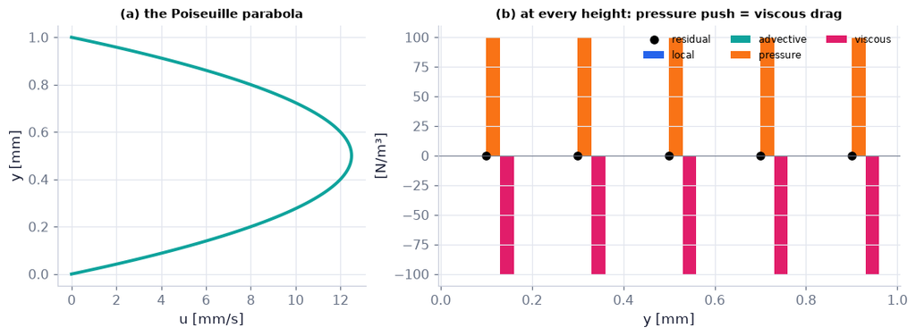

```python
yy = np.linspace(0, 1e-3, 101)                                       # across the gap [m]
fig, (a, b) = plt.subplots(1, 2, figsize=(10, 3.6), gridspec_kw=dict(width_ratios=[1, 1.5]))        # the figure and its panels
a.plot(ch04.plane_poiseuille(yy, G=100.0, h=1e-3, mu=1e-3)*1e3, yy*1e3, color=COLORS["teal"], lw=2.5)   # u(y) [mm/s]
a.set_xlabel("u [mm/s]"); a.set_ylabel("y [mm]"); a.set_title("(a) the Poiseuille parabola", fontsize=10)  # axis labels with units
ys = np.linspace(1e-4, 9e-4, 5)                                      # five heights [m]
res = [ch04.ns_terms_preset("poiseuille", 0.0, y, per="volume", G=100.0, h=1e-3, mu=1e-3) for y in ys]  # call the tested chapter function at each point
w = 0.03                                                              # bar width [mm]
for k, (name, col) in enumerate((("local", COLORS["blue"]), ("advective", COLORS["teal"]), ("pressure", COLORS["orange"]), ("viscous", COLORS["rose"]))):  # one bar per term, side by side
    b.bar(ys*1e3 + (k - 1.5)*w, [r_[name] for r_ in res], w, color=col, label=name)   # each term at each height
b.plot(ys*1e3, [r_["residual"] for r_ in res], "ko", label="residual")                              # draw the data
b.axhline(0, color=COLORS["muted"], lw=0.6); b.set_xlabel("y [mm]"); b.set_ylabel("[N/m³]"); b.legend(fontsize=8, ncol=3)  # axis labels with units
b.set_title("(b) at every height: pressure push = viscous drag", fontsize=10)                       # the panel's message
savefig(fig, "ch04", "poiseuille_terms"); plt.show()                                        # save the PNG to outputs/ch04, then draw
```

**What you see.** A parabola; at every height the same two equal and opposite bars (orange up, rose down) and zero-height blue and teal bars.

**How to read it.** In fully developed pipe/channel flow nothing accelerates: the pressure push is used up by friction at every point.

**What would change if…** …G doubled: both bars double and the parabola doubles (u ∝ G) — the balance is linear.

```python
yy = np.linspace(0, 10e-3, 150)                                      # height above the plate [m]
nu = 1e-6                                                            # water [m²/s]
def stokes(t):                                                       # Stokes' first problem at time t [s]
    u = ch04.stokes_first_problem(yy, t, U=1.0, nu=nu)               # u(y, t)/U = erfc(y/2√(νt))
    dt = 1e-3*t                                                      # a small time step for ∂u/∂t
    local = (ch04.stokes_first_problem(yy, t + dt, 1.0, nu) - ch04.stokes_first_problem(yy, t - dt, 1.0, nu)) / (2*dt)
    visc = nu*np.gradient(np.gradient(u, yy), yy)                   # ν ∂²u/∂y² on the grid
    scale = 1/np.max(np.abs(local))                                  # show both on the profile's scale
    return {"u(y, t)/U": (yy*1e3, u), "local ∂u/∂t (scaled)": (yy*1e3, local*scale),                # the curves for this slider value
            "viscous ν∂²u/∂y² (scaled)": (yy*1e3, visc*scale)}                                      # another named curve (x, y)
fig = slider_figure(stokes, "t", np.logspace(-2, 1, 20 if not FAST else 10), unit="s", xlabel="y [mm]", ylabel="[–]",  # precompute every slider position (works on the web page)
                    title="Momentum diffuses from the wall: the local term is paid by viscosity", yrange=(-0.05, 1.05))  # labels, title and a fixed range
recolor(fig, {"u(y, t)/U": COLORS["teal"], "local ∂u/∂t (scaled)": COLORS["blue"],                  # house colours for each trace, then draw
              "viscous ν∂²u/∂y² (scaled)": COLORS["rose"]}, {"viscous ν∂²u/∂y² (scaled)": "dash"}).show()  # colour of each named trace
```

[interactive chart not shown]

**What you see.** The teal profile thickens as t grows; the blue curve and the dashed rose curve lie on top of each other at every t.

**How to read it.** They balance: $\partial u/\partial t=\nu\,\partial^2u/\partial y^2$ is (4.39b), $\rho\frac{D\mathbf u}{Dt}=-\nabla p+\rho\mathbf g+\mu\nabla^2\mathbf u$ for this flow. The profile's thickness grows like $2\sqrt{\nu t}$: 2 mm after 1 s, 6.3 mm after 10 s.

**What would change if…** …oil (ν 100 × larger): the same shapes appear 100 × sooner — only the combination y/√(νt) matters (C15).

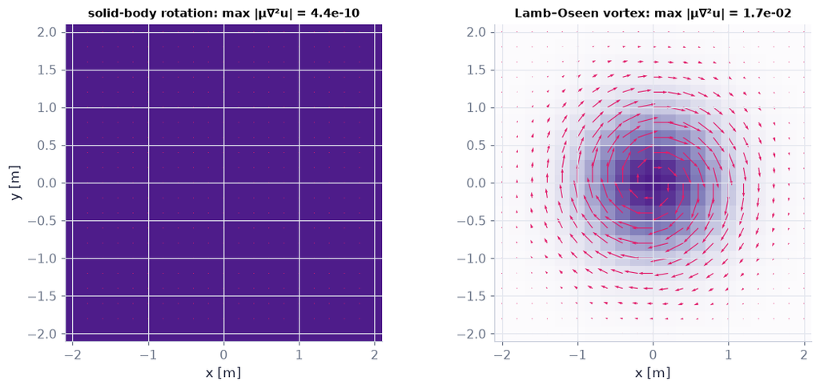

```
viscous force along e_θ [N/m³]: [-0.0077 -0.0156 -0.0147 -0.0063 -0.0015]
```

```python
n = 21 if not FAST else 15                                           # arrows per side
xs = np.linspace(-2, 2, n); Xg, Yg = np.meshgrid(xs, xs)             # a grid in the plane [m]
P = np.array([Xg.ravel(), Yg.ravel()])                               # points as a (2, N) array
Pz = np.vstack([P, 0*P[0]])                                          # the same points in 3-D (z = 0)
u_sb2, _ = ch04.exact_field("solid_body", Omega=1.0)                 # rigid rotation Ω = 1 rad/s
u_lo, _ = ch04.exact_field("lamb_oseen", Gamma=2*np.pi, nu=0.01, t0=25.0)   # Lamb–Oseen vortex, σ² = 4ν(t + t0) = 1 m²
fig, axs = plt.subplots(1, 2, figsize=(10, 4.4))                                        # the figure and its panels
for ax, uf, pts, lab in ((axs[0], u_sb2, Pz, "solid-body rotation"), (axs[1], u_lo, P, "Lamb–Oseen vortex")):  # the two vortices, one panel each
    w = kinematics.vorticity(uf, pts, 0.0)[2].reshape(Xg.shape)      # ω_z on the grid [1/s]
    lap, f2, f3 = ch04.viscous_force_forms(uf, pts, 0.0, mu=0.01)    # μ∇²u, 2μ ∂S_ij/∂x_i, −μ∇×ω (μ = ρν, ρ = 1) [N/m³]
    assert np.allclose(lap, f2, atol=1e-6) and np.allclose(lap, f3, atol=1e-6)   # D13: the three forms of (4.40) agree
    ax.pcolormesh(Xg, Yg, w, cmap="Purples", vmin=0, vmax=2.2, shading="auto")   # vorticity heat map
    ax.quiver(Xg, Yg, lap[0].reshape(Xg.shape), lap[1].reshape(Xg.shape), color=COLORS["rose"], scale=0.25)   # viscous force
    ax.set_aspect("equal"); ax.set_title(f"{lab}: max |μ∇²u| = {np.abs(lap).max():.1e}", fontsize=10); ax.set_xlabel("x [m]")  # axis labels with units
axs[0].set_ylabel("y [m]")                                        # axis labels with units
savefig(fig, "ch04", "viscous_paradox"); plt.show()                                        # save the PNG to outputs/ch04, then draw
r_ = np.array([0.2, 0.5, 1.0, 1.5, 2.0])                               # radii along the x-axis [m]
f_th = [ch04.viscous_force_forms(u_lo, np.array([r, 0.0]), 0.0, mu=0.01)[0][1] for r in r_]   # θ-component of μ∇²u at (r, 0)
print("viscous force along e_θ [N/m³]:", np.round(f_th, 5))            # all negative: against the counter-clockwise swirl
```

**What you see.** A uniform vorticity disc with no arrows; a peaked vorticity blob whose arrows all run clockwise, against the counter-clockwise swirl, largest near r ≈ σ = 1 m (the printed θ-components are all negative).

**How to read it.** Every arrow points against the swirl: viscosity slows the vortex at every radius, most strongly near r ≈ σ, while its vorticity spreads outward (ω rises outside the core as σ² = 4ν(t + t₀) grows — Ch. 5). A rigid rotation, whose vorticity is uniform, feels nothing: $\mu\nabla^2\mathbf u=-\mu\nabla\times\boldsymbol\omega$ = 0 there.

**What would change if…** …ν doubled: the arrows double and the core spreads twice as fast (σ² = 4νt).

#### 🎮 Interactive: Which terms of Navier–Stokes are awake here?

**Why interactive rather than a static figure:** each exact solution balances different terms at different points and times; clicking points and scrubbing time lets you find the regions where each term wakes up, instead of reading one pre-chosen probe.

Pick an exact solution — Couette, Poiseuille, Stokes' first problem, Taylor–Green (a decaying array of vortices), Lamb–Oseen or the potential flow round a cylinder — click any point and read the five terms of $\rho\frac{D\mathbf u}{Dt}=-\nabla p+\rho\mathbf g+\mu\nabla^2\mathbf u$ (4.39b) as bars that add to zero; scrub time for the unsteady ones and watch the balance move. Its Explain tab also computes a local Reynolds number, speed × length/ν (C15 treats it properly).

**What to try:**

- Poiseuille: click anywhere — only orange and rose, equal and opposite.
- Stokes' first problem: press ▶ and watch the blue (local) bar trade with the rose (viscous) bar.
- Cylinder (Euler): the viscous bar is exactly zero although μ ≠ 0 — why? (Explain, section 5).
- Open the third view: the viscous force computed three ways of (4.40), $\mu\nabla^2\mathbf u=2\mu\partial S_{ij}/\partial x_i=-\mu\nabla\times\boldsymbol\omega$, gives the same arrow.

```python
show_viz("ch04", "navier_stokes_term_balance")   # full-width explainer; ⤢ Full screen for more room
```

🎮 Interactive 4/9 Which terms of Navier–Stokes are awake here? Open alone ↗

[interactive chart not shown]

**What would change if…** …the observer were on a turntable, or on the rotating Earth? Newton's law holds only in an inertial frame; in a rotating one extra "apparent" forces appear — Coriolis and centrifugal (C09). For the atmosphere and ocean they are not small.

## 4.7 Noninertial Frame of Reference

**What is this section about?** The equations so far hold for an observer who is not accelerating. We rewrite Navier–Stokes for an observer who accelerates and rotates — the frame every geophysical flow is described in — and meet the Coriolis and centrifugal terms.

### 🧩 Seen from a rotating frame: Coriolis and centrifugal forces (4.45) `C09`

*The question:* Roll a ball straight across a spinning merry-go-round. Someone standing on the ground sees a straight line; the rider sees it curve. Who is right — and what force does the rider need to invent?

*In one line:* $\rho\frac{D'\mathbf u'}{Dt}=-\nabla'p+\rho\Big[\mathbf g-\frac{d\mathbf U}{dt}-2\boldsymbol\Omega\times\mathbf u'-\frac{d\boldsymbol\Omega}{dt}\times\mathbf x'-\boldsymbol\Omega\times(\boldsymbol\Omega\times\mathbf x')\Big]+\mu\nabla'^2\mathbf u'$ *(4.45)*

#### The problem in plain words

We live on a rotating planet and measure winds and currents relative to the ground. For a thrown ball the rotation hardly matters; for a hurricane or an ocean gyre that lasts days it dominates. Turbomachines and centrifuges are also analysed in frames that turn with them. We need Navier–Stokes as seen by an observer who translates with acceleration dU/dt and rotates at Ω(t).

#### The idea

```
inertial observer:  a = F/m                       rotating observer: a' = F/m + (apparent forces)
the rotating axes e'_i turn:  de'_i/dt = Ω × e'_i   →  velocity gains Ω × x'      (4.42)
differentiate again           →  a = dU/dt + a' + 2Ω×u' + dΩ/dt×x' + Ω×(Ω×x')      (4.43)
                                    frame   rel.  Coriolis angular  centripetal
move them to the force side   →  −dU/dt, −2Ω×u' (amber), −dΩ/dt×x', −Ω×(Ω×x') (purple)   in (4.45)
```

*The numbered equations in the sketch:* $\mathbf u=\mathbf U+\mathbf u'+\boldsymbol\Omega\times\mathbf x'$ *(4.42)* · $\mathbf a=\frac{d\mathbf U}{dt}+\mathbf a'+2\boldsymbol\Omega\times\mathbf u'+\frac{d\boldsymbol\Omega}{dt}\times\mathbf x'+\boldsymbol\Omega\times(\boldsymbol\Omega\times\mathbf x')$ *(4.43)* · $\rho\frac{D'\mathbf u'}{Dt}=-\nabla'p+\rho\Big[\mathbf g-\frac{d\mathbf U}{dt}-2\boldsymbol\Omega\times\mathbf u'-\frac{d\boldsymbol\Omega}{dt}\times\mathbf x'-\boldsymbol\Omega\times(\boldsymbol\Omega\times\mathbf x')\Big]+\mu\nabla'^2\mathbf u'$ *(4.45)*

📝 **Note.** **An inertial frame** `N56` — is one in which Newton's law holds as written — fixed to the distant stars, or moving at constant velocity relative to them. A laboratory on the Earth is nearly inertial over seconds and metres; over hours and hundreds of kilometres it is not (Ch. 13).

> ⚠️ **The prime changes meaning again.** In this section $\mathbf x'$, $\mathbf u'$, $\mathbf a'$ and $D'/Dt$ are measured in the **rotating** frame O′1′2′3′ (Ch. 3's primes were a translating frame; §4.9's p′, ρ′ will be perturbations).

> 🔁 **Tools from earlier chapters used here** (see `knowledge/primers.md`)
- **frames of reference and relative velocity** — velocities add between frames: $\mathbf u=\mathbf U+\mathbf u'$ for a frame moving at $\mathbf U$ (Ch. 3 P96).
- **rotating frame of reference (first look)** — a rotating observer measures the vorticity $\omega'=\omega-2\Omega$ (Ch. 3 P103).
- **product rule** — $d(fg)=f\,dg+g\,df$ (Ch. 1 P38).

> 📎 **Primer — derivative of a rotating unit vector.** `P124` · A unit vector e′ fixed to a frame turning at angular velocity Ω keeps its length but changes direction: its tip moves on a circle round the Ω axis. In time dt it moves a distance (sin α)|Ω| dt (α the angle between e′ and Ω), perpendicular to both — exactly the cross product: $d\mathbf e'/dt=\boldsymbol\Omega\times\mathbf e'$. Here it is why a rotating observer's axes add terms to every time derivative. (`ch04.rotating_basis` turns the three axes with Rodrigues' rotation formula, the rotation of Ch. 2 §2.2 about an arbitrary axis.)

```python
Om = np.array([0.0, 0.0, 0.5])                                # 0.5 rad/s about z
E = ch04.rotating_basis(Om, 1.0); dE = ch04.basis_rate(Om, 1.0)   # rows e'_i(t) and d e'_i/dt (central difference)
print(np.allclose(dE, np.cross(Om, E)))                       # True: de'/dt = Ω × e'
```

```
True
```

> 📎 **Primer — product rule for a cross product.** `P125` · $\frac{d}{dt}(\mathbf a\times\mathbf b)=\dot{\mathbf a}\times\mathbf b+\mathbf a\times\dot{\mathbf b}$ — like the ordinary product rule, but the order of the factors must be kept (a × b = −b × a).

```python
t = sp.symbols('t')                                              # time
a = sp.Matrix([sp.cos(t), t, 1]); b = sp.Matrix([t**2, 0, sp.sin(t)])   # two moving vectors
print(sp.simplify(a.cross(b).diff(t) - (a.diff(t).cross(b) + a.cross(b.diff(t)))))   # zero vector
```

```
Matrix([[0], [0], [0]])
```

#### 🧮 Derivation — Velocity in a translating–rotating frame, (4.42) `D14` (Eq. 4.42)

**What we want to show.** Relate the velocity a rotating observer measures to the true (inertial) velocity, and find how the rotating axes themselves change in time.

**Assumptions.** The rotating frame is rigid: its axes turn together at Ω(t) (step 3).

**The plan.**

1. Write x′ with the rotating basis.
2. Find de′_i/dt from the cone construction.
3. Differentiate with the product rule and name the pieces.

**Tools we use** (each explained before this point): Derivative of a rotating unit vector (primer in C09) · product rule (ch01 P38) · cross product and right-hand rule (ch02 P74).

**We start from**

$$ \mathbf x=\mathbf X(t)+\mathbf x' $$

*In words:* the particle's position = position of the moving origin O′ + its position relative to O′ (Fig. 4.6).

**Step 1 of 7 — Split the position.**

$$ \mathbf x=\mathbf X(t)+\mathbf x' $$

- *Why we can do this:* Vector addition (Fig. 4.6): O′ is at X(t); the particle is at x′ from O′.
- *In words:* Where the particle is = where the frame is + where it is in the frame.

**Step 2 of 7 — Write x′ in the rotating basis.**

$$ \mathbf x'=x'_i\,\mathbf e'_i(t) $$

- *Why we can do this:* The rotating observer measures components x′_i along its own axes e′_i — and those axes turn, so they are functions of time. This is the whole difference from Ch. 3's Galilean frame.
- *In words:* The components and the axes both change.

**Step 3 of 7 — Size of a basis vector's change.**

$$ \Big\lvert\frac{d\mathbf e'_1}{dt}\Big\rvert=\sin\alpha\,\lvert\boldsymbol\Omega\rvert $$

- *Why we can do this:* The cone construction (primer, Fig. 4.7): e′₁'s tip moves on a circle of radius sin α round the Ω axis at angular speed |Ω|.
- *In words:* A unit vector sweeps a cone.

**Step 4 of 7 — Identify its direction.**

$$ \frac{d\mathbf e'_i}{dt}=\boldsymbol\Omega\times\mathbf e'_i $$

- *Why we can do this:* The change is perpendicular to both Ω and e′₁ with size sin α|Ω| — exactly the cross product (right-hand rule); the same for every axis.
- *In words:* Turning axes change at Ω × axis.

**Step 5 of 7 — Differentiate the position.**

$$ \mathbf u=\frac{d\mathbf X}{dt}+\frac{dx'_i}{dt}\mathbf e'_i+x'_i\frac{d\mathbf e'_i}{dt} $$

- *Why we can do this:* Product rule on each term x′_ie′_i (both factors depend on t).
- *In words:* Three contributions to the true velocity.

**Step 6 of 7 — Name the first two pieces.**

$$ \frac{d\mathbf X}{dt}=\mathbf U,\qquad\frac{dx'_i}{dt}\mathbf e'_i=\mathbf u' $$

- *Why we can do this:* U is the frame's velocity; u′ is what the rotating observer measures — the rates of change of its own components.
- *In words:* Frame velocity and velocity seen in the frame.

**Step 7 of 7 — Use the turning rule.**

$$ \mathbf u=\mathbf U+\mathbf u'+\boldsymbol\Omega\times\mathbf x' $$

- *Why we can do this:* x′_i(Ω × e′_i) = Ω × (x′_ie′_i) = Ω × x′ (linearity of ×). This is (4.42), $\mathbf u=\mathbf U+\mathbf u'+\boldsymbol\Omega\times\mathbf x'$ — the line above.
- *In words:* True velocity = frame velocity + measured velocity + the frame's rotation carrying the particle.

**Result**

$$ \mathbf u=\mathbf U+\mathbf u'+\boldsymbol\Omega\times\mathbf x'\ \text{with}\ \frac{d\mathbf e'_i}{dt}=\boldsymbol\Omega\times\mathbf e'_i $$

*In words:* a rotating observer misses the part Ω × x′ of the velocity.

**What it means.** The rotating observer's velocity differs from the true one by a solid-body rotation — why the vorticity seen from the Earth, ζ (the relative vorticity, Ch. 13), differs from the absolute vorticity ζ + f, f = 2Ω sin φ being the Coriolis parameter primed later in this block (P126) (Ch. 3's ω′ = ω − 2Ω, Ch. 13).

**Check it.** Units m/s ✓. Ω = 0: Galilean u = U + u′ (Ch. 3) ✓. A particle at rest on the turntable (u′ = 0) moves at Ω × x′ in the inertial frame ✓. `basis_rate` equals Ω × e′ numerically (primer code) ✓.

> ⚠️ **Common confusion (traps in `D14`):** Treating e′_i as constant (that is the Galilean case). Using the inertial position in Ω × x′. Thinking u′ is the true velocity "in rotating components" (it is a different vector).

📝 **Note.** **Velocity seen from the inertial frame** `N57` — (D14's result). u′ is how fast the *components* x′_i change — what the rotating observer measures.

$$ \mathbf u=\mathbf U+\mathbf u'+\boldsymbol\Omega\times\mathbf x',\qquad\frac{d\mathbf e'_i}{dt}=\boldsymbol\Omega\times\mathbf e'_i \qquad \text{(4.42)} $$

#### 🧮 Derivation — Acceleration in a noninertial frame: (4.42) → (4.43) → (4.44) `D15` (Eq. 4.43)

**What we want to show.** Differentiate (4.42), $\mathbf u=\mathbf U+\mathbf u'+\boldsymbol\Omega\times\mathbf x'$ once more to find the true acceleration in terms of what the rotating observer measures — and see where the famous factor 2 of the Coriolis term comes from. The book states the result (Exercise 4.42).

**Assumptions.** U and Ω depend on time only (uniform in space); the frame is rigid.

**The plan.**

1. Differentiate term by term.
2. The u′ term: product rule on its rotating basis — one Ω × u′.
3. The Ω × x′ term: product rule for a cross product, and D14 for dx′/dt — a second Ω × u′ and the centripetal term.
4. Collect, then follow a fluid particle.

**Tools we use** (each explained before this point): D14 (the turning rule) · product rule for a cross product (primer in C09) · vector triple product (gloss, Ch. 2 §2.7) · material derivative in each frame.

**We start from**

$$ \text{(4.42):}\ \mathbf u=\mathbf U+\mathbf u'+\boldsymbol\Omega\times\mathbf x' $$

*In words:* the true velocity from D14.

**Step 1 of 12 — Start from the velocity.**

$$ \mathbf u=\mathbf U+\mathbf u'+\boldsymbol\Omega\times\mathbf x' $$

- *Why we can do this:* (4.42), $\mathbf u=\mathbf U+\mathbf u'+\boldsymbol\Omega\times\mathbf x'$, D14's result; the true acceleration is its time derivative.
- *In words:* The velocity in three pieces.

**Step 2 of 12 — Differentiate term by term.**

$$ \mathbf a=\frac{d\mathbf U}{dt}+\frac{d\mathbf u'}{dt}+\frac{d}{dt}\big(\boldsymbol\Omega\times\mathbf x'\big) $$

- *Why we can do this:* The derivative of a sum is the sum of the derivatives.
- *In words:* Three accelerations to work out.

**Step 3 of 12 — Write u′ in the rotating basis.**

$$ \mathbf u'=u'_i\,\mathbf e'_i,\qquad u'_i=\frac{dx'_i}{dt} $$

- *Why we can do this:* u′ is built from the rotating observer's component rates (D14 step 6), attached to the turning axes.
- *In words:* The measured velocity also sits on turning axes.

**Step 4 of 12 — Differentiate u′ by the product rule.**

$$ \frac{d\mathbf u'}{dt}=\frac{du'_i}{dt}\mathbf e'_i+u'_i\frac{d\mathbf e'_i}{dt} $$

- *Why we can do this:* Both the components and the axes depend on time (product rule).
- *In words:* The measured velocity changes, and its axes turn.

**Step 5 of 12 — Name the measured acceleration.**

$$ \frac{du'_i}{dt}\mathbf e'_i=\mathbf a' $$

- *Why we can do this:* This is what the rotating observer calls acceleration: the rates of its own velocity components.
- *In words:* The acceleration seen in the frame.

**Step 6 of 12 — Turn the axes: first Ω × u′.**

$$ u'_i\frac{d\mathbf e'_i}{dt}=u'_i\,\boldsymbol\Omega\times\mathbf e'_i=\boldsymbol\Omega\times\mathbf u' $$

- *Why we can do this:* D14's turning rule de′_i/dt = Ω × e′_i, then linearity of ×.
- *In words:* The turning axes contribute one Ω × u′.

**Step 7 of 12 — Differentiate Ω × x′.**

$$ \frac{d}{dt}\big(\boldsymbol\Omega\times\mathbf x'\big)=\frac{d\boldsymbol\Omega}{dt}\times\mathbf x'+\boldsymbol\Omega\times\frac{d\mathbf x'}{dt} $$

- *Why we can do this:* Product rule for a cross product (primer), keeping the order of the factors.
- *In words:* The rotation rate may change, and the position moves.

**Step 8 of 12 — Differentiate x′ with D14.**

$$ \frac{d\mathbf x'}{dt}=\mathbf u'+\boldsymbol\Omega\times\mathbf x' $$

- *Why we can do this:* D14 steps 5–7 applied to x′ = x′_ie′_i alone (no U): component rates plus the turning axes.
- *In words:* The relative position changes by the measured velocity plus the rotation.

**Step 9 of 12 — Substitute: second Ω × u′.**

$$ \boldsymbol\Omega\times\frac{d\mathbf x'}{dt}=\boldsymbol\Omega\times\mathbf u'+\boldsymbol\Omega\times(\boldsymbol\Omega\times\mathbf x') $$

- *Why we can do this:* Distributivity of the cross product over a sum.
- *In words:* The moving position contributes another Ω × u′.

**Step 10 of 12 — Expand the triple product.**

$$ \boldsymbol\Omega\times(\boldsymbol\Omega\times\mathbf x')=\boldsymbol\Omega(\boldsymbol\Omega\cdot\mathbf x')-\Omega^2\mathbf x' $$

- *Why we can do this:* a × (b × c) = b(a·c) − c(a·b) (Ch. 2); for Ω along z it is −Ω²R e_R, pointing to the axis: centripetal.
- *In words:* This term pulls toward the axis.

**Step 11 of 12 — Collect the two Ω × u′.**

$$ \mathbf a=\frac{d\mathbf U}{dt}+\mathbf a'+2\boldsymbol\Omega\times\mathbf u'+\frac{d\boldsymbol\Omega}{dt}\times\mathbf x'+\boldsymbol\Omega\times(\boldsymbol\Omega\times\mathbf x') $$

- *Why we can do this:* Add steps 5, 6, 7 and 9: one Ω × u′ from each source gives the factor 2. This is (4.43), $\mathbf a=\frac{d\mathbf U}{dt}+\mathbf a'+2\boldsymbol\Omega\times\mathbf u'+\frac{d\boldsymbol\Omega}{dt}\times\mathbf x'+\boldsymbol\Omega\times(\boldsymbol\Omega\times\mathbf x')$ — the line above.
- *In words:* Frame, measured, Coriolis, angular and centripetal accelerations.

**Step 12 of 12 — Follow a fluid particle.**

$$ \Big(\frac{D\mathbf u}{Dt}\Big)_{O123}=\Big(\frac{D'\mathbf u'}{Dt}\Big)_{O'1'2'3'}+\frac{d\mathbf U}{dt}+2\boldsymbol\Omega\times\mathbf u'+\frac{d\boldsymbol\Omega}{dt}\times\mathbf x'+\boldsymbol\Omega\times(\boldsymbol\Omega\times\mathbf x') $$

- *Why we can do this:* For a fluid particle the acceleration is the material derivative: a = Du/Dt in the inertial frame, a′ = D′u′/Dt in the rotating one. This is (4.44), $\frac{D\mathbf u}{Dt}=\frac{D'\mathbf u'}{Dt}+\frac{d\mathbf U}{dt}+2\boldsymbol\Omega\times\mathbf u'+\frac{d\boldsymbol\Omega}{dt}\times\mathbf x'+\boldsymbol\Omega\times(\boldsymbol\Omega\times\mathbf x')$ — the line above.
- *In words:* The same bookkeeping, for fluid particles.

**Result**

$$ \begin{array}{l}(4.43)\quad \mathbf a=\frac{d\mathbf U}{dt}+\mathbf a'+2\boldsymbol\Omega\times\mathbf u'+\frac{d\boldsymbol\Omega}{dt}\times\mathbf x'+\boldsymbol\Omega\times(\boldsymbol\Omega\times\mathbf x') \\ (4.44)\quad \frac{D\mathbf u}{Dt}=\frac{D'\mathbf u'}{Dt}+\frac{d\mathbf U}{dt}+2\boldsymbol\Omega\times\mathbf u'+\frac{d\boldsymbol\Omega}{dt}\times\mathbf x'+\boldsymbol\Omega\times(\boldsymbol\Omega\times\mathbf x')\end{array} $$

*In words:* the true acceleration = what the rotating observer sees + frame acceleration + Coriolis + angular + centripetal terms.

**What it means.** The Coriolis term's 2 is not a convention: half comes from the turning axes, half from the moving position. Moved to the force side (D16) these terms are the apparent forces of every geophysical flow.

**Check it.** Units m/s² ✓. Ω = 0, U̇ = 0: a = a′ (Galilean) ✓. A particle at rest on a steady turntable: a = Ω × (Ω × x′), the centripetal acceleration ✓. **sympy check (the cell below, every line commented):** rotation about z by θ(t) (Ω = θ̇e_z, Ω̇ = θ̈e_z) as a sympy matrix R(t); generic functions X_i(t), x′_i(t); build x = X + R x′ (step 1 of D14); differentiate twice; rotate back into primed components (Rᵀẍ); subtract the five terms of (4.43), $\mathbf a=\frac{d\mathbf U}{dt}+\mathbf a'+2\boldsymbol\Omega\times\mathbf u'+\frac{d\boldsymbol\Omega}{dt}\times\mathbf x'+\boldsymbol\Omega\times(\boldsymbol\Omega\times\mathbf x')$ written in primed components (Ẍ rotated, ẍ′, 2Ω × ẋ′, Ω̇ × x′, Ω × (Ω × x′)); `simplify` each component → 0. A second line replaces the 2 by 1 and shows the difference is Ω × ẋ′ ≠ 0 — the factor 2 is necessary.

```python
t = sp.symbols('t', real=True)                                     # time
th = sp.Function('theta')(t)                                       # rotation angle about z: Ω = θ̇ e_z, dΩ/dt = θ̈ e_z
R = sp.Matrix([[sp.cos(th), -sp.sin(th), 0], [sp.sin(th), sp.cos(th), 0], [0, 0, 1]])   # columns = the rotating axes e'_i(t)
X = sp.Matrix([sp.Function(f'X{i}')(t) for i in (1, 2, 3)])        # position of the moving origin O' (inertial components)
xp = sp.Matrix([sp.Function(f'xp{i}')(t) for i in (1, 2, 3)])      # the particle's components x'_i in the rotating frame
x = X + R*xp                                                        # D14 step 1–2: x = X + x'_i e'_i
a_inertial = x.diff(t, 2)                                          # the true acceleration, differentiated twice
a_in_primed = sp.simplify(R.T*a_inertial)                          # the same vector written in rotating components
Om = sp.Matrix([0, 0, th.diff(t)]); Omdot = Om.diff(t)             # Ω and dΩ/dt (the axis z is shared by both frames)
up, ap = xp.diff(t), xp.diff(t, 2)                                 # u' = dx'_i/dt, a' = d²x'_i/dt² (what the rider measures)
rhs = R.T*X.diff(t, 2) + ap + 2*Om.cross(up) + Omdot.cross(xp) + Om.cross(Om.cross(xp))   # the five terms of (4.43)
print([sp.simplify(e) for e in (a_in_primed - rhs)])               # [0, 0, 0]: (4.43) holds exactly
one = rhs - Om.cross(up)                                           # the same with 1 × Ω × u' instead of 2 ×
print([sp.simplify(e) for e in (a_in_primed - one)])               # = Ω × u' ≠ 0: the factor 2 is necessary
assert all(sp.simplify(e) == 0 for e in (a_in_primed - rhs))
```

```
[0, 0, 0]
[-Derivative(theta(t), t)*Derivative(xp2(t), t), Derivative(theta(t), t)*Derivative(xp1(t), t), 0]
```

> ⚠️ **Common confusion (traps in `D15`):** Forgetting the second Ω × u′ (a factor-of-2 error). Differentiating x′ as if the axes were fixed. Sign language: +2Ω × u′ here is an acceleration term; the force per mass −2Ω × u′ appears in (4.45), $\rho\frac{D'\mathbf u'}{Dt}=-\nabla'p+\rho\Big[\mathbf g-\frac{d\mathbf U}{dt}-2\boldsymbol\Omega\times\mathbf u'-\frac{d\boldsymbol\Omega}{dt}\times\mathbf x'-\boldsymbol\Omega\times(\boldsymbol\Omega\times\mathbf x')\Big]+\mu\nabla'^2\mathbf u'$.

📝 **Note.** **Acceleration in the inertial frame, term by term** `N58` — Names: frame acceleration, acceleration seen in the rotating frame, **Coriolis** term, angular-acceleration term, **centripetal** term. The factor 2: one Ω × u′ comes from the turning axes (differentiating u′'s basis), one from the moving position (differentiating Ω × x′).

$$ \mathbf a=\frac{d\mathbf U}{dt}+\mathbf a'+2\boldsymbol\Omega\times\mathbf u'+\frac{d\boldsymbol\Omega}{dt}\times\mathbf x'+\boldsymbol\Omega\times(\boldsymbol\Omega\times\mathbf x') \qquad \text{(4.43)} $$

📝 **Note.** **For a fluid particle** `N59` — a = Du/Dt in the inertial frame and a′ = D′u′/Dt in the rotating one:

$$ \Big(\frac{D\mathbf u}{Dt}\Big)_{O123}=\Big(\frac{D'\mathbf u'}{Dt}\Big)_{O'1'2'3'}+\frac{d\mathbf U}{dt}+2\boldsymbol\Omega\times\mathbf u'+\frac{d\boldsymbol\Omega}{dt}\times\mathbf x'+\boldsymbol\Omega\times(\boldsymbol\Omega\times\mathbf x') \qquad \text{(4.44)} $$

#### 🧮 Derivation — Navier–Stokes in a noninertial frame: (4.44) + (4.39b) → (4.45) `D16` (Eq. 4.45)

**What we want to show.** Rewrite the incompressible Navier–Stokes equation for an observer who translates with acceleration and rotates.

**Assumptions.** Incompressible, constant μ (the starting equation); U and Ω uniform in space (step 4).

**The plan.**

1. Replace the acceleration by (4.44), $\frac{D\mathbf u}{Dt}=\frac{D'\mathbf u'}{Dt}+\frac{d\mathbf U}{dt}+2\boldsymbol\Omega\times\mathbf u'+\frac{d\boldsymbol\Omega}{dt}\times\mathbf x'+\boldsymbol\Omega\times(\boldsymbol\Omega\times\mathbf x')$.
2. Show the pressure gradient and viscous term are unchanged.
3. Move the frame terms to the force side.

**Tools we use** (each explained before this point): (4.44), $\frac{D\mathbf u}{Dt}=\frac{D'\mathbf u'}{Dt}+\frac{d\mathbf U}{dt}+2\boldsymbol\Omega\times\mathbf u'+\frac{d\boldsymbol\Omega}{dt}\times\mathbf x'+\boldsymbol\Omega\times(\boldsymbol\Omega\times\mathbf x')$ (D15) · vector Laplacian (gloss) · the gradient of a scalar is the same arrow in every frame at the coincidence instant (gloss).

**We start from**

$$ \text{(4.39b) in the inertial frame:}\ \rho\frac{D\mathbf u}{Dt}=-\nabla p+\rho\mathbf g+\mu\nabla^2\mathbf u\ \text{.} $$

**Step 1 of 6 — Start from inertial Navier–Stokes.**

$$ \rho\frac{D\mathbf u}{Dt}=-\nabla p+\rho\mathbf g+\mu\nabla^2\mathbf u $$

- *Why we can do this:* (4.39b), $\rho\frac{D\mathbf u}{Dt}=-\nabla p+\rho\mathbf g+\mu\nabla^2\mathbf u$ holds only in an inertial frame; the book says "(4.39), $\rho\frac{D\mathbf u}{Dt}=-\nabla p+\rho\mathbf g+\mu\nabla^2\mathbf u$" but needs the incompressible, constant-μ form.
- *In words:* Newton's law in the lab.

**Step 2 of 6 — Replace the acceleration by (4.44).**

$$ \rho\Big[\frac{D'\mathbf u'}{Dt}+\frac{d\mathbf U}{dt}+2\boldsymbol\Omega\times\mathbf u'+\frac{d\boldsymbol\Omega}{dt}\times\mathbf x'+\boldsymbol\Omega\times(\boldsymbol\Omega\times\mathbf x')\Big]=\ldots $$

- *Why we can do this:* D15: the inertial acceleration in terms of rotating-frame quantities.
- *In words:* The lab acceleration, written with the rider's measurements.

**Step 3 of 6 — Keep the pressure gradient.**

$$ \nabla p=\nabla'p $$

- *Why we can do this:* Pressure is a scalar; its gradient is one arrow, only described in different components in the two frames at the same instant (gloss).
- *In words:* Pressure pushes the same way for both observers.

**Step 4 of 6 — Keep the viscous term.**

$$ \nabla^2\mathbf u=\nabla'^2\mathbf u' $$

- *Why we can do this:* U + Ω × x′ is linear in x′ (U, Ω uniform in space), so its second derivatives vanish; ∇² is the same for any orientation of the axes.
- *In words:* A rigid motion adds no friction.

**Step 5 of 6 — Move the frame terms to the right.**

$$ \rho\frac{D'\mathbf u'}{Dt}=-\nabla'p+\rho\mathbf g-\rho\frac{d\mathbf U}{dt}-2\rho\boldsymbol\Omega\times\mathbf u'-\rho\frac{d\boldsymbol\Omega}{dt}\times\mathbf x'-\rho\boldsymbol\Omega\times(\boldsymbol\Omega\times\mathbf x')+\mu\nabla'^2\mathbf u' $$

- *Why we can do this:* Subtract them from both sides; every sign flips. They are now apparent (fictitious) body forces.
- *In words:* The rider's accelerations become the rider's forces.

**Step 6 of 6 — Group the body forces.**

$$ \rho\frac{D'\mathbf u'}{Dt}=-\nabla'p+\rho\Big[\mathbf g-\frac{d\mathbf U}{dt}-2\boldsymbol\Omega\times\mathbf u'-\frac{d\boldsymbol\Omega}{dt}\times\mathbf x'-\boldsymbol\Omega\times(\boldsymbol\Omega\times\mathbf x')\Big]+\mu\nabla'^2\mathbf u' $$

- *Why we can do this:* All are per-unit-mass accelerations multiplied by ρ, like gravity. This is (4.45), $\rho\frac{D'\mathbf u'}{Dt}=-\nabla'p+\rho\Big[\mathbf g-\frac{d\mathbf U}{dt}-2\boldsymbol\Omega\times\mathbf u'-\frac{d\boldsymbol\Omega}{dt}\times\mathbf x'-\boldsymbol\Omega\times(\boldsymbol\Omega\times\mathbf x')\Big]+\mu\nabla'^2\mathbf u'$ — the line above.
- *In words:* In a rotating frame, gravity is joined by four apparent forces.

**Result**

$$ (4.45)\quad \rho\frac{D'\mathbf u'}{Dt}=-\nabla'p+\rho\Big[\mathbf g-\frac{d\mathbf U}{dt}-2\boldsymbol\Omega\times\mathbf u'-\frac{d\boldsymbol\Omega}{dt}\times\mathbf x'-\boldsymbol\Omega\times(\boldsymbol\Omega\times\mathbf x')\Big]+\mu\nabla'^2\mathbf u' $$

*In words:* the rotating observer uses Navier–Stokes with extra body forces: frame acceleration, Coriolis, angular acceleration, centrifugal.

**What it means.** The starting point of Ch. 13: on the Earth −2Ω × u′ turns winds and currents, −Ω × (Ω × x′) is absorbed into gravity, and the other two vanish.

**Check it.** Units ✓. Inertial frame (U constant, Ω = 0): the bracket is g alone ✓. dU/dt = g: g − dU/dt = 0, weightlessness (N60) ✓. Continuity is unchanged (∇·u = ∇′·u′ since ∇·(Ω × x′) = 0).

> ⚠️ **Common confusion (traps in `D16`):** Forgetting that moving the terms flips their signs (Coriolis force −2Ω × u′, centrifugal −Ω × (Ω × x′)). Using (4.45), $\rho\frac{D'\mathbf u'}{Dt}=-\nabla'p+\rho\Big[\mathbf g-\frac{d\mathbf U}{dt}-2\boldsymbol\Omega\times\mathbf u'-\frac{d\boldsymbol\Omega}{dt}\times\mathbf x'-\boldsymbol\Omega\times(\boldsymbol\Omega\times\mathbf x')\Big]+\mu\nabla'^2\mathbf u'$ with space-dependent Ω. Treating the apparent forces as real interactions (they do no work — Coriolis — or are potential forces — centrifugal).

> ⚠️ **Coriolis *term* vs Coriolis *force*.** On the acceleration side, $\mathbf a=\frac{d\mathbf U}{dt}+\mathbf a'+2\boldsymbol\Omega\times\mathbf u'+\dots$ *(4.43)* has **+2Ω × u′**; moved to the force side, (4.45), $\rho\frac{D'\mathbf u'}{Dt}=-\nabla'p+\rho\Big[\mathbf g-\frac{d\mathbf U}{dt}-2\boldsymbol\Omega\times\mathbf u'-\frac{d\boldsymbol\Omega}{dt}\times\mathbf x'-\boldsymbol\Omega\times(\boldsymbol\Omega\times\mathbf x')\Big]+\mu\nabla'^2\mathbf u'$ has **−2Ω × u′** per unit mass. The book calls both "Coriolis acceleration". We say *Coriolis term* for the first and *Coriolis force per unit mass* for the second; the second is the one that deflects a moving parcel to the **right** in the Northern Hemisphere (Ω up). Likewise Ω × (Ω × x′) is *centripetal* (points to the axis) and −Ω × (Ω × x′) *centrifugal* (away from it). In code: `frame_acceleration_terms` returns the + terms, `apparent_body_forces` the − terms.

📝 **Note.** **Frame acceleration −dU/dt** `N60` — the push back into your seat when a car accelerates. An aircraft on a parabolic arc has dU/dt = g, so g − dU/dt = 0: weightlessness (the cell prints the total apparent body force: zero).

```python
print(ch04.apparent_body_forces(np.zeros(3), np.zeros(3), np.zeros(3), dU_dt=np.array([0, 0, -9.81]))["total"])   # [0 0 0]: weightless
```

```
[0. 0. 0.]
```

> 📎 **Primer — latitude, Earth's rotation rate and the local vertical.** `P126` · The Earth turns once per sidereal day (86 164 s), Ω = 2π/86164 = 7.292×10⁻⁵ rad/s, about the axis through the poles. At latitude φ the local vertical makes an angle with that axis, so Ω splits into a vertical part Ω sin φ (full at the poles, zero at the equator) and a horizontal part Ω cos φ along the meridian. For horizontal winds the vertical part does the steering — twice it, f = 2Ω sin φ, is the *Coriolis parameter* of Ch. 13 (named here only).

```python
Om = 2*np.pi/86164.0                                           # Earth's rotation rate [rad/s]
for lat in (0, 30, 45, 90):                                    # latitude [°]
    print(lat, round(Om*np.sin(np.deg2rad(lat)), 9), round(ch04.coriolis_parameter(np.deg2rad(lat)), 9))   # Ω sin φ, f = 2Ω sin φ [1/s]
```

```
0 0.0 0.0
30 3.6461e-05 7.2921e-05
45 5.1563e-05 0.000103126
90 7.2921e-05 0.000145842
```

> 🔁 **Tools from earlier chapters used here** (see `knowledge/primers.md`)
- **small-angle approximation** — $\sin x\approx x$ for |x| ≪ 1 rad (Ch. 3 P100).

#### 🧮 Derivation — The Coriolis deflection of a projectile from the pole: Ωut², angle Ωt `D17`

**What we want to show.** Show where the book's "deflection Ωut²" comes from (it asserts it), and why the angle equals the Earth's rotation.

**Assumptions.** At the pole (Ω vertical), horizontal launch, no friction, centrifugal effect neglected (second order); small Ωt, so the path direction barely changes (step 2).

**The plan.**

1. Evaluate it for horizontal motion at the pole.
2. Treat it as a constant sideways acceleration for a short time.
3. Integrate twice and compare with the Earth's turn.

**Tools we use** (each explained before this point): Cross product and right-hand rule (ch02 P74) · constant-acceleration kinematics s = ½at² (gloss).

**We start from**

$$ \text{The Coriolis force per unit mass of (4.45):}\ -2\boldsymbol\Omega\times\mathbf u'\ \text{.} $$

**Step 1 of 5 — Evaluate the Coriolis force at the pole.**

$$ -2\boldsymbol\Omega\times\mathbf u'=-2\Omega u\,\mathbf e_z\times\mathbf e_x=-2\Omega u\,\mathbf e_y $$

- *Why we can do this:* At the pole Ω = Ωe_z points up; the ball moves along e_x; e_z × e_x = e_y (right-hand rule).
- *In words:* A sideways push to the right of the motion.

**Step 2 of 5 — Note it is perpendicular to the motion.**

$$ \big(-2\boldsymbol\Omega\times\mathbf u'\big)\cdot\mathbf u'=0,\qquad\lvert-2\boldsymbol\Omega\times\mathbf u'\rvert=2\Omega u $$

- *Why we can do this:* A cross product is perpendicular to its factors: no work is done, so the speed u stays constant; for small Ωt the direction barely changes, so the push is nearly fixed.
- *In words:* The force steers but never speeds up.

**Step 3 of 5 — Integrate the sideways motion.**

$$ \delta=\tfrac12(2\Omega u)t^2=\Omega ut^2 $$

- *Why we can do this:* Constant acceleration 2Ωu from rest sideways: s = ½at² (gloss).
- *In words:* The sideways offset grows with the square of time.

**Step 4 of 5 — Divide by the forward distance.**

$$ \frac{\delta}{ut}=\Omega t $$

- *Why we can do this:* For a small angle, angle ≈ sideways/forward distance (small-angle approximation, ch03 P100).
- *In words:* The path turns through the angle Ωt.

**Step 5 of 5 — Compare with the Earth's turn.**

$$ \Omega t=\text{the angle the ground turns in time }t $$

- *Why we can do this:* Seen from space the path is straight (no real force); the ground turned by Ωt under it, so the rider sees the path turned by that angle.
- *In words:* The deflection is the rotation of the ground.

**Result**

$$ \delta\approx\Omega ut^2\ \text{, angle Ωt} $$

*In words:* at the pole a projectile drifts right by Ωut², which is just the ground turning under a straight path.

**What it means.** Tiny per second, decisive over hours: why weather systems and ocean currents turn (Ch. 13). Away from the pole only the vertical component Ω sin φ steers horizontal motion.

**Check it.** Units (1/s)(m/s)(s²) = m ✓. Ω = 0 → no deflection ✓. 10 m/s for 1 h: 9.45 km (small-angle) vs 9.34 km exact — 1.2 % apart at Ωt = 15° ✓.

> ⚠️ **Common confusion (traps in `D17`):** Using 2Ωut² (forgetting the ½). Deflecting to the left in the NH (sign of −2Ω × u′). Applying the formula for large Ωt (the path curves; use the exact offset).

📝 **Note.** **The Coriolis force per unit mass −2Ω × u′** `N61` — depends on the velocity, not the position; it is perpendicular to u′, so it changes the direction but never the speed (it does no work). A projectile fired horizontally from the North Pole at speed u is deflected sideways by Ωut² after time t (D17), an angle Ωt — exactly the Earth's rotation in that time: seen from space the path is straight and the ground turned under it. Number: u = 10 m/s, t = 1 h: Coriolis acceleration 2Ωu = 1.46×10⁻³ m/s², forward 36 km, deflection Ωut² = 9.45 km (the exact offset ut sin Ωt = 9.34 km), angle Ωt = 15.0°.

📝 **Note.** **Highs and lows** `N62` — In cylindrical coordinates about a pressure centre, with $\Omega_z>0$ (NH), flow leaving a high ($u_R>0$) feels $-2\boldsymbol\Omega\times\mathbf u=-2\Omega_zu_R\,\mathbf e_\varphi$: clockwise. Flow into a low ($u_R<0$) is turned counter-clockwise. In the Southern Hemisphere $\Omega_z<0$ and both reverse. (The steady wind round a high or low — geostrophic and gradient wind — is Ch. 13.)

$$ -2\boldsymbol\Omega\times\mathbf u=-2\Omega_zu_R\,\mathbf e_\varphi $$

📝 **Note.** **Angular-acceleration term −(dΩ/dt) × x′** `N63` — only when the rotation rate or axis changes (a spinning-up centrifuge); zero for the Earth. One bar in the explainer below.

#### 🧮 Derivation — The centrifugal term, its potential and effective gravity `D18`

**What we want to show.** Show that the centrifugal force per unit mass points away from the axis with size Ω²R and is the gradient of a potential, so it can be folded into gravity (the book leaves it to Exercise 4.43).

**Assumptions.** Steady rotation about a fixed axis (z).

**The plan.**

1. Expand the triple product.
2. Put Ω along z and recognise the distance from the axis.
3. Find the potential and add it to gravity's.

**Tools we use** (each explained before this point): Vector triple product (gloss, Ch. 2 §2.7) · conservative force and its potential (primer in C04) · cylindrical gradient of a function of R (gloss).

**We start from**

$$ \text{The centrifugal term of (4.45):}\ -\boldsymbol\Omega\times(\boldsymbol\Omega\times\mathbf x')\ \text{.} $$

**Step 1 of 5 — Expand the triple product.**

$$ -\boldsymbol\Omega\times(\boldsymbol\Omega\times\mathbf x')=-\boldsymbol\Omega(\boldsymbol\Omega\cdot\mathbf x')+\Omega^2\mathbf x' $$

- *Why we can do this:* a × (b × c) = b(a·c) − c(a·b) with a = b = Ω, c = x′; then the overall minus sign.
- *In words:* Two simpler vectors.

**Step 2 of 5 — Put Ω along z.**

$$ \boldsymbol\Omega=\Omega\,\mathbf e_z:\quad-\boldsymbol\Omega\times(\boldsymbol\Omega\times\mathbf x')=\Omega^2\big(\mathbf x'-z'\mathbf e_z\big) $$

- *Why we can do this:* Ω·x′ = Ωz′, so Ω(Ω·x′) = Ω²z′e_z.
- *In words:* x′ with its axial part removed, times Ω².

**Step 3 of 5 — Recognise the distance from the axis.**

$$ \mathbf x'-z'\mathbf e_z=R\,\mathbf e_R\ \Rightarrow\ -\boldsymbol\Omega\times(\boldsymbol\Omega\times\mathbf x')=\Omega^2R\,\mathbf e_R $$

- *Why we can do this:* Removing the axial component leaves the cylindrical radial vector (Ch. 3 §3.1).
- *In words:* Outward, growing with the distance from the axis.

**Step 4 of 5 — Find its potential.**

$$ -\nabla\Big(-\tfrac12\Omega^2R^2\Big)=\Omega^2R\,\mathbf e_R $$

- *Why we can do this:* For a function of R alone the cylindrical gradient is (df/dR)e_R (gloss); d(−½Ω²R²)/dR = −Ω²R. A conservative force (primer).
- *In words:* The centrifugal force has a potential energy −½Ω²R² per unit mass.

**Step 5 of 5 — Add it to gravity.**

$$ \mathbf g_e=\mathbf g_n+\Omega^2R\,\mathbf e_R=-\nabla\Big(\Phi_n-\tfrac12\Omega^2R^2\Big) $$

- *Why we can do this:* Here g_n = −∇Φ_n is the Newtonian gravitation alone (the attraction of the Earth's mass, potential Φ_n; N64 below gives numbers). The sum of two conservative forces is conservative; its potential is the geopotential whose level surfaces are sea level (Fig. 4.9).
- *In words:* A plumb line and the sea surface feel this effective gravity.

**Result**

$$ -\boldsymbol\Omega\times(\boldsymbol\Omega\times\mathbf x')=\Omega^2R\,\mathbf e_R=-\nabla\big(-\tfrac12\Omega^2R^2\big)\ \text{, and}\ \mathbf g_e=\mathbf g_n+\Omega^2R\,\mathbf e_R $$

*In words:* the centrifugal force is outward, Ω²R, and potential, so it merges with gravity.

**What it means.** The Earth's equatorial bulge and the "g" of weather models already include it (the geopotential of Ch. 13); only Coriolis remains as a separate apparent force.

**Check it.** Units m/s² ✓. On the axis R = 0: no centrifugal force ✓. Equator: Ω²a = 0.0339 m/s², 0.35 % of g ✓.

> ⚠️ **Common confusion (traps in `D18`):** R is the distance from the rotation axis, not from the Earth's centre. The sign of the potential (−½Ω²R², so the force points outward). Calling Ω × (Ω × x′) "centrifugal" (that is the centripetal acceleration term of (4.43), $\mathbf a=\frac{d\mathbf U}{dt}+\mathbf a'+2\boldsymbol\Omega\times\mathbf u'+\frac{d\boldsymbol\Omega}{dt}\times\mathbf x'+\boldsymbol\Omega\times(\boldsymbol\Omega\times\mathbf x')$).

📝 **Note.** **Centrifugal term and effective gravity** `N64` — For steady rotation about z, $-\boldsymbol\Omega\times(\boldsymbol\Omega\times\mathbf x')=\Omega^2R\,\mathbf e_R$ — outward, growing with the distance R from the axis — and it is minus the gradient of $-\tfrac12\Omega^2R^2$ (D18). It adds to gravitation: $\mathbf g_e=\mathbf g_n+\Omega^2R\,\mathbf e_R$ is the "gravity" a plumb line shows, and the sea surface is an equipotential of $\Phi_e=gz-\tfrac12\Omega^2R^2$ — the Earth bulges at the equator by 2(a − b) = 42.77 km (WGS-84; the book's "42 km" is rounded; its Fig. 4.9 caption says "budge" for bulge). Number: at the equator Ω²a = (7.292×10⁻⁵)² × 6.378×10⁶ = 0.0339 m/s², 0.35 % of g. Meteorologists fold it into g and the geopotential (Ch. 13).

```python
print(round(ch04.earth_oblateness_diameter()/1e3, 2), "km")          # 2(a − b) for the WGS-84 ellipsoid: 42.77 km
```

```
42.77 km
```

📝 **Note.** **Ex. 4.5 — a von Kármán viscous pump** `N65` — a disc rotating under fluid, written in the frame that turns with the disc, in cylindrical components (the Appendix-B operators: curvilinear coordinates add terms such as $-u_\varphi^2/R$ because the unit vectors turn). The rotation terms are $\rho[2\Omega_zu_\varphi+\Omega_z^2R]$ in the radial equation and $\rho[-2\Omega_zu_R]$ in the azimuthal one; the axial equation has none. The cell prints the three equations from `ch04.rotating_pump_equations()` and the rotation terms alone. Rotating flows between discs and cylinders: Ch. 8.

```python
eqs = ch04.rotating_pump_equations()                                # steady, axisymmetric NS in the disc's frame (sympy)
for name, e in zip(("R", "φ", "z"), eqs):                            # radial, azimuthal and axial momentum
    print(f"{name}:", e)                                        # show the numbers
print("rotation terms:", ch04.rotating_pump_terms()["rotation_terms"])   # [ρ(Ω_z²R + 2Ω_z u_φ), −2ρΩ_z u_R, 0]
```

```
R: Eq(rho*u_R(R, z)*Derivative(u_R(R, z), R) + rho*u_z(R, z)*Derivative(u_R(R, z), z) - rho*u_phi(R, z)**2/R, Omega_z**2*R*rho + 2*Omega_z*rho*u_phi(R, z) + mu*Derivative(u_R(R, z), (R, 2)) + mu*Derivative(u_R(R, z), (z, 2)) - Derivative(p(R, z), R) + mu*Derivative(u_R(R, z), R)/R - mu*u_R(R, z)/R**…
φ: Eq(rho*u_R(R, z)*Derivative(u_phi(R, z), R) + rho*u_z(R, z)*Derivative(u_phi(R, z), z) + rho*u_R(R, z)*u_phi(R, z)/R, -2*Omega_z*rho*u_R(R, z) + mu*Derivative(u_phi(R, z), (R, 2)) + mu*Derivative(u_phi(R, z), (z, 2)) + mu*Derivative(u_phi(R, z), R)/R - mu*u_phi(R, z)/R**2)
z: Eq(rho*u_R(R, z)*Derivative(u_z(R, z), R) + rho*u_z(R, z)*Derivative(u_z(R, z), z), mu*Derivative(u_z(R, z), (R, 2)) + mu*Derivative(u_z(R, z), (z, 2)) - Derivative(p(R, z), z) + mu*Derivative(u_z(R, z), R)/R)
rotation terms: [Omega_z**2*R*rho + 2*Omega_z*rho*u_phi(R, z), -2*Omega_z*rho*u_R(R, z), 0]
```

#### ✏️ Tiny example: a projectile at the North Pole

Ω = 7.292×10⁻⁵ rad/s (up), u = 10 m/s along +x, no friction.

1. Coriolis force per mass $-2\boldsymbol\Omega\times\mathbf u'$: Ω = Ωe_z, u′ = u e_x, e_z × e_x = e_y, so it is −2Ωu e_y = −1.458×10⁻³ e_y m/s² — to the right of the motion.
2. In t = 3600 s the ball goes ut = 36 000 m forward.
3. Sideways, with a nearly constant acceleration: ½(2Ωu)t² = Ωut² = 7.292×10⁻⁵ × 10 × 3600² = 9451 m.
4. Angle 9451/36000 = 0.2625 rad = 15.0° = Ωt.
5. Exact (straight inertial line seen from the turning frame): ut sin Ωt = 9342 m — the small-angle estimate is 1.2 % high after an hour.
6. Centrifugal at the equator for scale: Ω²a = 0.0339 m/s².

```python
Om = np.array([0, 0, ch04.OMEGA_EARTH])                              # Earth's rotation at the pole [rad/s]
terms = ch04.frame_acceleration_terms(np.zeros(3), np.array([10.0, 0, 0]), np.array([1000.0, 0, 0]), Om)   # the + terms of (4.43)
print({k: np.round(v, 8).tolist() for k, v in terms.items()})        # coriolis (0, +1.458e-3, 0), centripetal (−5.3e-6, 0, 0)
forces = ch04.apparent_body_forces(np.array([10.0, 0, 0]), np.array([1000.0, 0, 0]), Om)   # the − terms of (4.45)
print([f"{v:+.3e}" for v in forces["coriolis"]], [f"{v:+.3e}" for v in forces["centrifugal"]])   # (0, −1.458e-3, 0) and (+5.3e-6, 0, 0) [m/s²]
pr = ch04.coriolis_projectile(10.0, ch04.OMEGA_EARTH, np.array([600.0, 1800.0, 3600.0]))   # after 10, 30, 60 min
print(pr["forward"], np.round(pr["deflection_small"], 1), np.round(pr["deflection"], 1), np.round(np.rad2deg(pr["angle"]), 2))  # show the numbers
print(ch04.centrifugal_acceleration(Om, np.array([ch04.EARTH_RADIUS, 0, 0])), ch04.effective_gravity(np.deg2rad(45.0)))  # show the numbers
```

```
{'frame': [0.0, 0.0, 0.0], 'relative': [0.0, 0.0, 0.0], 'coriolis': [0.0, 0.00145842, 0.0], 'angular': [0.0, 0.0, 0.0], 'centripetal': [-5.32e-06, 0.0, 0.0], 'total': [-5.32e-06, 0.00145842, 0.0]}
['-0.000e+00', '-1.458e-03', '-0.000e+00'] ['+5.317e-06', '-0.000e+00', '-0.000e+00']
[ 6000. 18000. 36000.] [ 262.5 2362.6 9450.6] [ 262.4 2355.9 9342.4] [ 2.51  7.52 15.04]
[ 0.0339 -0.     -0.    ] (9.783056844309021, 0.0017333908767388831)
```

**What does the code above do?**

1. The five acceleration terms of $\mathbf a=\frac{d\mathbf U}{dt}+\mathbf a'+2\boldsymbol\Omega\times\mathbf u'+\frac{d\boldsymbol\Omega}{dt}\times\mathbf x'+\boldsymbol\Omega\times(\boldsymbol\Omega\times\mathbf x')$ *(4.43)* for a particle moving at 10 m/s, 1 km from the axis.
2. The same as forces per mass in (4.45), $\rho\frac{D'\mathbf u'}{Dt}=-\nabla'p+\rho\Big[\mathbf g-\frac{d\mathbf U}{dt}-2\boldsymbol\Omega\times\mathbf u'-\frac{d\boldsymbol\Omega}{dt}\times\mathbf x'-\boldsymbol\Omega\times(\boldsymbol\Omega\times\mathbf x')\Big]+\mu\nabla'^2\mathbf u'$ — every sign flipped.
3. The projectile after 10, 30, 60 min: forward distance, the small-angle Ωut² and the exact offset [m], and the angle [°].
4. The centrifugal acceleration at the equator (0.0339 m/s²) and the effective gravity at 45° (9.783 m/s², tilted 1.73×10⁻³ rad from the radial direction, with g_n = 9.80 m/s² — a toy spherical Earth with uniform gravitation; the real standard gravity 9.80665 m/s² at 45° also includes the Earth's flattening).

```python
u_rot, x_rot = np.array([10.0, 0, 0]), np.array([1000.0, 0, 0])      # velocity and position seen by the rider
cor = 2*np.cross(Om, u_rot)                                          # +2Ω × u' by hand
cen = np.cross(Om, np.cross(Om, x_rot))                              # Ω × (Ω × x') by hand
assert np.allclose(cor, terms["coriolis"]) and np.allclose(cen, terms["centripetal"])   # same as the library
Omz = 1e-3                                                           # a faster rotation so the curvature is large [rad/s]
tt = np.linspace(0, 600, 601); dt = tt[1] - tt[0]                    # 10 minutes in 1 s steps
x_in = np.array([10.0*tt, 0*tt, 0*tt])                               # a straight inertial path, a = 0 [m]
x_r = np.array([ch04.rotating_basis(np.array([0, 0, Omz]), t_) @ x_in[:, k] for k, t_ in enumerate(tt)]).T   # the same path in the turning frame
u_r = np.gradient(x_r, dt, axis=1); a_r = np.gradient(u_r, dt, axis=1)   # velocity and acceleration the rider measures
k = 300                                                              # a point in the middle
pred = -2*np.cross([0, 0, Omz], u_r[:, k]) - np.cross([0, 0, Omz], np.cross([0, 0, Omz], x_r[:, k]))   # (4.43) with a = 0
print(a_r[:, k], pred)                                               # the measured and predicted a'
assert np.allclose(a_r[:, k], pred, rtol=1e-4, atol=1e-8)            # the rider's acceleration is all apparent force
```

[output not shown]

[output not shown]

```python
u0, boost = 10.0, 10.0                                               # speed [m/s]; Ω exaggerated ×10 so the curve shows
Omx = boost*ch04.OMEGA_EARTH                                         # the exaggerated rotation rate [rad/s]
frames = 60 if not FAST else 30                                        # number of frames (halved when FAST)
tt = np.linspace(0, 3600.0, frames)                                  # one hour [s]
inert, rot = ch04.projectile_paths(u0, Omx, tt)                      # (2, n) paths in the two frames [m]
L = u0*tt[-1]/1e3                                                    # disc radius [km]
fig, (a, b) = plt.subplots(1, 2, figsize=(8.5, 4.2), dpi=80)                                        # the figure and its panels
for ax, ttl in ((a, "inertial view: straight path, turning floor"), (b, "rotating view: the path bends right")):  # same disc in both panels
    ax.add_patch(plt.Circle((0, 0), L, color=COLORS["grid"], alpha=0.5)); ax.set_aspect("equal")
    ax.set_xlim(-1.1*L, 1.1*L); ax.set_ylim(-1.1*L, 1.1*L); ax.set_title(ttl, fontsize=9); ax.set_xlabel("km")  # axis labels with units
(mer,) = a.plot([0, L], [0, 0], color=COLORS["muted"], lw=2)          # a meridian painted on the turning floor
(pa,) = a.plot([], [], color=COLORS["rose"], lw=2.5)                 # inertial path
(pb,) = b.plot([], [], color=COLORS["rose"], lw=2.5)                 # rotating-frame path
b.plot(u0*tt/1e3, -Omx*u0*tt**2/1e3, "--", color=COLORS["muted"], label="Ωut² (small angle)")   # ghost parabola
b.plot([0, L], [0, 0], color=COLORS["muted"], lw=2); b.legend(fontsize=7, loc="lower left")         # legend
arrow = [None]                                                       # the Coriolis arrow, redrawn each frame


def update(i):                                                       # draw frame i
    th = Omx*tt[i]                                                   # angle turned so far [rad]
    mer.set_data([0, L*np.cos(th)], [0, L*np.sin(th)])               # the floor turns counter-clockwise
    pa.set_data(inert[0, :i+1]/1e3, inert[1, :i+1]/1e3)                                        # move this artist to the new frame
    pb.set_data(rot[0, :i+1]/1e3, rot[1, :i+1]/1e3)                                        # move this artist to the new frame
    if arrow[0] is not None:  # remove last frame's Coriolis arrow
        arrow[0].remove()
    j = max(i, 1)
    vel = (rot[:, j] - rot[:, j-1]) / (tt[j] - tt[j-1])              # the rider's velocity u' [m/s]
    F = ch04.coriolis_acceleration(np.array([0, 0, Omx]), np.array([vel[0], vel[1], 0.0]))   # −2Ω × u' [m/s²]
    s = 0.25*L/np.linalg.norm(F[:2])                                 # arrow length on screen [km per m/s²]
    arrow[0] = b.arrow(rot[0, i]/1e3, rot[1, i]/1e3, s*F[0], s*F[1], width=0.4, color=COLORS["amber"])
    return pa, pb, mer                                        # the artists that changed in this frame


show_animation(animate(update, frames=frames, fig=fig, interval=60))                                # build the movie from update() and play it
```

[video not shown]

**What you see.** Left: a straight rose line over a turning floor; right: the same throw curving to the right, the amber arrow always at right angles to it.

**How to read it.** The two pictures are one motion; the rotating observer needs the amber arrow $-2\boldsymbol\Omega\times\mathbf u'$ to explain the curve (plus a small centrifugal push). The grey parabola Ωut² is the small-angle estimate of D17 — good for the first part of the hour, too big later.

**What would change if…** …the Southern Hemisphere (Ω pointing down relative to the local vertical): the right panel bends left.

> 🔁 **Tools from earlier chapters used here** (see `knowledge/primers.md`)
- **plt.quiver** — `ax.quiver(X, Y, U, V)` draws an arrow field (Ch. 2 P78).

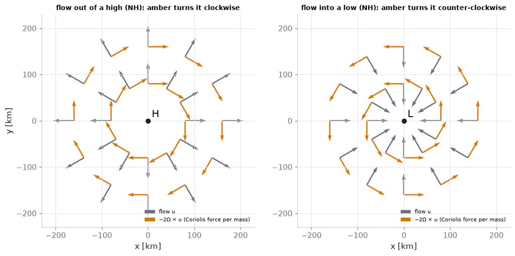

```python
ang = np.linspace(0, 2*np.pi, 12, endpoint=False)                   # 12 directions round the centre [rad]
Xg = np.concatenate([R*np.cos(ang) for R in (8e4, 1.6e5)])           # points on two rings, 80 and 160 km out [m]
Yg = np.concatenate([R*np.sin(ang) for R in (8e4, 1.6e5)])
fig, axs = plt.subplots(1, 2, figsize=(10, 4.8))                                        # the figure and its panels
Om_NH = np.array([0, 0, ch04.OMEGA_EARTH])                           # Northern-Hemisphere pole: Ω up
for ax, sense in zip(axs, ("high", "low")):  # a high and a low
    U, V = ch04.high_low_flow(Xg, Yg, U_R=1.0, sense=sense)          # radial outflow (high) or inflow (low) [m/s]
    F = np.array([ch04.coriolis_acceleration(Om_NH, np.array([u_, v_, 0.0])) for u_, v_ in zip(U, V)])   # −2Ω × u at each point [m/s²]
    ax.quiver(Xg/1e3, Yg/1e3, U, V, color=COLORS["muted"], scale=10, width=0.006, label="flow u")   # the flow (grey)
    ax.quiver(Xg/1e3, Yg/1e3, F[:, 0], F[:, 1], color=COLORS["amber"], scale=1.5e-3, width=0.006,
              label="−2Ω × u (Coriolis force per mass)")             # Coriolis force (amber), at right angles to the flow
    ax.plot(0, 0, "o", color=COLORS["ink"]); ax.text(8, 8, "H" if sense == "high" else "L", fontsize=14)   # the pressure centre
    ax.set_xlim(-230, 230); ax.set_ylim(-230, 230); ax.legend(fontsize=7, loc="lower right")               # fixed limits, legend
    ax.set_aspect("equal"); ax.set_xlabel("x [km]"); ax.set_title(f"flow {'out of a high' if sense == 'high' else 'into a low'} (NH): amber turns it "  # axis labels with units
                                                               + ("clockwise" if sense == "high" else "counter-clockwise"), fontsize=9)
axs[0].set_ylabel("y [km]")                                        # axis labels with units
savefig(fig, "ch04", "highs_lows"); plt.show()                                        # save the PNG to outputs/ch04, then draw
```

**What you see.** Grey arrows pointing out (high) or in (low); amber arrows at right angles to them.

**How to read it.** The amber arrows turn outflow clockwise and inflow counter-clockwise in the Northern Hemisphere — the sense of the winds round highs and lows on a weather map.

**What would change if…** …Southern Hemisphere: every amber arrow reverses.

```python
from plotly.subplots import make_subplots                            # a 3-D scene next to a 2-D plot
boost = 18.0                                                         # Ω exaggerated so that Ω²a ≈ g/3 is visible
fig = make_subplots(rows=1, cols=2, specs=[[{"type": "scene"}, {"type": "xy"}]], column_widths=[0.62, 0.38],  # a 3-D scene next to a 2-D plot
                    subplot_titles=("exaggerated Ω: g_n (blue), Ω²R (purple), g_e (black)", "true tilt of the plumb line"))
nn = 40 if not FAST else 24
th_, ph_ = np.meshgrid(np.linspace(0, np.pi, nn), np.linspace(0, 2*np.pi, nn))   # sphere parameters
fig.add_trace(go.Surface(x=np.sin(th_)*np.cos(ph_), y=np.sin(th_)*np.sin(ph_), z=0.85*np.cos(th_), opacity=0.25,  # add a trace to the plotly figure
                         colorscale=[[0, COLORS["blue"]], [1, COLORS["blue"]]], showscale=False, name="flattened equipotential"), 1, 1)  # a translucent flattened Earth
gn, cen_scale = 0.5, 0.5*(boost*ch04.OMEGA_EARTH)**2*ch04.EARTH_RADIUS/9.80   # arrow lengths (g_n drawn as 0.5)
for lat in (0, 30, 60, 90):                                          # four latitudes on one meridian
    la = np.deg2rad(lat); P = np.array([np.cos(la), 0, np.sin(la)])  # the point on the unit sphere
    g_arrow = -gn*P                                                   # gravitation toward the centre
    c_arrow = np.array([cen_scale*np.cos(la)/1.0, 0, 0])              # centrifugal: away from the axis, ∝ R = cos(lat)
    for vec, col in ((g_arrow, COLORS["blue"]), (c_arrow, COLORS["accent"]), (g_arrow + c_arrow, COLORS["ink"])):  # gravitation, centrifugal and their sum
        fig.add_trace(go.Scatter3d(x=[P[0], P[0] + vec[0]], y=[P[1], P[1] + vec[1]], z=[P[2], P[2] + vec[2]], mode="lines",  # add a trace to the plotly figure
                                   line=dict(color=col, width=6), showlegend=False), 1, 1)
lats = np.linspace(0, 90, 91)                                        # latitude [°]
ge, dev = ch04.effective_gravity(np.deg2rad(lats))                   # true |g_e| and tilt from the radial direction
fig.add_trace(go.Scatter(x=lats, y=np.rad2deg(dev), mode="lines", line=dict(color=COLORS["ink"]), name="tilt [°]"), 1, 2)  # add a trace to the plotly figure
fig.update_xaxes(title_text="latitude [°]", row=1, col=2); fig.update_yaxes(title_text="tilt of g_e [°]", row=1, col=2)  # axis titles and layout
fig.update_layout(height=520, showlegend=False, scene=dict(aspectmode="data"))                      # axis titles and layout
fig.show()                                        # draw the interactive figure
```

[interactive chart not shown]

**What you see.** On the exaggerated Earth the black effective-gravity arrows lean away from the centre except at the pole and the equator; on the right the true tilt peaks near 45°.

**How to read it.** Plumb lines do not point at the Earth's centre except at the poles and the equator; the real tilt is small (≈ 0.1° at 45°), but it is why the Earth's surface is a flattened spheroid. (The right panel is a toy: a spherical Earth with uniform gravitation g_n = 9.80 m/s²; real gravity also depends on the flattening, so standard gravity at 45° is 9.80665 m/s².)

**What would change if…** …a planet spinning twice as fast: the centrifugal arrows grow four times (Ω²) and so does the tilt.

#### 🎮 Interactive: Why does a straight throw curve on a merry-go-round?

**Why interactive rather than a static figure:** the whole idea is that one motion looks different to two observers at the same instant; running both views on one clock, and changing Ω and the hemisphere, makes the apparent forces visible as they act.

One ball, one clock, two observers: the inertial view (straight path, table turning) beside the rotating view (curved path) with the apparent forces of (4.45), $\rho\frac{D'\mathbf u'}{Dt}=-\nabla'p+\rho\big[\mathbf g-\frac{d\mathbf U}{dt}-2\boldsymbol\Omega\times\mathbf u'-\frac{d\boldsymbol\Omega}{dt}\times\mathbf x'-\boldsymbol\Omega\times(\boldsymbol\Omega\times\mathbf x')\big]+\mu\nabla'^2\mathbf u'$, drawn as arrows and bars. Modes: turntable, Earth's pole, flow out of a high, effective gravity.

**What to try:**

- Preset 'Earth pole 1 h': compare the deflection readout with Ωut² = 9.45 km.
- Set Ω = 0: the rotating view becomes the inertial one — no amber arrow.
- Mode 'flow out of a high': switch to the Southern Hemisphere and watch the turning reverse.
- Derivation tab, D15 steps 6 and 9: each adds one half of the Coriolis arrow.

```python
show_viz("ch04", "rotating_frame_coriolis")   # full-width explainer; ⤢ Full screen for more room
```

🎮 Interactive 5/9 Why does a straight throw curve on a merry-go-round? Open alone ↗

[interactive chart not shown]

**What would change if…** …we asked not for forces but for energy? Every force above does work at some rate — except Coriolis, which is always perpendicular to the motion. The next block follows the energy of a fluid particle and finds where viscosity sends it (C10).

## 4.8 Conservation of Energy

**What is this section about?** The first law of thermodynamics for a moving fluid particle. We derive the total-energy equation, split off its mechanical part (Cauchy's equation dotted with u) and are left with an equation for the internal energy whose viscous term — the dissipation ε — can only be positive: viscosity turns motion into heat and never the reverse.

> 🔁 **Recap — A symmetric tensor contracted with an antisymmetric one gives zero** (Ch. 2 §2.10). For symmetric σ and antisymmetric A, $\sigma_{ij}A_{ij}=0$ (Ch. 2 §2.10: swap the dummy indices, use σ_ji = σ_ij and A_ji = −A_ij, so the sum equals minus itself). Chapter 2 flagged that this is exactly what makes the viscous work depend only on the strain rate — used in step 7 of D22 below.

```python
rng = np.random.default_rng(0)                                       # reproducible random numbers (Ch. 1 P10)
B = rng.normal(size=(3, 3)); sig = B + B.T; A = B - B.T              # a symmetric and an antisymmetric tensor
print(tensors.symmetric_double_contraction(sig, A))                  # σ_ij A_ij = 0 (to rounding)
```

```
(0.0, 0.0, 0.0)
```

> 🔁 **Recap — The Gibbs relation** (Ch. 1 §1.8). For a substance in equilibrium $T\,ds=de+p\,dv$ *(Eq. 1.18)*, with v = 1/ρ the specific volume. Applied along the path of a fluid particle (each particle is in local equilibrium) it reads $\frac{De}{Dt}=T\frac{Ds}{Dt}-p\frac{D(1/\rho)}{Dt}$ *(Eq. 4.61)* — the bridge from energy to entropy.

### 🧩 Where the energy goes: internal energy and viscous dissipation (4.57) `C10`

*The question:* Stir a cup of coffee and let go. The swirl dies away. Its kinetic energy has to go somewhere — where, and can it ever come back?

*In one line:* $\frac{De}{Dt}=-p\frac{Dv}{Dt}+\frac1\rho\sigma_{ij}S_{ij}-\frac1\rho\frac{\partial q_i}{\partial x_i}$ *(4.57)*

#### The problem in plain words

Energy is conserved, but not every kind of energy is equally useful. The swirl's kinetic energy ends up as a (tiny) warming of the coffee; the reverse — coffee spontaneously starting to swirl while cooling — never happens. In the atmosphere the same one-way conversion ends the kinetic-energy cycle: winds are driven by heating differences and die by friction, which returns the energy as heat. Lubricated bearings get hot for the same reason, and in turbulence (Ch. 12) the rate of this conversion, ε, is the most important single number.

#### The idea

```
total energy e + ½u²:  rate = work of gravity + work of surface stresses − heat conducted out        (4.53)
kinetic ½u² alone:     Cauchy (4.24) · u  = work of gravity + work of the NET pressure and viscous forces (4.56)
subtract:  internal e:  De/Dt = −p Dv/Dt  +  ε  −  (1/ρ)∇·q                                          (4.57)
                                compression  dissipation ≥ 0  conduction
```

*The numbered equations in the sketch:* $\frac{\partial}{\partial t}\big(\rho\big[e+\tfrac12u_j^2\big]\big)+\frac{\partial}{\partial x_i}\big(\rho\big[e+\tfrac12u_j^2\big]u_i\big)=\rho g_iu_i+\frac{\partial}{\partial x_i}(\tau_{ij}u_j)-\frac{\partial q_i}{\partial x_i}$ *(4.53)* · $\rho\frac{Du_j}{Dt}=\rho g_j+\frac{\partial\tau_{ij}}{\partial x_i}$ *(4.24)* · $\rho\frac{D}{Dt}\big(\tfrac12u_j^2\big)=\rho g_ju_j-u_j\frac{\partial p}{\partial x_j}+u_j\frac{\partial\sigma_{ij}}{\partial x_i}$ *(4.56)* · $\frac{De}{Dt}=-p\frac{Dv}{Dt}+\frac1\rho\sigma_{ij}S_{ij}-\frac1\rho\frac{\partial q_i}{\partial x_i}$ *(4.57)*

Stress does two kinds of work: *force work* (the net force times the velocity) speeds particles up or slows them down; *deformation work* (stress times the rate of deformation) changes their shape — and the viscous part of that is lost to heat.

> 🔁 **Tools from earlier chapters used here** (see `knowledge/primers.md`)
- **internal and kinetic energy per unit mass** — e is the molecular (thermal) energy per kg, ½|u|² the bulk kinetic energy per kg (Ch. 1 P32).

> 📎 **Primer — power of a force and heat flux through a surface.** `P127` · A force F acting on something moving at velocity u does work at the rate F·u (watts). Per unit area of a surface the stress does work at f·u; per unit volume gravity does work at ρg·u. Heat crossing a surface with outward normal n at flux q (W/m²) leaves at the rate q·n per unit area — so a *minus* sign appears when we count heat *gained*.

```python
f = np.array([2.0, 0.0, 0.0]); u = np.array([3.0, 4.0, 0.0])     # traction [Pa], velocity [m/s]
print(f @ u)                                                      # 6.0 W/m²: only the part of u along f counts
q = np.array([0.0, 0.0, 50.0]); n = np.array([0, 0, 1.0])         # heat flux [W/m²] and a lid's outward normal
print(-q @ n)                                                     # −50 W/m²: heat leaving through a lid
```

```
6.0
-50.0
```

📝 **Note.** **First law for a material volume** `N66` — (Ch. 1's first law $de=\delta q+\delta w$ *(1.10)* per unit time: heat in + work done = rise of internal + kinetic energy):

$$ \frac{d}{dt}\int_{V(t)}\rho\big(e+\tfrac12\lvert\mathbf u\rvert^2\big)dV=\int_{V(t)}\rho\mathbf g\cdot\mathbf u\,dV+\int_{A(t)}\mathbf f\cdot\mathbf u\,dA-\int_{A(t)}\mathbf q\cdot\mathbf n\,dA \qquad \text{(4.46)} $$

#### 🧮 Derivation — The total-energy equation: (4.46) → (4.47) → (4.49)–(4.52) → (4.53) `D19` (Eq. 4.53)

**What we want to show.** Turn the first law of thermodynamics for a material volume into a field equation for the total energy e + ½u² at a point.

**Assumptions.** Heat transfer by a flux q (conduction; radiation included if it is a flux); fields smooth; every material volume (step 8).

**The plan.**

1. Expand the material rate.
2. Turn the three surface integrals into volume integrals with Gauss.
3. Collect and localise.

**Tools we use** (each explained before this point): RTT (R01) · power of a force and heat flux through a surface (primer in C10) · Gauss (R02) · traction $f_j=n_i\tau_{ij}$ (R03) · localisation lemma (N07).

**We start from**

$$ \text{(4.46):}\ \frac{d}{dt}\int_{V}\rho\big(e+\tfrac12\lvert\mathbf u\rvert^2\big)dV=\int_{V}\rho\mathbf g\cdot\mathbf u\,dV+\int_{A}\mathbf f\cdot\mathbf u\,dA-\int_{A}\mathbf q\cdot\mathbf n\,dA $$

*In words:* the internal plus kinetic energy of a material volume rises by the work of gravity and of the surface forces, and falls by the heat conducted out.

**Step 1 of 8 — Start from the first law.**

$$ \frac{d}{dt}\int_{V}\rho\big(e+\tfrac12u_ju_j\big)dV=\int_{V}\rho g_iu_i\,dV+\int_{A}f_ju_j\,dA-\int_{A}q_in_i\,dA $$

- *Why we can do this:* (4.46), $\frac{d}{dt}\int_{V(t)}\rho\big(e+\tfrac12\lvert\mathbf u\rvert^2\big)dV=\int_{V(t)}\rho\mathbf g\cdot\mathbf u\,dV+\int_{A(t)}\mathbf f\cdot\mathbf u\,dA-\int_{A(t)}\mathbf q\cdot\mathbf n\,dA$ in index form: work rates are force · velocity, heat leaving counts negative (primer).
- *In words:* Energy in = work done + heat in.

**Step 2 of 8 — Expand with the transport theorem.**

$$ \int_{V}\frac{\partial}{\partial t}\Big(\rho\big[e+\tfrac12u_j^2\big]\Big)dV+\int_{A}\rho\big[e+\tfrac12u_j^2\big]u_in_i\,dA=\ldots $$

- *Why we can do this:* RTT (3.35), $\frac{d}{dt}\int_{V^*}F\,dV=\int_{V^*}\frac{\partial F}{\partial t}dV+\int_{A^*}F\,\mathbf b\cdot\mathbf n\,dA$ with F = ρ(e + ½u_j²), b = u. This is (4.47), $\int_{V}\frac{\partial}{\partial t}\big(\rho e+\tfrac\rho2\lvert\mathbf u\rvert^2\big)dV+\int_{A}\big(\rho e+\tfrac\rho2\lvert\mathbf u\rvert^2\big)(\mathbf u\cdot\mathbf n)dA=\int_{V}\rho\mathbf g\cdot\mathbf u\,dV+\int_{A}\mathbf f\cdot\mathbf u\,dA-\int_{A}\mathbf q\cdot\mathbf n\,dA$ — the line above; u_j² is summed over j.
- *In words:* Local change plus energy carried by the moving skin.

**Step 3 of 8 — Gauss on the energy flux.**

$$ \int_{A}\rho\big[e+\tfrac12u_j^2\big]u_in_i\,dA=\int_{V}\frac{\partial}{\partial x_i}\Big(\rho\big[e+\tfrac12u_j^2\big]u_i\Big)dV $$

- *Why we can do this:* Gauss (2.30), $\int_V\nabla\cdot\mathbf Q\,dV=\int_A\mathbf Q\cdot\mathbf n\,dA$ on the vector field ρEu_i. This is (4.49), $\int_{A}\rho\big[e+\tfrac12u_j^2\big]u_in_i\,dA=\int_{V}\frac{\partial}{\partial x_i}\Big(\rho\big[e+\tfrac12u_j^2\big]u_i\Big)dV$ — the line above.
- *In words:* Energy carried out = its flux divergence.

**Step 4 of 8 — Write the stress power with τ.**

$$ \int_{A}f_ju_j\,dA=\int_{A}n_i\tau_{ij}u_j\,dA $$

- *Why we can do this:* Traction f_j = n_iτ_ij (R03, first index = face).
- *In words:* The surface forces' power per area is n·τ·u.

**Step 5 of 8 — Gauss on the stress power.**

$$ \int_{A}n_i\tau_{ij}u_j\,dA=\int_{V}\frac{\partial}{\partial x_i}\big(\tau_{ij}u_j\big)dV $$

- *Why we can do this:* For the vector τ_iju_j (index i), Gauss contracts i with n_i. This is (4.50), $\int_{A}n_i\tau_{ij}u_j\,dA=\int_{V}\frac{\partial}{\partial x_i}\big(\tau_{ij}u_j\big)dV$ — the line above.
- *In words:* The surface work becomes a divergence.

**Step 6 of 8 — Gauss on the heat flux.**

$$ \int_{A}q_in_i\,dA=\int_{V}\frac{\partial q_i}{\partial x_i}dV $$

- *Why we can do this:* Gauss on q. This is (4.51), $\int_A q_in_i\,dA=\int_V\frac{\partial q_i}{\partial x_i}dV$ — the line above — the book prints dA inside the volume integrals, a slip: it must be dV.
- *In words:* Heat leaving = divergence of the heat flux.

**Step 7 of 8 — Collect under one integral.**

$$ \int_{V}\Big\{\frac{\partial(\rho E)}{\partial t}+\frac{\partial(\rho Eu_i)}{\partial x_i}-\rho g_iu_i-\frac{\partial(\tau_{ij}u_j)}{\partial x_i}+\frac{\partial q_i}{\partial x_i}\Big\}dV=0 $$

- *Why we can do this:* All terms are integrals over V; E = e + ½u_j² for short. This is (4.52), $\int_{V}\Big\{\frac{\partial(\rho E)}{\partial t}+\frac{\partial(\rho Eu_i)}{\partial x_i}-\rho g_iu_i-\frac{\partial(\tau_{ij}u_j)}{\partial x_i}+\frac{\partial q_i}{\partial x_i}\Big\}dV=0$ — the line above.
- *In words:* One integrand, zero integral.

**Step 8 of 8 — Localise.**

$$ \frac{\partial(\rho E)}{\partial t}+\frac{\partial(\rho Eu_i)}{\partial x_i}=\rho g_iu_i+\frac{\partial(\tau_{ij}u_j)}{\partial x_i}-\frac{\partial q_i}{\partial x_i} $$

- *Why we can do this:* True for every material volume with a continuous integrand: the localisation lemma (D02). This is (4.53), $\frac{\partial}{\partial t}\big(\rho\big[e+\tfrac12u_j^2\big]\big)+\frac{\partial}{\partial x_i}\big(\rho\big[e+\tfrac12u_j^2\big]u_i\big)=\rho g_iu_i+\frac{\partial}{\partial x_i}(\tau_{ij}u_j)-\frac{\partial q_i}{\partial x_i}$ — the line above.
- *In words:* Total energy is conserved at every point.

**Result**

$$ \frac{\partial}{\partial t}\big(\rho[e+\tfrac12u_j^2]\big)+\frac{\partial}{\partial x_i}\big(\rho[e+\tfrac12u_j^2]u_i\big)=\rho g_iu_i+\frac{\partial}{\partial x_i}(\tau_{ij}u_j)-\frac{\partial q_i}{\partial x_i}\ \text{(4.53).} $$

**What it means.** The conservative energy equation used by compressible codes (Ch. 10, 15). D20 rewrites it for a particle and D21–D22 split it into mechanical and thermal parts.

**Check it.** Units W/m³ ✓. Fluid at rest, τ = −pδ: ∂(ρe)/∂t = −∇·q — pure conduction ✓. Steady Couette: the moving wall's work τU arrives through ∂(τ_iju_j)/∂x_i and leaves as heat ✓ (C10 worked example).

> ⚠️ **Common confusion (traps in `D19`):** The dA/dV slip of (4.51), $\int_A q_in_i\,dA=\int_V\frac{\partial q_i}{\partial x_i}dV$. Forgetting that u_j² is summed. Sign of the heat term (outflow positive q·n is a loss).

📝 **Note.** **The book's (4.47)** `N67` — D19's step 2: the transport theorem with F = ρ(e + ½|u|²), b = u.

$$ \int_{V}\frac{\partial}{\partial t}\Big(\rho e+\frac\rho2\lvert\mathbf u\rvert^2\Big)dV+\int_{A}\Big(\rho e+\frac\rho2\lvert\mathbf u\rvert^2\Big)(\mathbf u\cdot\mathbf n)dA=\int_{V}\rho\mathbf g\cdot\mathbf u\,dV+\int_{A}\mathbf f\cdot\mathbf u\,dA-\int_{A}\mathbf q\cdot\mathbf n\,dA \qquad \text{(4.47)} $$

📝 **Note.** **The energy budget of any control volume** `N68` — The same coincidence move as D01 and D05 gives it (stated, not re-derived). `ch04.energy_budget` evaluates it (used for nozzles and shocks in Ch. 15).

$$ \frac{d}{dt}\int_{V^*}\rho\big(e+\tfrac12\lvert\mathbf u\rvert^2\big)dV+\int_{A^*}\big(\rho e+\tfrac\rho2\lvert\mathbf u\rvert^2\big)(\mathbf u-\mathbf b)\cdot\mathbf n\,dA=\int_{V^*}\rho\mathbf g\cdot\mathbf u\,dV+\int_{A^*}\mathbf f\cdot\mathbf u\,dA-\int_{A^*}\mathbf q\cdot\mathbf n\,dA \qquad \text{(4.48)} $$

📝 **Note.** **Gauss on each surface term** `N69` `N70` `N71` `N72` — steps 3–7 of D19 are the book's (4.49)–(4.52), $\int_{V}\Big\{\frac{\partial(\rho E)}{\partial t}+\frac{\partial(\rho Eu_i)}{\partial x_i}-\rho g_iu_i-\frac{\partial(\tau_{ij}u_j)}{\partial x_i}+\frac{\partial q_i}{\partial x_i}\Big\}dV=0$: Gauss on the energy flux, on the stress work and on the heat flux, then everything under one integral. The heat-flux line is the one below.

> ⚠️ **Book slip:** (4.51) prints dA inside its two volume integrals; Gauss' theorem gives dV (as (4.52) then correctly uses).

$$ \int_A\mathbf q\cdot\mathbf n\,dA=\int_Aq_in_i\,dA=\int_V\nabla\cdot\mathbf q\,dV=\int_V\frac{\partial q_i}{\partial x_i}dV \qquad \text{(4.51)} $$

📝 **Note.** **Total-energy equation** `N73` — (D19's result), the conservative form used by compressible codes (Ch. 10, 15). $u_j^2=u_1^2+u_2^2+u_3^2$ (summed).

$$ \frac{\partial}{\partial t}\big(\rho\big[e+\tfrac12u_j^2\big]\big)+\frac{\partial}{\partial x_i}\big(\rho\big[e+\tfrac12u_j^2\big]u_i\big)=\rho g_iu_i+\frac{\partial}{\partial x_i}(\tau_{ij}u_j)-\frac{\partial q_i}{\partial x_i} \qquad \text{(4.53)} $$

#### 🧮 Derivation — Total energy following a particle, (4.53) → (4.55) `D20` (Eq. 4.55)

**What we want to show.** Rewrite the total-energy equation with D/Dt and split the stress work into its physical parts (the book leaves it to Exercise 4.45).

**Assumptions.** Continuity holds (step 4).

**The plan.**

1. Expand the left side and remove E × continuity (the move of (4.23)).
2. Expand the stress work with the product rule and τ = −pδ + σ.

**Tools we use** (each explained before this point): Product rule for a divergence (primer in C02) · continuity (4.7) · (4.27), $\tau_{ij}=-p\,\delta_{ij}+\sigma_{ij}$ (C07) · δ substitution (gloss).

**We start from**

$$ \begin{array}{l}\text{(4.53) with E = e + ½u\_j²:} \\ \frac{\partial(\rho E)}{\partial t}+\frac{\partial(\rho Eu_i)}{\partial x_i}=\rho g_iu_i+\frac{\partial(\tau_{ij}u_j)}{\partial x_i}-\frac{\partial q_i}{\partial x_i}\ \text{.}\end{array} $$

**Step 1 of 7 — Name the specific total energy.**

$$ E\equiv e+\tfrac12u_ju_j $$

- *Why we can do this:* A short name for internal plus kinetic energy per unit mass keeps the algebra readable.
- *In words:* Energy per kilogram.

**Step 2 of 7 — Expand the left side.**

$$ \frac{\partial(\rho E)}{\partial t}+\frac{\partial(\rho Eu_i)}{\partial x_i}=\rho\frac{\partial E}{\partial t}+E\frac{\partial\rho}{\partial t}+\rho u_i\frac{\partial E}{\partial x_i}+E\frac{\partial(\rho u_i)}{\partial x_i} $$

- *Why we can do this:* Product rule twice (the second with the factors E and ρu_i).
- *In words:* Four pieces.

**Step 3 of 7 — Group E times continuity.**

$$ =\rho\Big(\frac{\partial E}{\partial t}+u_i\frac{\partial E}{\partial x_i}\Big)+E\Big[\frac{\partial\rho}{\partial t}+\frac{\partial(\rho u_i)}{\partial x_i}\Big] $$

- *Why we can do this:* Collect the terms with ρ and with E — the move of (4.23), $\frac{\partial(\rho u_j)}{\partial t}+\frac{\partial(\rho u_iu_j)}{\partial x_i}=\rho\frac{Du_j}{Dt}$ with u_j replaced by E.
- *In words:* A material derivative and the continuity bracket.

**Step 4 of 7 — Drop the bracket, recognise D/Dt.**

$$ \frac{\partial(\rho E)}{\partial t}+\frac{\partial(\rho Eu_i)}{\partial x_i}=\rho\frac{DE}{Dt} $$

- *Why we can do this:* The bracket is (4.7), $\frac{\partial\rho}{\partial t}+\nabla\cdot(\rho\mathbf u)=0$ = 0; the first group is (3.5), $\frac{DF}{Dt}=\frac{\partial F}{\partial t}+\mathbf u\cdot\nabla F$ with F = E.
- *In words:* The flux form equals ρ times the particle's rate.

**Step 5 of 7 — Expand the stress work.**

$$ \frac{\partial(\tau_{ij}u_j)}{\partial x_i}=\tau_{ij}\frac{\partial u_j}{\partial x_i}+u_j\frac{\partial\tau_{ij}}{\partial x_i} $$

- *Why we can do this:* Product rule. The first term is work that deforms the particle, the second the work of the net force on it.
- *In words:* Deformation work plus force work.

**Step 6 of 7 — Insert τ = −pδ + σ.**

$$ \frac{\partial(\tau_{ij}u_j)}{\partial x_i}=\Big(-p\frac{\partial u_j}{\partial x_j}+\sigma_{ij}\frac{\partial u_j}{\partial x_i}\Big)+\Big(-u_j\frac{\partial p}{\partial x_j}+u_j\frac{\partial\sigma_{ij}}{\partial x_i}\Big) $$

- *Why we can do this:* (4.27), $\tau_{ij}=-p\,\delta_{ij}+\sigma_{ij}$; δ_ij∂u_j/∂x_i = ∂u_j/∂x_j and u_jδ_ij∂p/∂x_i = u_j∂p/∂x_j (δ substitution). This is (4.54), $\frac{\partial(\tau_{ij}u_j)}{\partial x_i}=\Big(-p\frac{\partial u_j}{\partial x_j}+\sigma_{ij}\frac{\partial u_j}{\partial x_i}\Big)+\Big(-u_j\frac{\partial p}{\partial x_j}+u_j\frac{\partial\sigma_{ij}}{\partial x_i}\Big)$ — the line above.
- *In words:* Pressure and viscous parts of each kind of work.

**Step 7 of 7 — Assemble.**

$$ \rho\frac{D}{Dt}\Big(e+\tfrac12u_j^2\Big)=\rho g_iu_i+\Big(-p\frac{\partial u_j}{\partial x_j}+\sigma_{ij}\frac{\partial u_j}{\partial x_i}\Big)+\Big(-u_j\frac{\partial p}{\partial x_j}+u_j\frac{\partial\sigma_{ij}}{\partial x_i}\Big)-\frac{\partial q_i}{\partial x_i} $$

- *Why we can do this:* Steps 4 and 6 in (4.53), $\frac{\partial}{\partial t}\big(\rho\big[e+\tfrac12u_j^2\big]\big)+\frac{\partial}{\partial x_i}\big(\rho\big[e+\tfrac12u_j^2\big]u_i\big)=\rho g_iu_i+\frac{\partial}{\partial x_i}(\tau_{ij}u_j)-\frac{\partial q_i}{\partial x_i}$. This is (4.55), $\rho\frac{D}{Dt}\big(e+\tfrac12u_j^2\big)=\rho g_iu_i+\Big(-p\frac{\partial u_j}{\partial x_j}+\sigma_{ij}\frac{\partial u_j}{\partial x_i}\Big)+\Big(-u_j\frac{\partial p}{\partial x_j}+u_j\frac{\partial\sigma_{ij}}{\partial x_i}\Big)-\frac{\partial q_i}{\partial x_i}$ — the line above.
- *In words:* A particle's total energy changes by gravity's work, the two kinds of stress work, and conduction.

**Result**

$$ (4.55)\quad \rho\frac{D}{Dt}\big(e+\tfrac12u_j^2\big)=\rho g_iu_i+\Big(-p\frac{\partial u_j}{\partial x_j}+\sigma_{ij}\frac{\partial u_j}{\partial x_i}\Big)+\Big(-u_j\frac{\partial p}{\partial x_j}+u_j\frac{\partial\sigma_{ij}}{\partial x_i}\Big)-\frac{\partial q_i}{\partial x_i} $$

**What it means.** The split (4.54), $\frac{\partial(\tau_{ij}u_j)}{\partial x_i}=\Big(-p\frac{\partial u_j}{\partial x_j}+\sigma_{ij}\frac{\partial u_j}{\partial x_i}\Big)+\Big(-u_j\frac{\partial p}{\partial x_j}+u_j\frac{\partial\sigma_{ij}}{\partial x_i}\Big)$ is the key to the next two derivations: the force work belongs to the kinetic energy, the deformation work to the internal energy.

**Check it.** Units W/m³ ✓. Summing the four stress-work pieces gives back ∂(τ_iju_j)/∂x_i (`ch04.stress_work_split` on the Taylor–Green test field, the code cell after note N74) ✓. Fluid at rest: ρDe/Dt = −∇·q ✓.

> ⚠️ **Common confusion (traps in `D20`):** Subtracting E × ∇·u instead of E × continuity. Losing the δ in −p∂u_j/∂x_j. Mixing up the index order in σ_ij∂u_j/∂x_i (it is S_ij that survives, D22).

📝 **Note.** **Stress work = deformation work + force work** `N74` — (D20's steps 5–6). The first bracket deforms particles (and heats them), the second changes their kinetic energy. The same split, applied to fluctuations, is the turbulent kinetic-energy budget of Ch. 12. Code: `ch04.stress_work_split` adds the four parts back to $\partial(\tau_{ij}u_j)/\partial x_i$ on a test field (below).

$$ \frac{\partial}{\partial x_i}(\tau_{ij}u_j)=\tau_{ij}\frac{\partial u_j}{\partial x_i}+u_j\frac{\partial\tau_{ij}}{\partial x_i}=\Big(-p\frac{\partial u_j}{\partial x_j}+\sigma_{ij}\frac{\partial u_j}{\partial x_i}\Big)+\Big(-u_j\frac{\partial p}{\partial x_j}+u_j\frac{\partial\sigma_{ij}}{\partial x_i}\Big) \qquad \text{(4.54)} $$

```python
u_tg, p_tg = ch04.exact_field("taylor_green", U0=1.0, k=1.0, nu=1e-3, rho=1000.0)   # a smooth test field and its pressure
sig_tg = ch04.newtonian_viscous_stress_field(u_tg, mu=1.0)           # σ(x, t) of that field for μ = 1 Pa s
sw = ch04.stress_work_split(p_tg, sig_tg, u_tg, np.array([0.3, 0.7]), 0.0)   # the four pieces of (4.54) at a point of this 2-D field [W/m³]
print({k: round(float(v), 8) for k, v in sw.items()})                # they add up to `total`: residual ≈ 0
```

```
{'total': -238.15699041, 'deformation_pressure': -0.0, 'deformation_viscous': 2.13558269, 'force_pressure': -239.43285663, 'force_viscous': -0.85972006, 'residual': 3.59e-06}
```

📝 **Note.** **Total energy following a particle** `N75` — (D20's result; the book leaves it to an exercise).

$$ \rho\frac{D}{Dt}\big(e+\tfrac12u_j^2\big)=\rho g_iu_i+\Big(-p\frac{\partial u_j}{\partial x_j}+\sigma_{ij}\frac{\partial u_j}{\partial x_i}\Big)+\Big(-u_j\frac{\partial p}{\partial x_j}+u_j\frac{\partial\sigma_{ij}}{\partial x_i}\Big)-\frac{\partial q_i}{\partial x_i} \qquad \text{(4.55)} $$

> 🔁 **Tools from earlier chapters used here** (see `knowledge/primers.md`)
- **chain rule** — $\frac{d}{dt}f(g(t))=f'(g)\,\dot g$ — here $\frac{D}{Dt}(\tfrac12u^2)=u\frac{Du}{Dt}$ (Ch. 1 P49).

> 📎 **Primer — chain rule for the kinetic energy.** `P128` · D/Dt obeys the ordinary chain rule, so $\frac{D}{Dt}\big(\tfrac12u_j^2\big)=u_j\frac{Du_j}{Dt}$ (sum over j): the rate of change of kinetic energy per unit mass is the velocity dotted with the acceleration. (A one-line reminder of Ch. 1's chain rule P49, kept as a primer because D21 hinges on it.)

```python
t = sp.symbols('t'); u = [sp.Function(f'u{j}')(t) for j in (1, 2, 3)]            # a velocity following a particle
print(sp.simplify(sp.diff(sum(v**2 for v in u)/2, t) - sum(v*sp.diff(v, t) for v in u)))   # 0
```

```
0
```

#### 🧮 Derivation — The mechanical-energy equation, (4.56) `D21` (Eq. 4.56)

**What we want to show.** An equation for the kinetic energy alone, to separate it from the internal energy (the book says "after some manipulation" and leaves it to Exercise 4.46).

**Assumptions.** None beyond Cauchy's equation (any continuum; the Newtonian law is not needed yet).

**The plan.**

1. Dot Cauchy's equation with the velocity.
2. Use the chain rule on u_jDu_j/Dt.
3. Split the stress.
4. Read the stress term as force work.

**Tools we use** (each explained before this point): Chain rule for the kinetic energy (primer in C10) · (4.27), $\tau_{ij}=-p\,\delta_{ij}+\sigma_{ij}$ (C07) · (4.54), $\frac{\partial(\tau_{ij}u_j)}{\partial x_i}=\Big(-p\frac{\partial u_j}{\partial x_j}+\sigma_{ij}\frac{\partial u_j}{\partial x_i}\Big)+\Big(-u_j\frac{\partial p}{\partial x_j}+u_j\frac{\partial\sigma_{ij}}{\partial x_i}\Big)$ (D20).

**We start from**

$$ \text{Cauchy's equation (4.24):}\ \rho\frac{Du_j}{Dt}=\rho g_j+\frac{\partial\tau_{ij}}{\partial x_i}\ \text{.} $$

**Step 1 of 6 — Start from Cauchy's equation.**

$$ \rho\frac{Du_j}{Dt}=\rho g_j+\frac{\partial\tau_{ij}}{\partial x_i} $$

- *Why we can do this:* (4.24), $\rho\frac{Du_j}{Dt}=\rho g_j+\frac{\partial\tau_{ij}}{\partial x_i}$. The book multiplies the flux form (4.22), $\frac{\partial}{\partial t}(\rho u_j)+\frac{\partial}{\partial x_i}(\rho u_iu_j)=\rho g_j+\frac{\partial\tau_{ij}}{\partial x_i}$; starting from (4.24) saves subtracting u_j × continuity (D07 steps 6–9 already did).
- *In words:* Newton's law for a particle.

**Step 2 of 6 — Dot with the velocity.**

$$ \rho u_j\frac{Du_j}{Dt}=\rho g_ju_j+u_j\frac{\partial\tau_{ij}}{\partial x_i} $$

- *Why we can do this:* Multiply component j by u_j and sum over j: force · velocity is power (primer in C10), so a force balance becomes a power balance.
- *In words:* The rate at which forces do work on the particle.

**Step 3 of 6 — Recognise the kinetic energy's rate.**

$$ \rho u_j\frac{Du_j}{Dt}=\rho\frac{D}{Dt}\Big(\tfrac12u_ju_j\Big) $$

- *Why we can do this:* Chain rule for the kinetic energy (primer): D(½u_ju_j)/Dt = u_jDu_j/Dt.
- *In words:* The left side is the particle's kinetic energy changing.

**Step 4 of 6 — Split the stress.**

$$ u_j\frac{\partial\tau_{ij}}{\partial x_i}=-u_j\frac{\partial p}{\partial x_j}+u_j\frac{\partial\sigma_{ij}}{\partial x_i} $$

- *Why we can do this:* (4.27), $\tau_{ij}=-p\,\delta_{ij}+\sigma_{ij}$, τ_ij = −pδ_ij + σ_ij, and δ substitution.
- *In words:* Work of the net pressure force and of the net viscous force.

**Step 5 of 6 — Read it as force work.**

$$ u_j\frac{\partial\tau_{ij}}{\partial x_i}=\frac{\partial(\tau_{ij}u_j)}{\partial x_i}-\tau_{ij}\frac{\partial u_j}{\partial x_i} $$

- *Why we can do this:* Product rule, i.e. (4.54), $\frac{\partial(\tau_{ij}u_j)}{\partial x_i}=\Big(-p\frac{\partial u_j}{\partial x_j}+\sigma_{ij}\frac{\partial u_j}{\partial x_i}\Big)+\Big(-u_j\frac{\partial p}{\partial x_j}+u_j\frac{\partial\sigma_{ij}}{\partial x_i}\Big)$ read backwards: the kinetic energy receives the total stress work minus the deformation work.
- *In words:* Kinetic energy gets only the work of the net force.

**Step 6 of 6 — Assemble.**

$$ \rho\frac{D}{Dt}\Big(\tfrac12u_j^2\Big)=\rho g_ju_j-u_j\frac{\partial p}{\partial x_j}+u_j\frac{\partial\sigma_{ij}}{\partial x_i} $$

- *Why we can do this:* Steps 3 and 4 in step 2. This is (4.56), $\rho\frac{D}{Dt}\big(\tfrac12u_j^2\big)=\rho g_ju_j-u_j\frac{\partial p}{\partial x_j}+u_j\frac{\partial\sigma_{ij}}{\partial x_i}$ — the line above.
- *In words:* Kinetic energy changes by the work of gravity, of the pressure force and of the viscous force.

**Result**

$$ \rho\frac{D}{Dt}\big(\tfrac12u_j^2\big)=\rho g_ju_j-u_j\frac{\partial p}{\partial x_j}+u_j\frac{\partial\sigma_{ij}}{\partial x_i} $$

*In words:* the mechanical-energy equation.

**What it means.** Viscosity enters kinetic energy only through the net viscous force, which can speed particles up or slow them down; its deformation work is not here — it goes to heat. The turbulent kinetic-energy budget of Ch. 12 is this equation for fluctuations.

**Check it.** Units W/m³ ✓. Steady Couette: no acceleration, no pressure gradient, u_j∂σ_ij/∂x_i = u μu″ = 0 ✓ (the wall's work all goes into deformation, D22). Hydrostatics: 0 = 0 ✓. `ch04.kinetic_energy_budget` residual ≈ 0 on the Taylor–Green test field (the cell right after this derivation) ✓.

> ⚠️ **Common confusion (traps in `D21`):** Multiplying the flux form (4.22), $\frac{\partial}{\partial t}(\rho u_j)+\frac{\partial}{\partial x_i}(\rho u_iu_j)=\rho g_j+\frac{\partial\tau_{ij}}{\partial x_i}$ by u_j without subtracting u_j × continuity (the book's wording). Forgetting the sum over j. Treating u_j∂σ_ij/∂x_i as dissipation (it is not sign-definite).

```python
u_tg, p_tg = ch04.exact_field("taylor_green", U0=1.0, k=1.0, nu=1e-3, rho=1000.0)   # an exact Navier–Stokes solution (ρ = 1000, μ = 1)
sig_tg = ch04.newtonian_viscous_stress_field(u_tg, mu=1.0)           # its viscous stress σ(x, t) [Pa]
ke = ch04.kinetic_energy_budget(1000.0, u_tg, p_tg, sig_tg, g=(0.0, 0.0), x=np.array([0.3, 0.7]), t=0.2)   # the terms of (4.56) [W/m³]
print({k: round(float(v), 6) for k, v in ke.items()})               # ρD(½u²)/Dt = pressure work + viscous-force work; residual ≈ 0
```

```
{'lhs': -240.004742, 'gravity_work': 0.0, 'pressure_work': -239.14571, 'viscous_force_work': -0.859033, 'residual': -0.0}
```

**What does the code above do?**

The mechanical-energy equation $\rho\frac{D}{Dt}(\tfrac12u_j^2)=\rho g_ju_j-u_j\frac{\partial p}{\partial x_j}+u_j\frac{\partial\sigma_{ij}}{\partial x_i}$ *(4.56)* term by term on the decaying Taylor–Green vortices: the kinetic-energy rate (−240.0 W/m³) is the pressure work (−239.1) plus the work of the net viscous force (−0.86); the residual is ≈ 10⁻⁹ — the D21 check.

📝 **Note.** **Mechanical-energy equation** `N76` — Cauchy's equation dotted with u.

> ⚠️ The book says "multiply (4.22) by u_j"; (4.22), $\frac{\partial}{\partial t}(\rho u_j)+\frac{\partial}{\partial x_i}(\rho u_iu_j)=\rho g_j+\frac{\partial\tau_{ij}}{\partial x_i}$, is the flux form, from which you must also subtract u_j × continuity. Starting from Cauchy's (4.24), $\rho\frac{Du_j}{Dt}=\rho g_j+\frac{\partial\tau_{ij}}{\partial x_i}$, is one step shorter (D21 does this). Mean and turbulent kinetic energy: Ch. 12.

$$ \rho\frac{D}{Dt}\big(\tfrac12u_j^2\big)=\rho g_ju_j-u_j\frac{\partial p}{\partial x_j}+u_j\frac{\partial\sigma_{ij}}{\partial x_i} \qquad \text{(4.56)} $$

#### 🧮 Derivation — The internal-energy equation: (4.55) − (4.56) → (4.57) `D22` (Eq. 4.57)

**What we want to show.** Subtract the mechanical part from the total energy and find what heats a fluid particle.

**Assumptions.** σ symmetric (step 7, from (4.25), $\tau_{ij}=\tau_{ji}$); ρ > 0.

**The plan.**

1. Subtract; watch the force-work terms cancel.
2. Divide by ρ and turn ∇·u into −Dv/Dt with continuity.
3. Show only S survives in the viscous work.

**Tools we use** (each explained before this point): (4.55), $\rho\frac{D}{Dt}\big(e+\tfrac12u_j^2\big)=\rho g_iu_i+\Big(-p\frac{\partial u_j}{\partial x_j}+\sigma_{ij}\frac{\partial u_j}{\partial x_i}\Big)+\Big(-u_j\frac{\partial p}{\partial x_j}+u_j\frac{\partial\sigma_{ij}}{\partial x_i}\Big)-\frac{\partial q_i}{\partial x_i}$ (D20), (4.56), $\rho\frac{D}{Dt}\big(\tfrac12u_j^2\big)=\rho g_ju_j-u_j\frac{\partial p}{\partial x_j}+u_j\frac{\partial\sigma_{ij}}{\partial x_i}$ (D21) · continuity with D/Dt (4.8), $\frac{1}{\rho}\frac{D\rho}{Dt}+\nabla\cdot\mathbf u=0$ (C02) · quotient rule (gloss) · σ:R = 0 for symmetric σ (R07) · G = S + ½R (3.11), $\frac{\partial u_i}{\partial x_j}=S_{ij}+\tfrac12R_{ij}$ (Ch. 3 §3.4).

**We start from**

$$ \begin{array}{l}(4.55)\quad \rho\frac{D}{Dt}\big(e+\tfrac12u_j^2\big)=\rho g_iu_i+\Big(-p\frac{\partial u_j}{\partial x_j}+\sigma_{ij}\frac{\partial u_j}{\partial x_i}\Big)+\Big(-u_j\frac{\partial p}{\partial x_j}+u_j\frac{\partial\sigma_{ij}}{\partial x_i}\Big)-\frac{\partial q_i}{\partial x_i} \\ (4.56)\quad \rho\frac{D}{Dt}\big(\tfrac12u_j^2\big)=\rho g_ju_j-u_j\frac{\partial p}{\partial x_j}+u_j\frac{\partial\sigma_{ij}}{\partial x_i}\end{array} $$

*In words:* the total-energy and kinetic-energy equations following a particle.

**Step 1 of 8 — Subtract (4.56) from (4.55).**

$$ \rho\frac{De}{Dt}=-p\frac{\partial u_j}{\partial x_j}+\sigma_{ij}\frac{\partial u_j}{\partial x_i}-\frac{\partial q_i}{\partial x_i} $$

- *Why we can do this:* D(e + ½u²)/Dt − D(½u²)/Dt = De/Dt; gravity's work and the force work appear in both and cancel exactly; only deformation work and conduction remain.
- *In words:* Internal energy changes by deformation work and heat.

**Step 2 of 8 — Divide by ρ.**

$$ \frac{De}{Dt}=-\frac p\rho\frac{\partial u_j}{\partial x_j}+\frac1\rho\sigma_{ij}\frac{\partial u_j}{\partial x_i}-\frac1\rho\frac{\partial q_i}{\partial x_i} $$

- *Why we can do this:* ρ > 0; per unit mass, like the first law of Ch. 1.
- *In words:* The same, per kilogram.

**Step 3 of 8 — Replace ∇·u with continuity.**

$$ -\frac p\rho\nabla\cdot\mathbf u=\frac p\rho\cdot\frac1\rho\frac{D\rho}{Dt} $$

- *Why we can do this:* (4.8), $\frac1\rho\frac{D\rho}{Dt}+\nabla\cdot\mathbf u=0$, so ∇·u = −(1/ρ)Dρ/Dt.
- *In words:* Expansion rate = minus the fractional density rate.

**Step 4 of 8 — Use the quotient rule.**

$$ \frac1{\rho^2}\frac{D\rho}{Dt}=-\frac{D}{Dt}\Big(\frac1\rho\Big)=-\frac{Dv}{Dt} $$

- *Why we can do this:* Quotient rule (gloss): D(1/ρ)/Dt = −ρ⁻²Dρ/Dt; v = 1/ρ is the specific volume.
- *In words:* A density rise is a specific-volume fall.

**Step 5 of 8 — Get the compression work.**

$$ -\frac p\rho\frac{\partial u_j}{\partial x_j}=-p\frac{Dv}{Dt} $$

- *Why we can do this:* Combine steps 3 and 4. It is the −p dv of Ch. 1's first law, per unit time.
- *In words:* Compressing a particle heats it; expanding cools it.

**Step 6 of 8 — Split the velocity gradient.**

$$ \frac{\partial u_j}{\partial x_i}=S_{ji}+\tfrac12R_{ji} $$

- *Why we can do this:* G = S + ½R (3.11), $\frac{\partial u_i}{\partial x_j}=S_{ij}+\tfrac12R_{ij}$ with the book's R = G − Gᵀ; the book prints S_ji + R_ji (the ½ is missing, harmless as the next step shows).
- *In words:* A deformation part and a rotation part.

**Step 7 of 8 — Drop the rotation part.**

$$ \sigma_{ij}\frac{\partial u_j}{\partial x_i}=\sigma_{ij}S_{ji}=\sigma_{ij}S_{ij} $$

- *Why we can do this:* R07: σ symmetric and R antisymmetric ⇒ σ_ijR_ji = 0; S symmetric ⇒ S_ji = S_ij.
- *In words:* Spinning a particle does no viscous work; only deforming it does.

**Step 8 of 8 — Assemble.**

$$ \frac{De}{Dt}=-p\frac{Dv}{Dt}+\frac1\rho\sigma_{ij}S_{ij}-\frac1\rho\frac{\partial q_i}{\partial x_i} $$

- *Why we can do this:* Steps 2, 5 and 7. This is (4.57), $\frac{De}{Dt}=-p\frac{Dv}{Dt}+\frac1\rho\sigma_{ij}S_{ij}-\frac1\rho\frac{\partial q_i}{\partial x_i}$ — the line above.
- *In words:* Internal energy rises by compression, by viscous deformation work (ε) and by heat conducted in.

**Result**

$$ \frac{De}{Dt}=-p\frac{Dv}{Dt}+\frac1\rho\sigma_{ij}S_{ij}-\frac1\rho\frac{\partial q_i}{\partial x_i} $$

*In words:* the internal-energy equation: the first law per unit mass and time for a particle.

**What it means.** Energy moves between the two budgets through two doors: −p∇·u (reversible, either sign) and ε (irreversible, D23). Ch. 13's heat equation and C13's Boussinesq form start here.

**Check it.** Units W/kg ✓. Fluid at rest: De/Dt = −(1/ρ)∇·q (conduction) ✓. Steady Couette: ε = 1.0 W/kg is conducted away at the same rate ✓. The pressure-work term matches Ch. 1's −p dv ✓.

> ⚠️ **Common confusion (traps in `D22`):** Losing the exact cancellation of the force work (a sign slip leaves a spurious term). Writing −p∇·u as −pDv/Dt without continuity. Thinking the rotation part contributes (it cannot, σ is symmetric).

📝 **Note.** **Internal energy — the thermal half of the energy budget** `C10` — C10's equation, restated. It is the first law of Ch. 1 for a particle, per unit time: compression work −p dv, viscous heating, heat conduction. Only the first and last can change sign.

$$ \frac{De}{Dt}=-p\frac{Dv}{Dt}+\frac1\rho\sigma_{ij}S_{ij}-\frac1\rho\frac{\partial q_i}{\partial x_i} \qquad \text{(4.57)} $$

> 📎 **Primer — completing the square for tensors.** `P129` · The double sum $A_{ij}A_{ij}=\sum_{i,j}A_{ij}^2$ is a sum of squares, so it is ≥ 0 and zero only when every component is. To show an expression is never negative, rewrite it as such sums: here $S_{ij}S_{ij}-\tfrac13S_{mm}^2=\big(S_{ij}-\tfrac13S_{mm}\delta_{ij}\big)\big(S_{ij}-\tfrac13S_{mm}\delta_{ij}\big)$ (expand the right side and use $\delta_{ij}\delta_{ij}=3$).

```python
S = np.random.default_rng(3).normal(size=(3, 3)); S = (S + S.T)/2          # a random symmetric S
D = S - np.trace(S)/3*np.eye(3)                                             # its deviatoric part
print(np.isclose((S*S).sum() - np.trace(S)**2/3, (D*D).sum()), (D*D).sum() >= 0)   # True True
```

```
True True
```

#### 🧮 Derivation — Dissipation as a sum of squares: ε ≥ 0, (4.58) `D23` (Eq. 4.58)

**What we want to show.** Show the viscous heating ε = σ_ijS_ij/ρ can never be negative — viscosity only turns motion into heat. The book leaves the square completion to Exercise 4.47.

**Assumptions.** Newtonian fluid.

**The plan.**

1. Insert σ and multiply out.
2. Regroup by μ and μ_v.
3. Complete the square with the deviatoric part.

**Tools we use** (each explained before this point): (4.59), $\sigma_{ij}=\mu\Big(\frac{\partial u_i}{\partial x_j}+\frac{\partial u_j}{\partial x_i}\Big)+\big(\mu_v-\tfrac23\mu\big)\frac{\partial u_m}{\partial x_m}\delta_{ij}$ (C07/C10) · completing the square for tensors (primer in C10) · deviatoric part (primer in C07) · δ_ijδ_ij = 3.

**We start from**

$$ \varepsilon\equiv\frac1\rho\sigma_{ij}S_{ij}\ \text{with the Newtonian σ of (4.59).} $$

**Step 1 of 8 — Define the dissipation.**

$$ \varepsilon\equiv\frac1\rho\sigma_{ij}S_{ij} $$

- *Why we can do this:* The viscous work term of (4.57), $\frac{De}{Dt}=-p\frac{Dv}{Dt}+\frac1\rho\sigma_{ij}S_{ij}-\frac1\rho\frac{\partial q_i}{\partial x_i}$ per unit mass; we want to know its sign.
- *In words:* Rate at which viscous stress works on deformation.

**Step 2 of 8 — Insert the Newtonian viscous stress.**

$$ \sigma_{ij}=2\mu S_{ij}+\Big(\mu_v-\tfrac23\mu\Big)S_{mm}\delta_{ij} $$

- *Why we can do this:* (4.59), $\sigma_{ij}=\mu\Big(\frac{\partial u_i}{\partial x_j}+\frac{\partial u_j}{\partial x_i}\Big)+\big(\mu_v-\tfrac23\mu\big)\frac{\partial u_m}{\partial x_m}\delta_{ij}$ written with S (2μS_ij = μ(∂u_i/∂x_j + ∂u_j/∂x_i)).
- *In words:* The Newtonian law of C07.

**Step 3 of 8 — Multiply out.**

$$ \rho\varepsilon=2\mu S_{ij}S_{ij}+\Big(\mu_v-\tfrac23\mu\Big)S_{mm}^2 $$

- *Why we can do this:* δ_ijS_ij = S_ii = S_mm (δ substitution).
- *In words:* A sum of squares and a squared trace — but with a minus sign inside.

**Step 4 of 8 — Regroup by viscosity.**

$$ \rho\varepsilon=2\mu\Big(S_{ij}S_{ij}-\tfrac13S_{mm}^2\Big)+\mu_vS_{mm}^2 $$

- *Why we can do this:* Take −⅔μS_mm² into the μ bracket as 2μ × (−⅓S_mm²).
- *In words:* Is the μ bracket positive?

**Step 5 of 8 — Square the deviatoric part.**

$$ \Big(S_{ij}-\tfrac13S_{mm}\delta_{ij}\Big)^2=S_{ij}S_{ij}-\tfrac23S_{mm}S_{ii}+\tfrac19S_{mm}^2\delta_{ij}\delta_{ij} $$

- *Why we can do this:* Expand the product (A − B)(A − B) summed over i, j (primer).
- *In words:* Three terms.

**Step 6 of 8 — Use δ_ijδ_ij = 3 and S_ii = S_mm.**

$$ \Big(S_{ij}-\tfrac13S_{mm}\delta_{ij}\Big)^2=S_{ij}S_{ij}-\tfrac13S_{mm}^2 $$

- *Why we can do this:* δ_ijδ_ij = δ_ii = 3 (not 1): −⅔S_mm² + ⅓S_mm² = −⅓S_mm².
- *In words:* The μ bracket is exactly this square.

**Step 7 of 8 — Substitute.**

$$ \varepsilon=2\nu\Big(S_{ij}-\tfrac13S_{mm}\delta_{ij}\Big)^2+\frac{\mu_v}{\rho}S_{mm}^2 $$

- *Why we can do this:* Step 6 in step 4, divided by ρ (ν = μ/ρ). This is (4.58), $\varepsilon\equiv\frac1\rho\sigma_{ij}S_{ij}=2\nu\big(S_{ij}-\tfrac13S_{mm}\delta_{ij}\big)^2+\frac{\mu_v}{\rho}S_{mm}^2\ge0$ — the line above.
- *In words:* Dissipation = shape-change squared + volume-change squared.

**Step 8 of 8 — Read off the sign.**

$$ \varepsilon\ge0\quad\Longleftrightarrow\quad\mu\ge0,\ \mu_v\ge0 $$

- *Why we can do this:* Sums of squares are ≥ 0; with non-negative coefficients the total is. Incompressible flow: ε = 2νS_ijS_ij.
- *In words:* Viscosity can only heat.

**Result**

$$ \varepsilon=2\nu\big(S_{ij}-\tfrac13\frac{\partial u_m}{\partial x_m}\delta_{ij}\big)^2+\frac{\mu_v}{\rho}\big(\frac{\partial u_m}{\partial x_m}\big)^2\ge0 $$

*In words:* viscous dissipation is a sum of squares, never negative.

**What it means.** The one-way valve from motion to heat; the second law demands μ, μ_v ≥ 0 (4.63), $\frac{k}{\rho T^2}\lvert\nabla T\rvert^2+\frac\varepsilon T\ge0$. In turbulence ε is the rate at which the whole eddy cascade ends (Ch. 12).

**Check it.** Units W/kg ✓. Rigid motion: S = 0, ε = 0 ✓. Couette U = 1 m/s, h = 1 mm, water: 1.0 W/kg ✓. 1000 random gradients: contraction form = sum of squares to 1e-12, all ≥ 0 (C10 code) ✓.

> ⚠️ **Common confusion (traps in `D23`):** δ_ijδ_ij = 3, not 1. Squaring S instead of its deviatoric part (then the μ_v term would be wrong). Thinking ε is the viscous *force* work (that is u_j∂σ_ij/∂x_i, D21, any sign).

📝 **Note.** **The dissipation rate** `N77` — kinetic energy turned into heat per unit mass and time. Squares with positive coefficients: ε ≥ 0 whenever μ ≥ 0 and μ_v ≥ 0. Incompressible: $\varepsilon=2\nu S_{ij}S_{ij}$. It grows with the square of the velocity gradients — hot bearings, glowing re-entry shields, and turbulence (Ch. 12).

$$ \varepsilon\equiv\frac1\rho\sigma_{ij}S_{ij}=2\nu\Big(S_{ij}-\tfrac13\frac{\partial u_m}{\partial x_m}\delta_{ij}\Big)^2+\frac{\mu_v}{\rho}\Big(\frac{\partial u_m}{\partial x_m}\Big)^2\ge0 \qquad \text{(4.58)} $$

📝 **Note.** **The Newtonian viscous stress** `N78` — used there (the σ part of (4.37)):

$$ \sigma_{ij}=\mu\Big(\frac{\partial u_i}{\partial x_j}+\frac{\partial u_j}{\partial x_i}\Big)+\big(\mu_v-\tfrac23\mu\big)\frac{\partial u_m}{\partial x_m}\delta_{ij} \qquad \text{(4.59)} $$

📝 **Note.** **With Fourier's law** `N79` — $\mathbf q=-k\nabla T$ *(1.2)* (Ch. 1 §1.5) the internal energy equation becomes the line below. **Ledger closes:** continuity (1) + Navier–Stokes (3) + energy (1) + two equations of state = 7; unknowns ρ, e, p, T, u_j = 7.

$$ \rho\frac{De}{Dt}=-p\frac{\partial u_m}{\partial x_m}+2\mu\big(S_{ij}-\tfrac13S_{mm}\delta_{ij}\big)^2+\mu_vS_{mm}^2+\frac{\partial}{\partial x_i}\Big(k\frac{\partial T}{\partial x_i}\Big) \qquad \text{(4.60)} $$

```python
c = ch04.closure_count("full")                                       # the complete set
ledger.loc["full"] = [c["equations"], c["unknowns"]]                  # the last row of the §4.1 table
print(ledger)                                                        # cauchy 6/13, navier_stokes 4/5, barotropic 5/5, full 7/7
```

```
               equations  unknowns
cauchy                 6        13
navier_stokes          4         5
barotropic             5         5
full                   7         7
```

📝 **Note.** **The entropy equation** `N80` — Combining $\frac{De}{Dt}=-p\frac{Dv}{Dt}+\frac1\rho\sigma_{ij}S_{ij}-\frac1\rho\frac{\partial q_i}{\partial x_i}$ *(4.57)* with the Gibbs relation (R08) and the quotient rule gives it (stated; the moves are the book's):

$$ \frac{Ds}{Dt}=-\frac1\rho\frac{\partial}{\partial x_i}\Big(\frac{q_i}{T}\Big)-\frac{q_i}{\rho T^2}\frac{\partial T}{\partial x_i}+\frac{\varepsilon}{T} \qquad \text{(4.62)} $$

📝 **Note.** **Entropy production** `N81` — The last two terms of (4.62), $\frac{Ds}{Dt}=-\frac1\rho\frac{\partial}{\partial x_i}\Big(\frac{q_i}{T}\Big)-\frac{q_i}{\rho T^2}\frac{\partial T}{\partial x_i}+\frac{\varepsilon}{T}$; with $\mathbf q=-k\nabla T$ they are the line below. The second law demands it for every flow, so **μ ≥ 0, μ_v ≥ 0, k ≥ 0**.

> ⚠️ The book writes "μ, κ, k > 0": κ there is a leftover symbol for the bulk viscosity μ_v (κ is the thermal diffusivity elsewhere), and the law requires ≥, not >. An inviscid, non-conducting flow has Ds/Dt = 0: every particle keeps its entropy (isentropic) — used for (4.78), $h+\tfrac12\lvert\mathbf u\rvert^2+gz=\text{const on streamlines}$ and in Ch. 15.

$$ \frac{k}{\rho T^2}\lvert\nabla T\rvert^2+\frac\varepsilon T\ge0 \qquad \text{(4.63)} $$

#### ✏️ Tiny example: water sheared between plates (plane Couette, U = 1 m/s, gap h = 1 mm)

μ = 1.0×10⁻³ Pa s, ρ = 1000 kg/m³, k = 0.6 W/(m K), both walls held at T₀.

1. Velocity u = Uy/h, shear rate du/dy = 1000 s⁻¹.
2. S₁₂ = 500 s⁻¹, so ε = 2ν(S₁₂² + S₂₁²) = 2 × 10⁻⁶ × 2 × 500² = 1.0 W/kg, ρε = μ(U/h)² = 1000 W/m³.
3. Work done by the moving wall per unit area: τU = μ(U/h)U = 1.0 × 1 = 1.0 W/m²; heat generated in the gap: ρε × h = 1000 × 10⁻³ = 1.0 W/m² — the same (all the wall's work becomes heat).
4. Steady temperature: k T″ = −ρε ⇒ a parabola, peak rise at mid-gap $\Delta T_{max}=\rho\varepsilon h^2/(8k)=\mu U^2/(8k)=10^{-3}/4.8=2.1\times10^{-4}$ K; each wall conducts away 0.5 W/m².
5. Entropy production at mid-gap: ε/T = 1/293 = 3.4×10⁻³ W/(kg K) > 0.

```python
G = np.array([[0, 1000.0, 0], [0, 0, 0], [0, 0, 0]])                # velocity gradient of the Couette flow [1/s]
print(ch04.dissipation_rate(G, 1000.0, 1e-3, form="both"))           # ε by contraction and by sum of squares: (1.0, 1.0) W/kg
c = ch04.couette_heating(np.linspace(0, 1e-3, 5), U=1.0, h=1e-3, mu=1e-3, k=0.6, T0=293.15)   # steady heated Couette flow
print(c["eps"], np.round((c["T"] - 293.15)*1e4, 3), "×1e-4 K")      # ρε = 1000 W/m³ everywhere; T − T0 at five heights
print(c["work_in"], c["heat_out"], c["q_bottom"], c["q_top"], c["dT_max"])   # 1 W/m² in = 1 W/m² out (0.5 through each wall)
print(ch04.entropy_production(np.zeros(3), 293.15, 0.6, 1000.0, 1.0))   # at mid-gap ∇T = 0: ε/T = 3.41e-3 W/(kg K)
print(ch04.dissipation_rate(G, 1000.0, -1e-3))                       # a "negative viscosity" gives ε < 0 — forbidden
```

```
(1.0, 1.0)
[1000. 1000. 1000. 1000. 1000.] [0.    1.562 2.083 1.562 0.   ] ×1e-4 K
1.0 1.0 0.5 0.5 0.000208333333318933
0.003411222923418046
-1.0
```

**What does the code above do?**

1. ε by contraction $\sigma_{ij}S_{ij}/\rho$ and by the sum of squares of (4.58), $\varepsilon\equiv\frac1\rho\sigma_{ij}S_{ij}=2\nu\big(S_{ij}-\tfrac13S_{mm}\delta_{ij}\big)^2+\frac{\mu_v}{\rho}S_{mm}^2\ge0$ — identical.
2. The steady Couette solution with viscous heating and its energy bookkeeping: the wall's work (1 W/m²) all leaves as heat, half through each wall; the peak rise is 2.08×10⁻⁴ K.
3. The entropy production at mid-gap (no temperature gradient there, so all of it from ε).
4. With μ < 0 dissipation would be negative — the second law rules it out.

```python
sig = ch04.viscous_stress(G, 1e-3); S = 0.5*(G + G.T)                # viscous stress [Pa] and strain rate [1/s]
eps = sum(sig[i, j]*S[i, j] for i in range(3) for j in range(3)) / 1000.0   # ε = σ_ij S_ij/ρ by the explicit double sum
assert np.isclose(eps, 1.0)                                          # 1.0 W/kg
rng = np.random.default_rng(11)                                      # 1000 random compressible velocity gradients
Gs = rng.normal(size=(1000, 3, 3))
both = np.array([ch04.dissipation_rate(g_, 1000.0, 1e-3, mu_v=5e-4, form="both") for g_ in Gs])   # (contraction, sum of squares)
print(np.abs(both[:, 0] - both[:, 1]).max(), both.min())             # agreement ~1e-19 and the smallest ε ≥ 0
assert np.allclose(both[:, 0], both[:, 1], atol=1e-12) and np.all(both >= 0)
```

```
1.3552527156068805e-20 8.789296307880815e-07
```

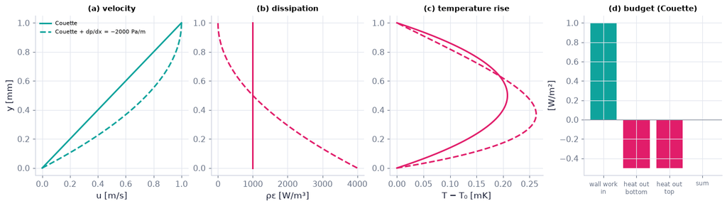

```python
yy = np.linspace(0, 1e-3, 201)                                       # across the gap [m]
fig, axs = plt.subplots(1, 4, figsize=(13, 3.6), gridspec_kw=dict(width_ratios=[1, 1, 1, 0.9]))    # the figure and its panels
for dpdx, ls, lab in ((0.0, "-", "Couette"), (-2000.0, "--", "Couette + dp/dx = −2000 Pa/m")):  # pure Couette and with a pressure gradient
    c = ch04.couette_heating(yy, U=1.0, h=1e-3, mu=1e-3, k=0.6, dpdx=dpdx)   # the steady heated flow
    axs[0].plot(c["u"], yy*1e3, ls, color=COLORS["teal"], label=lab)          # velocity
    axs[1].plot(c["eps"], yy*1e3, ls, color=COLORS["rose"])                    # ρε [W/m³]
    axs[2].plot((c["T"] - 293.15)*1e3, yy*1e3, ls, color=COLORS["rose"])       # T − T0 [mK]
axs[0].set_xlabel("u [m/s]"); axs[0].set_ylabel("y [mm]"); axs[0].legend(fontsize=7)                # axis labels with units
axs[1].set_xlabel("ρε [W/m³]"); axs[2].set_xlabel("T − T₀ [mK]")                                    # axis labels with units
c = ch04.couette_heating(yy, U=1.0, h=1e-3, mu=1e-3, k=0.6)            # the pure Couette budget
ins = axs[3]                                                          # panel (d): the energy budget of pure Couette flow
ins.bar([0, 1, 2, 3], [c["work_in"], -c["q_bottom"], -c["q_top"], c["work_in"] - c["heat_out"]],
        color=[COLORS["teal"], COLORS["rose"], COLORS["rose"], COLORS["ink"]])   # work in, heat out (bottom, top), sum
ins.set_xticks([0, 1, 2, 3], ["wall work\nin", "heat out\nbottom", "heat out\ntop", "sum"])   # label the four bars
ins.tick_params(axis="x", labelsize=8); ins.set_ylabel("[W/m²]"); ins.axhline(0, color=COLORS["muted"], lw=0.6)   # axis label, zero line
axs[0].set_title("(a) velocity", fontsize=10); axs[1].set_title("(b) dissipation", fontsize=10)     # the panel's message
axs[2].set_title("(c) temperature rise", fontsize=10); ins.set_title("(d) budget (Couette)", fontsize=10)   # the panels' messages
savefig(fig, "ch04", "couette_heating"); plt.show()                                        # save the PNG to outputs/ch04, then draw
```

**What you see.** A straight velocity profile, a flat dissipation strip, a parabolic temperature bump of a fifth of a millikelvin (solid); with the pressure gradient (dashed) the dissipation piles up near the lower wall and the bump shifts toward it.

**How to read it.** The moving wall pumps in 1 W per m²; all of it becomes heat inside and leaves by conduction through the two walls (the budget bars add to zero); the bump is where the heat has farthest to go.

**What would change if…** …oil instead of water (μ 100 × larger, k 4 × smaller): the bump is 400 × larger — 0.08 K — which is why bearings are cooled.

```python
yy = np.linspace(0, 1e-3, 101)                                       # across the gap [m]
def heating(U):                                                      # wall speed U [m/s]
    w = ch04.couette_heating(yy, U=U, h=1e-3, mu=1e-3, k=0.6)          # water
    o = ch04.couette_heating(yy, U=U, h=1e-3, mu=0.1, k=0.15)          # a light oil: μ ×100, k ÷4
    return {"oil T − T₀ [K]": (yy*1e3, o["T"] - 293.15), "water T − T₀ × 400 [K]": (yy*1e3, 400*(w["T"] - 293.15))}  # the curves for this slider value
fig = slider_figure(heating, "U", np.logspace(-1, 1, 20 if not FAST else 10), unit="m/s", xlabel="y [mm]",  # precompute every slider position (works on the web page)
                    ylabel="temperature rise [K]", title="Viscous heating grows as U² (water curve ×400 lies on the oil curve)")  # labels, title and a fixed range
recolor(fig, {"oil T − T₀ [K]": COLORS["rose"], "water T − T₀ × 400 [K]": COLORS["teal"]}, {"water T − T₀ × 400 [K]": "dash"}).show()  # house colours for each trace, then draw
```

[interactive chart not shown]

**What you see.** Two identical parabolas (water scaled by 400) that grow by a factor 100 when the slider moves from 1 to 10 m/s.

**How to read it.** The peak rise is $\mu U^2/(8k)$: at 10 m/s water warms by only 0.02 K, oil by 8 K; the shape never changes, only its size, as U².

**What would change if…** …the gap halved at the same U: the shear rate doubles but the path for the heat halves — the peak rise $\mu U^2/8k$ does not change.

#### 🎮 Interactive: Where does the energy go when viscosity stops a flow?

**Why interactive rather than a static figure:** the heating is a process in time — the temperature relaxes to its parabola while the energy bars fill — and changing fluid and wall speed shows the U² and μ/k scalings as you go.

A sheared channel on one clock: the velocity profile, the dissipation ε(y) of $\varepsilon=2\nu\big(S_{ij}-\tfrac13S_{mm}\delta_{ij}\big)^2+\frac{\mu_v}\rho S_{mm}^2$ (4.58), and the temperature relaxing to its steady parabola, with energy-budget bars (wall work in = heat out) and the entropy production. The start-up of the temperature is a sine series — the same method as Ch. 1's Couette start-up. A "negative μ" preset breaks the second law on purpose.

**What to try:**

- Water Couette at 1 m/s: read the peak temperature rise in Explain (2.1×10⁻⁴ K).
- Oil bearing preset: the same flow heats 400 times more.
- Press ▶ and watch T(y) grow to its steady ghost; the end card says shear work in = heat out.
- Preset 'negative μ': ε and the entropy production turn negative and the status flags the second law.

```python
show_viz("ch04", "viscous_dissipation_heating")   # full-width explainer; ⤢ Full screen for more room
```

🎮 Interactive 6/9 Where does the energy go when viscosity stops a flow? Open alone ↗

[interactive chart not shown]

**What would change if…** …the flow were frictionless and heat did not flow? Then ε = 0, q = 0, each particle keeps its entropy, and the energy and momentum equations can be integrated along streamlines — the Bernoulli family (C11, C12).

## 4.9 Special Forms of the Equations

**What is this section about?** Useful consequences of the equations under special conditions: the angular-momentum principle, four Bernoulli equations (each with its own hypotheses), gravity absorbed into the pressure, and the Boussinesq approximation that ocean and atmosphere models use.

*↪ The angular-momentum principle, $d\mathbf H/dt=\mathbf M$ (4.64) and its control-volume form (4.65), $\frac{d}{dt}\int_{V_o}(\mathbf r\times\rho\mathbf u)dV+\int_{A_o}(\mathbf r\times\rho\mathbf u)(\mathbf u\cdot\mathbf n)dA=\int_{V_o}(\mathbf r\times\rho\mathbf g)dV+\int_{A_o}(\mathbf r\times\mathbf f)dA$, with the lawn sprinkler (Ex. 4.6), was taught with the momentum budgets in C04 above (notes N82–N84).*

*↪ The pitot tube, $\lvert\mathbf u\rvert=\sqrt{2(p_2-p_1)/\rho}$, stagnation and dynamic pressure $p+\tfrac12\rho\lvert\mathbf u\rvert^2$, and the orifice $u=\sqrt{2gh}$ were taught with Bernoulli's equation $\tfrac12U^2+gz+p/\rho=$ const (4.19) in C05 above (notes N103–N105).*

### 🧩 Bernoulli is constant along what, exactly? (4.71) `C11`

*The question:* In a bathtub whirlpool the water surface dips in the middle, although every particle goes round at a steady speed. If Bernoulli held across the circles the surface would be level. Along what, exactly, is Bernoulli's sum constant?

*In one line:* $\tfrac12u_i^2+\int_{p_o}^{p}\frac{dp'}{\rho(p')}+gz=\text{const along streamlines and vortex lines}$ *(4.71)*

#### The problem in plain words

C05 derived Bernoulli along one streamline of a steady, frictionless, constant-density flow. People use it far more widely — across streamlines, in gases, in unsteady flows — sometimes correctly, sometimes not. We derive it again from Euler's equation, in a way that shows precisely what it is constant along, and why irrotational flows are special.

#### The idea

```
Euler + Lamb identity:   ∂u/∂t + ∇B = u × ω         B = ½u² + ∫dp/ρ + gz          (4.69)
steady:                  ∇B = u × ω   ⊥ u and ⊥ ω   →  B constant along streamlines AND vortex lines   (4.71)
irrotational (ω = 0):    ∇B = 0                     →  B constant everywhere                          (4.72)
```

*The numbered equations in the sketch:* $\frac{\partial u_j}{\partial t}+\frac{\partial}{\partial x_j}\Big[\tfrac12u_i^2+\int_{p_o}^{p}\frac{dp'}{\rho(p')}+gz\Big]=(\mathbf u\times\boldsymbol\omega)_j$ *(4.69)* · $\tfrac12u_i^2+\int_{p_o}^{p}\frac{dp'}{\rho(p')}+gz=\text{const along streamlines and vortex lines}$ *(4.71)* · $\tfrac12u_i^2+\int_{p_o}^{p}\frac{dp'}{\rho(p')}+gz=\text{const everywhere}$ *(4.72)*

📝 **Note.** **Bernoulli equations are not new laws** `N85` — each is a consequence of Navier–Stokes (4.38), $\rho\frac{Du_j}{Dt}=-\frac{\partial p}{\partial x_j}+\rho g_j+\frac{\partial}{\partial x_i}\Big[\mu\Big(\frac{\partial u_j}{\partial x_i}+\frac{\partial u_i}{\partial x_j}\Big)+\big(\mu_v-\tfrac23\mu\big)\frac{\partial u_m}{\partial x_m}\delta_{ij}\Big]$ or the energy equation (4.60), $\rho\frac{De}{Dt}=-p\frac{\partial u_m}{\partial x_m}+2\mu\big(S_{ij}-\tfrac13S_{mm}\delta_{ij}\big)^2+\mu_vS_{mm}^2+\frac{\partial}{\partial x_i}\Big(k\frac{\partial T}{\partial x_i}\Big)$ under stated conditions — so each comes with its own list of hypotheses (the table at the end of this block).

📝 **Note.** **Start from Euler's equation** `N86` — $\rho\frac{D\mathbf u}{Dt}=-\nabla p+\rho\mathbf g$ *(4.41)*, with gravity from its potential Φ = gz, $\mathbf g=-\nabla\Phi$ *(4.18)*:

$$ \frac{\partial u_j}{\partial t}+u_i\frac{\partial u_j}{\partial x_i}=-\frac1\rho\frac{\partial p}{\partial x_j}-\frac{\partial\Phi}{\partial x_j} \qquad \text{(4.66)} $$

> 🔁 **Tools from earlier chapters used here** (see `knowledge/primers.md`)
- **fundamental theorem of calculus with a variable limit** — $\frac{d}{dp}\int_{p_o}^{p}f(p')\,dp'=f(p)$ (Ch. 2 P84).

📝 **Note.** **Barotropic flow** `N87` — density a function of pressure alone, ρ = ρ(p) (constant density, isothermal gas, isentropic gas). Then dp/ρ is an exact differential and the line below holds (the fundamental theorem of calculus with a variable upper limit).

> ⚠️ The prime on p′ here is only the integration variable. Closed forms (`ch04.pressure_function`): constant ρ → (p − p_o)/ρ; isothermal → RT ln(p/p_o); isentropic → the enthalpy difference h − h_o. A *baroclinic* fluid (ρ depends on T too, like the real atmosphere) has no such single function — the root of Ch. 13's thermal wind.

$$ \frac1\rho\frac{\partial p}{\partial x_j}=\frac{\partial}{\partial x_j}\int_{p_o}^{p}\frac{dp'}{\rho(p')} \qquad \text{(4.67)} $$

> 🔁 **Tools from earlier chapters used here** (see `knowledge/primers.md`)
- **permutations and the alternating tensor ε_ijk** — $\varepsilon_{ijk}$ = +1 for cyclic (123), −1 for anticyclic, 0 with a repeat; $(\mathbf a\times\mathbf b)_i=\varepsilon_{ijk}a_jb_k$ (Ch. 2 P72).

#### 🧮 Derivation — The Bernoulli function: (4.66) + (4.67) + Lamb identity (4.68) → (4.69) `D24` (Eq. 4.69)

**What we want to show.** Rewrite Euler's equation so that every gradient is collected into one scalar B, leaving only ∂u/∂t and the Lamb vector u × ω — the book leaves the Lamb identity to Exercise 4.50.

**Assumptions.** Inviscid (the starting equation); barotropic ρ = ρ(p) (step 2); conservative body force (Φ).

**The plan.**

1. Write the pressure term as a gradient (barotropic).
2. Prove the Lamb identity with the ε–δ identity.
3. Substitute and collect the gradients.

**Tools we use** (each explained before this point): FTC with a variable upper limit (ch02 P84) and the chain rule · barotropic pressure function (N87) · alternating tensor and ε–δ (2.19), $\varepsilon_{ijk}\varepsilon_{klm}=\delta_{il}\delta_{jm}-\delta_{im}\delta_{jl}$ (ch02 P72, C08's primer) · conservative force (primer in C04).

**We start from**

$$ \text{(4.66):}\ \frac{\partial u_j}{\partial t}+u_i\frac{\partial u_j}{\partial x_i}=-\frac1\rho\frac{\partial p}{\partial x_j}-\frac{\partial\Phi}{\partial x_j} $$

*In words:* Euler's equation with gravity from its potential Φ = gz.

**Step 1 of 10 — Start from Euler with a potential.**

$$ \frac{\partial u_j}{\partial t}+u_i\frac{\partial u_j}{\partial x_i}=-\frac1\rho\frac{\partial p}{\partial x_j}-\frac{\partial\Phi}{\partial x_j} $$

- *Why we can do this:* (4.66), $\frac{\partial u_j}{\partial t}+u_i\frac{\partial u_j}{\partial x_i}=-\frac1\rho\frac{\partial p}{\partial x_j}-\frac{\partial\Phi}{\partial x_j}$: (4.41), $\rho\frac{D\mathbf u}{Dt}=-\nabla p+\rho\mathbf g$ divided by ρ with g = −∇Φ (4.18), $\mathbf g=-\nabla\Phi$, Φ = gz.
- *In words:* Acceleration = pressure push + gravity.

**Step 2 of 10 — Write the pressure term as a gradient.**

$$ \frac1\rho\frac{\partial p}{\partial x_j}=\frac{\partial}{\partial x_j}\int_{p_o}^{p}\frac{dp'}{\rho(p')} $$

- *Why we can do this:* Barotropic: ρ = ρ(p). Let P(p) = ∫dp′/ρ(p′); chain rule and FTC: ∂P/∂x_j = (1/ρ(p))∂p/∂x_j. This is (4.67), $\frac1\rho\frac{\partial p}{\partial x_j}=\frac{\partial}{\partial x_j}\int_{p_o}^{p}\frac{dp'}{\rho(p')}$ — the line above; p′ is only the integration variable.
- *In words:* In a barotropic fluid the pressure force per mass is a gradient.

**Step 3 of 10 — Write u × ω with ε.**

$$ (\mathbf u\times\boldsymbol\omega)_j=\varepsilon_{jkl}\,u_k\,\omega_l $$

- *Why we can do this:* Definition of the cross product with the alternating tensor (Ch. 2).
- *In words:* The Lamb vector in index form.

**Step 4 of 10 — Insert the vorticity.**

$$ (\mathbf u\times\boldsymbol\omega)_j=\varepsilon_{jkl}\varepsilon_{lmn}\,u_k\frac{\partial u_n}{\partial x_m} $$

- *Why we can do this:* ω_l = ε_lmn∂u_n/∂x_m (ω = ∇×u).
- *In words:* Two ε's in a row.

**Step 5 of 10 — Apply the ε–δ identity.**

$$ \varepsilon_{jkl}\varepsilon_{lmn}=\varepsilon_{ljk}\varepsilon_{lmn}=\delta_{jm}\delta_{kn}-\delta_{jn}\delta_{km} $$

- *Why we can do this:* Cyclic shift ε_jkl = ε_ljk, then (2.19), $\varepsilon_{ijk}\varepsilon_{klm}=\delta_{il}\delta_{jm}-\delta_{im}\delta_{jl}$ with the shared first index.
- *In words:* Two ε's become δ's.

**Step 6 of 10 — Substitute the δ's.**

$$ (\mathbf u\times\boldsymbol\omega)_j=u_k\frac{\partial u_k}{\partial x_j}-u_k\frac{\partial u_j}{\partial x_k} $$

- *Why we can do this:* δ_jmδ_kn: m = j, n = k; δ_jnδ_km: n = j, m = k (δ substitution).
- *In words:* The Lamb vector is a difference of two products of u and its gradient.

**Step 7 of 10 — Recognise a kinetic-energy gradient.**

$$ u_i\frac{\partial u_j}{\partial x_i}=-(\mathbf u\times\boldsymbol\omega)_j+\frac{\partial}{\partial x_j}\Big(\tfrac12u_iu_i\Big) $$

- *Why we can do this:* u_k∂u_k/∂x_j = ∂(½u_ku_k)/∂x_j (chain rule); rearrange step 6 and rename k as i. This is the Lamb identity (4.68), $u_i\frac{\partial u_j}{\partial x_i}=-(\mathbf u\times\boldsymbol\omega)_j+\frac{\partial}{\partial x_j}\big(\tfrac12u_i^2\big)$.
- *In words:* Advective acceleration = gradient of kinetic energy minus the Lamb vector.

**Step 8 of 10 — Substitute into Euler.**

$$ \frac{\partial u_j}{\partial t}-(\mathbf u\times\boldsymbol\omega)_j+\frac{\partial}{\partial x_j}\Big(\tfrac12u_i^2\Big)=-\frac{\partial}{\partial x_j}\int\frac{dp'}{\rho}-\frac{\partial(gz)}{\partial x_j} $$

- *Why we can do this:* Steps 2 and 7 in step 1, Φ = gz.
- *In words:* Every term but two is a gradient.

**Step 9 of 10 — Collect the gradients.**

$$ \frac{\partial u_j}{\partial t}+\frac{\partial}{\partial x_j}\Big[\tfrac12u_i^2+\int_{p_o}^{p}\frac{dp'}{\rho(p')}+gz\Big]=(\mathbf u\times\boldsymbol\omega)_j $$

- *Why we can do this:* Move the gradients left and u × ω right (linearity of the gradient). This is (4.69), $\frac{\partial u_j}{\partial t}+\frac{\partial}{\partial x_j}\Big[\tfrac12u_i^2+\int_{p_o}^{p}\frac{dp'}{\rho(p')}+gz\Big]=(\mathbf u\times\boldsymbol\omega)_j$ — the line above.
- *In words:* Acceleration plus the gradient of one bracket equals the Lamb vector.

**Step 10 of 10 — Name the Bernoulli function.**

$$ B\equiv\tfrac12u_i^2+\int_{p_o}^{p}\frac{dp'}{\rho(p')}+gz:\qquad\frac{\partial\mathbf u}{\partial t}+\nabla B=\mathbf u\times\boldsymbol\omega $$

- *Why we can do this:* One scalar collects kinetic energy, the pressure function and potential energy per unit mass.
- *In words:* The Bernoulli function B.

**Result**

$$ \frac{\partial u_j}{\partial t}+\frac{\partial}{\partial x_j}\big[\tfrac12u_i^2+\int_{p_o}^{p}\frac{dp'}{\rho(p')}+gz\big]=(\mathbf u\times\boldsymbol\omega)_j $$

*In words:* Euler's equation as "∂u/∂t + ∇B = u × ω".

**What it means.** The whole Bernoulli family follows (D25, D26); Ch. 5 starts the vorticity equation from (4.68), $u_i\frac{\partial u_j}{\partial x_i}=-(\mathbf u\times\boldsymbol\omega)_j+\frac{\partial}{\partial x_j}\big(\tfrac12u_i^2\big)$. Needs barotropy: in a baroclinic fluid (the real atmosphere) no single B exists — the root of thermal wind (Ch. 13).

**Check it.** Units m/s² ✓. Rankine core (r = 0.5 m, Γ = 2π, σ = 1; the vortex is worked with numbers further down this block): dB/dr = 2r = 1.0 and u_θω = 0.5 × 2 = 1.0 m/s² ✓. Lamb identity residual ≈ 0 at a point (C11 code); `ch04.lamb_identity_sym` returns zero vectors for a general 3-D field (the cell right after this derivation) ✓.

> ⚠️ **Common confusion (traps in `D24`):** The sign of u × ω. Reading p′ as a perturbation (it is a dummy variable). Using ∫dp/ρ for a fluid whose density depends on temperature too.

```python
x, y, z = sp.symbols('x y z')                                        # coordinates
u_any = [y**2*z, sp.sin(x)*z, x*y**3 + sp.exp(z)]                    # an arbitrary smooth 3-D velocity field
print(ch04.lamb_identity_sym(u_any, (x, y, z)))                      # (u·∇)u − [−u × ω + ∇(½u²)] = [0, 0, 0]
```

```
[0, 0, 0]
```

**What does the code above do?**

The Lamb identity $u_i\frac{\partial u_j}{\partial x_i}=-(\mathbf u\times\boldsymbol\omega)_j+\frac{\partial}{\partial x_j}(\tfrac12u_i^2)$ *(4.68)* checked symbolically for a general field (D24 steps 3–7); the numerical check at a point of the Rankine vortex follows below.

📝 **Note.** **The Lamb identity** `N88` — (D24 steps 3–7; the book leaves it to an exercise). The advective acceleration = gradient of the kinetic energy minus the "Lamb vector" u × ω. Ch. 5 starts the vorticity equation from here.

$$ u_i\frac{\partial u_j}{\partial x_i}=-(\mathbf u\times\boldsymbol\omega)_j+\frac{\partial}{\partial x_j}\big(\tfrac12u_i^2\big) \qquad \text{(4.68)} $$

📝 **Note.** **Euler in Bernoulli-function form** `N89` — (D24's result). The bracket is the **Bernoulli function** B (`ch04.bernoulli_function`).

$$ \frac{\partial u_j}{\partial t}+\frac{\partial}{\partial x_j}\Big[\tfrac12u_i^2+\int_{p_o}^{p}\frac{dp'}{\rho(p')}+gz\Big]=(\mathbf u\times\boldsymbol\omega)_j \qquad \text{(4.69)} $$

#### 🧮 Derivation — B is constant along streamlines and vortex lines, (4.70) → (4.71), (4.72) `D25` (Eq. 4.71)

**What we want to show.** Read off from (4.69), $\frac{\partial u_j}{\partial t}+\frac{\partial}{\partial x_j}\Big[\tfrac12u_i^2+\int_{p_o}^{p}\frac{dp'}{\rho(p')}+gz\Big]=(\mathbf u\times\boldsymbol\omega)_j$ exactly along what B is constant in steady flow — and when it is the same everywhere.

**Assumptions.** Steady (step 1); irrotational in a connected region (step 5).

**The plan.**

1. Steady flow.
2. Dot with u, then with ω.
3. Irrotational flow.

**Tools we use** (each explained before this point): Triple product with a repeated vector (gloss) · directional derivative (ch02 P75) · zero gradient ⇒ constant (gloss).

**We start from**

$$ \text{(4.69):}\ \frac{\partial\mathbf u}{\partial t}+\nabla B=\mathbf u\times\boldsymbol\omega\ \text{.} $$

**Step 1 of 5 — Make the flow steady.**

$$ \nabla B=\mathbf u\times\boldsymbol\omega $$

- *Why we can do this:* ∂u/∂t = 0. This is (4.70), $\nabla B=\mathbf u\times\boldsymbol\omega$ — the line above: ∇B is normal to the surfaces B = const, u × ω is perpendicular to both u and ω.
- *In words:* B's gradient is the Lamb vector.

**Step 2 of 5 — Dot with the velocity.**

$$ \mathbf u\cdot\nabla B=\mathbf u\cdot(\mathbf u\times\boldsymbol\omega)=0 $$

- *Why we can do this:* A triple product with a repeated vector vanishes (gloss): u × ω is perpendicular to u.
- *In words:* B does not change in the direction of the flow.

**Step 3 of 5 — Read it along a streamline.**

$$ \frac{dB}{ds}=\frac{\mathbf u}{\lvert\mathbf u\rvert}\cdot\nabla B=0 $$

- *Why we can do this:* The rate of change along the unit tangent of a streamline is the directional derivative (ch02 P75).
- *In words:* B is constant along each streamline.

**Step 4 of 5 — Dot with the vorticity.**

$$ \boldsymbol\omega\cdot\nabla B=0\ \Rightarrow\ \tfrac12u_i^2+\int_{p_o}^{p}\frac{dp'}{\rho(p')}+gz=\text{const along streamlines and vortex lines} $$

- *Why we can do this:* The same triple-product argument with ω. This is (4.71), $\tfrac12u_i^2+\int_{p_o}^{p}\frac{dp'}{\rho(p')}+gz=\text{const along streamlines and vortex lines}$ — the line above: each Lamb surface B = const contains both families of lines.
- *In words:* B is constant along vortex lines too — but may differ from line to line.

**Step 5 of 5 — Remove the vorticity.**

$$ \boldsymbol\omega=0\ \Rightarrow\ \nabla B=0\ \Rightarrow\ B=\text{const everywhere} $$

- *Why we can do this:* A zero gradient in a connected region means B is the same at every point (gloss). This is (4.72), $\tfrac12u_i^2+\int_{p_o}^{p}\frac{dp'}{\rho(p')}+gz=\text{const everywhere}$ — the line above.
- *In words:* In irrotational flow one Bernoulli constant holds for the whole flow.

**Result**

$$ \text{(4.71) and}\ \tfrac12u_i^2+\int_{p_o}^{p}\frac{dp'}{\rho(p')}+gz=\ \text{constant everywhere for ω = 0 (4.72).} $$

**What it means.** "Bernoulli holds across streamlines" is true only where the flow is irrotational — outside boundary layers (Ch. 6, 9). The constant along each streamline of a rotational flow is a label of that streamline.

> ⚠️ **Common confusion (traps in `D25`):** Using one constant across a rotational flow. Forgetting the connected-region condition (flow round an obstacle with circulation still has one B if ω = 0 everywhere in the fluid, but φ is multivalued).

📝 **Note.** **Steady flow** `N90` — ∇B is normal to the surfaces B = const, and u × ω is perpendicular to both u and ω, so each B-surface (a *Lamb surface*) is woven from streamlines and vortex lines. Picture: a Rankine vortex with an axial current — its Lamb surfaces are cylinders carrying helical streamlines and axial vortex lines.

$$ \nabla B=\mathbf u\times\boldsymbol\omega \qquad \text{(4.70)} $$

📝 **Note.** **Bernoulli 1 (steady, inviscid, barotropic, conservative body force)** `C11` — C11's result, restated.

$$ \tfrac12u_i^2+\int_{p_o}^{p}\frac{dp'}{\rho(p')}+gz=\text{constant along streamlines and vortex lines} \qquad \text{(4.71)} $$

📝 **Note.** **Irrotational as well** `N91` — (ω = 0 everywhere in a connected region): ∇B = 0 and B is one constant. Number (code below): B at about 900 random points of the Ch. 3 cylinder flow agrees to 1e-15; inside a Rankine core B varies from circle to circle.

$$ \tfrac12u_i^2+\int_{p_o}^{p}\frac{dp'}{\rho(p')}+gz=\text{constant everywhere} \qquad \text{(4.72)} $$

📝 **Note.** **Persistence of irrotationality** `N92` — An inviscid, barotropic flow in an inertial frame that starts irrotational stays irrotational (proved with Kelvin's circulation theorem in Ch. 5). That is why the flow outside a thin boundary layer round a body is irrotational and (4.72), $\tfrac12u_i^2+\int_{p_o}^{p}\frac{dp'}{\rho(p')}+gz=\text{const everywhere}$ applies there (Ch. 6, Ch. 9).

📝 **Note.** **Energy form** `N94` `N95` — start instead from the total-energy equation (4.55), $\rho\frac{D}{Dt}\big(e+\tfrac12u_j^2\big)=\rho g_iu_i+\Big(-p\frac{\partial u_j}{\partial x_j}+\sigma_{ij}\frac{\partial u_j}{\partial x_i}\Big)+\Big(-u_j\frac{\partial p}{\partial x_j}+u_j\frac{\partial\sigma_{ij}}{\partial x_i}\Big)-\frac{\partial q_i}{\partial x_i}$ with σ = q = 0 and steady flow; with $\mathbf g=-\nabla(gz)$ and steady continuity $\partial(\rho u_i)/\partial x_i=0$ it becomes the second line.

$$ \begin{aligned}\rho u_i\frac{\partial}{\partial x_i}\big(e+\tfrac12u_j^2\big)=\rho u_ig_i-\frac{\partial}{\partial x_j}\big(\rho u_j\tfrac p\rho\big)\quad&\text{(4.76)}\\ \rho u_i\frac{\partial}{\partial x_i}\big(e+\tfrac p\rho+\tfrac12u_j^2+gz\big)=0\quad&\text{(4.77)}\end{aligned} $$

📝 **Note.** **Bernoulli 3 (steady, inviscid, non-conducting; h = e + p/ρ)** `N96` — It is an *energy* statement: it holds in a gas where kinetic and thermal energy trade places. For isentropic flow dp/ρ = dh (Gibbs), so (4.71), $\tfrac12u_i^2+\int_{p_o}^{p}\frac{dp'}{\rho(p')}+gz=\text{const along streamlines and vortex lines}$ and (4.78) agree. Number: air at 300 K moving at 100 m/s brought to rest heats to $T_0=T+U^2/2C_p=300+10^4/2009=304.98$ K (Ch. 15).

$$ h+\tfrac12\lvert\mathbf u\rvert^2+gz=\text{const on streamlines} \qquad \text{(4.78)} $$

📝 **Note.** **Which Bernoulli? — a decision table** `N102` — (`ch04.BERNOULLI_FORMS`, `ch04.which_bernoulli`):

| form | steady? | inviscid? | irrotational? | barotropic / ρ const? | constant along |
| --- | --- | --- | --- | --- | --- |
| (4.19) $\tfrac12U^2+gz+p/\rho$ | yes | yes | not needed | ρ const | one streamline |
| (4.71) $\tfrac12u^2+\int dp/\rho+gz$ | yes | yes | not needed | barotropic | streamlines and vortex lines |
| (4.72), $\tfrac12u_i^2+\int_{p_o}^{p}\frac{dp'}{\rho(p')}+gz=\text{const everywhere}$ same B | yes | yes | yes | barotropic | everywhere |
| (4.75) $\frac{\partial\phi}{\partial t}+\tfrac12\lvert\nabla\phi\rvert^2+\int dp/\rho+gz$ | **unsteady allowed** | yes | yes | barotropic | everywhere (a function of t absorbed into φ) |
| (4.78) $h+\tfrac12\lvert\mathbf u\rvert^2+gz$ | yes | inviscid and non-conducting | not needed | any | streamlines |
| (4.82)/(4.83), $\frac{\partial\phi}{\partial t}+\tfrac12\lvert\nabla\phi\rvert^2+gz+\frac p\rho=\text{const}$ | unsteady | **viscous allowed** (ρ, μ const) | yes | ρ const | along a streamline at one instant / everywhere |

> 🔁 **Tools from earlier chapters used here** (see `knowledge/primers.md`)
- **polar coordinates as a moving basis** — $\mathbf e_r$, $\mathbf e_\theta$ turn with the point; for circular motion the radial balance is $dp/dr=\rho u_\theta^2/r$ (Ch. 3 P105).

#### ✏️ Tiny example: a Rankine vortex in water (Γ = 2π m²/s, core radius σ = 1 m, p∞ = 0)

1. Inside the core (r < σ) the fluid turns like a solid body: $u_\theta=\Gamma r/(2\pi\sigma^2)=r$ (s⁻¹ × m), vorticity ω = Γ/(πσ²) = 2 s⁻¹. Outside it is irrotational: $u_\theta=\Gamma/(2\pi r)=1/r$.
2. Pressure from the radial balance $dp/dr=\rho u_\theta^2/r$: outside p/ρ = −1/(2r²); inside p/ρ = −1 + r²/2 (matched at r = 1).
3. B = ½u_θ² + p/ρ: outside ½/r² − ½/r² = **0** everywhere; inside r²/2 − 1 + r²/2 = **r² − 1**: −1 at the centre, −0.75 at r = 0.5, 0 at the edge.
4. Along a circle (a streamline) B is constant — (4.71), $\tfrac12u_i^2+\int_{p_o}^{p}\frac{dp'}{\rho(p')}+gz=\text{const along streamlines and vortex lines}$ holds; across circles it changes inside the rotational core and not outside — $\tfrac12u_i^2+\int dp/\rho+gz$ = const everywhere (4.72), $\tfrac12u_i^2+\int_{p_o}^{p}\frac{dp'}{\rho(p')}+gz=\text{const everywhere}$ holds only where ω = 0.
5. Check D25: dB/dr = 2r = 1 at r = 0.5, and |u × ω| = u_θω = 0.5 × 2 = 1 ✓.

```python
r = np.array([0.0, 0.5, 1.0, 2.0, 4.0])                              # radii [m]
print(ch04.rankine_bernoulli(r, 2*np.pi, 1.0)["B"])                  # B = −1, −0.75, 0, 0, 0 m²/s²
u_rk = ch03.vortex_velocity_field("rankine", Gamma=2*np.pi, sigma=1.0)   # the Rankine vortex as a 2-D field u(x, t)
x0 = np.array([0.5, 0.0])                                            # a point inside the core [m]
print(ch04.lamb_vector(u_rk, x0)[:2], ch04.lamb_identity_terms(u_rk, x0)["residual"])   # u × ω = (1, 0) outward; residual ≈ 0
u_cyl = ch03.cylinder_velocity_field(1.0, 1.0)                        # Ch. 3's cylinder flow (U = 1 m/s, a = 1 m)
pts = np.random.default_rng(0).uniform(-3, 3, size=(2, 1000)); pts = pts[:, np.hypot(*pts) > 1.05]   # points outside the body
B = ch04.bernoulli_along_line(u_cyl, lambda x, t: ch04.exact_solution("cylinder", x, U=1.0, a=1.0, rho=1.0)[1],  # call the tested chapter function
                              pts, rho=1.0, g=0.0)                   # B at every point (pressure from the exact solution)
print(f"spread of B over {pts.shape[1]} points: {B.max() - B.min():.1e}")   # ≈ 1e-16: one constant (4.72)
print(ch04.which_bernoulli(steady=True, viscous=False, irrotational=False, barotropic=True))   # ['4.71']
print(round(ch04.pressure_function(2e5, 1e5, "isothermal", T=300.0), 1))   # RT ln 2 = 59692 J/kg for an isothermal gas
print(round(ch04.stagnation_temperature(300.0, 100.0), 2))            # 304.98 K (N96)
```

```
[-1.   -0.75  0.    0.    0.  ]
[1. 0.] [0. 0.]
spread of B over 901 points: 2.2e-16
['4.71']
59692.0
304.98
```

**What does the code above do?**

1. B across the vortex — varies inside, constant outside.
2. The Lamb identity at a point inside the core: u × ω points outward, equal to dB/dr = 1 m/s².
3. B at about 900 points of an irrotational flow — one constant.
4. The decision function for a steady, inviscid, barotropic rotational flow: only (4.71), $\tfrac12u_i^2+\int_{p_o}^{p}\frac{dp'}{\rho(p')}+gz=\text{const along streamlines and vortex lines}$.
5. An isothermal gas's pressure function $\int_{p_o}^{p}dp'/\rho(p')=RT\ln(p/p_o)$.
6. The energy form's stagnation temperature.

```python
w = kinematics.vorticity(u_rk, x0, 0.0)                              # ω by central differences: (0, 0, 2) 1/s
u3 = np.array([*u_rk(x0, 0.0), 0.0])                                 # u at the point, as a 3-vector
h = 1e-5                                                             # step for the kinetic-energy gradient [m]
ke = lambda x: 0.5*np.sum(u_rk(x, 0.0)**2)                           # ½|u|²
grad_ke = np.array([(ke(x0 + e) - ke(x0 - e))/(2*h) for e in np.eye(2)*h])   # ∇(½|u|²)
adv = kinematics.acceleration(u_rk, x0, 0.0).advective               # (u·∇)u
print(adv, -np.cross(u3, w)[:2] + grad_ke)                           # the two sides of the Lamb identity (4.68)
assert np.allclose(adv, -np.cross(u3, w)[:2] + grad_ke, atol=1e-6)
assert np.allclose(np.cross(u3, w)[:2], ch04.lamb_vector(u_rk, x0)[:2], atol=1e-6)   # the library's u × ω
```

```
[-0.5  0. ] [-0.5  0. ]
```

**What does the code above do?** It builds both sides of the Lamb identity at a point inside the Rankine core — (u·∇)u from the acceleration stencil, −u × ω + ∇(½|u|²) from `np.cross` and a central difference — and checks they agree with each other and with `ch04.lamb_vector`.

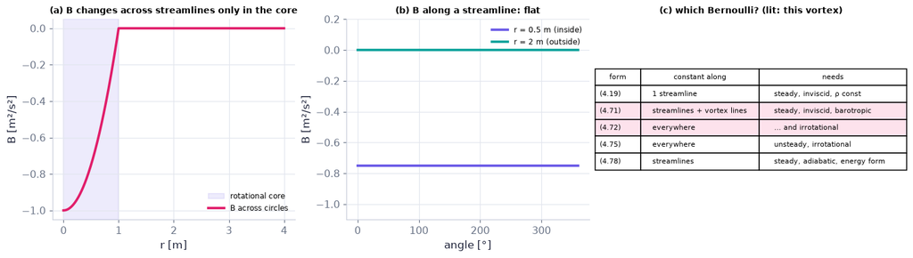

```python
rr = np.linspace(0, 4, 401)                                          # radius [m]
rb = ch04.rankine_bernoulli(rr, 2*np.pi, 1.0)                        # u_θ, p, B across the circles
fig, (a, b, c) = plt.subplots(1, 3, figsize=(13, 3.6), gridspec_kw=dict(width_ratios=[1.2, 1.2, 1.4]))  # the figure and its panels
a.axvspan(0, 1, color=COLORS["accent"], alpha=0.12, label="rotational core")   # the core
a.plot(rr, rb["B"], color=COLORS["rose"], lw=2.5, label="B across circles")                         # draw the data
a.set_xlabel("r [m]"); a.set_ylabel("B [m²/s²]"); a.legend(fontsize=8); a.set_title("(a) B changes across streamlines only in the core", fontsize=9)  # axis labels with units
phi = np.linspace(0, 2*np.pi, 181)                                   # angle round a circle
for rad, lab in ((0.5, "r = 0.5 m (inside)"), (2.0, "r = 2 m (outside)")):  # one circle inside the core, one outside
    P = np.array([rad*np.cos(phi), rad*np.sin(phi)])                # points on the circle
    Bc = ch04.bernoulli_along_line(u_rk, lambda x, t: ch04.rankine_vortex_pressure(np.hypot(*x), 2*np.pi, 1.0, rho=1.0), P, rho=1.0, g=0.0)  # call the tested chapter function
    b.plot(np.rad2deg(phi), Bc, lw=2.5, label=lab)                  # B along one streamline
b.set_ylim(-1.1, 0.2); b.set_xlabel("angle [°]"); b.set_ylabel("B [m²/s²]"); b.legend(fontsize=8)   # axis labels with units
b.set_title("(b) B along a streamline: flat", fontsize=9)                                        # the panel's message
c.axis("off")                                                        # the decision table, (4.71) and (4.72) lit
rows = [["(4.19)", "1 streamline", "steady, inviscid, ρ const"], ["(4.71)", "streamlines + vortex lines", "steady, inviscid, barotropic"],  # the table's rows
        ["(4.72)", "everywhere", "… and irrotational"], ["(4.75)", "everywhere", "unsteady, irrotational"],  # table row
        ["(4.78)", "streamlines", "steady, adiabatic, energy form"]]                                # table row
tb = c.table(cellText=rows, colLabels=["form", "constant along", "needs"], loc="center", cellLoc="left",
             colWidths=[0.16, 0.42, 0.52])                           # a small table drawn in the panel
tb.auto_set_font_size(False); tb.set_fontsize(7); tb.scale(1, 1.4)   # small font so every entry fits
for k in (2, 3):                                                     # light the rows this vortex illustrates
    for j in range(3):  # column j of τ
        tb[k, j].set_facecolor("#fde2ec")
c.set_title("(c) which Bernoulli? (lit: this vortex)", fontsize=9)                                  # the panel's message
savefig(fig, "ch04", "rankine_bernoulli"); plt.show()                                        # save the PNG to outputs/ch04, then draw
```

**What you see.** (a) A parabola inside the core joining a flat line outside; (b) two flat lines; (c) the decision table with two rows lit.

**How to read it.** Along any streamline B is constant (4.71), $\tfrac12u_i^2+\int_{p_o}^{p}\frac{dp'}{\rho(p')}+gz=\text{const along streamlines and vortex lines}$; across streamlines it changes only where there is vorticity — outside the core the flow is irrotational and one B holds everywhere (4.72), $\tfrac12u_i^2+\int_{p_o}^{p}\frac{dp'}{\rho(p')}+gz=\text{const everywhere}$. The whirlpool's dip is exactly the core's B deficit.

**What would change if…** …a uniform flow instead: B would be one constant everywhere; the whirlpool needs vorticity for its dip.

```python
rr = np.linspace(0, 4, 300)                                          # radius [m]
def rankine(sig):                                                    # core radius σ [m], Γ = 2π m²/s
    rb = ch04.rankine_bernoulli(rr, 2*np.pi, sig)                                        # call the tested chapter function
    return {"B(r) [m²/s²]": (rr, rb["B"]), "u_θ(r) [m/s]": (rr, rb["u_theta"])}                     # the curves for this slider value
fig = slider_figure(rankine, "σ", np.linspace(0.2, 2.0, 19 if not FAST else 10), unit="m", xlabel="r [m]",  # precompute every slider position (works on the web page)
                    ylabel="B [m²/s²] · u_θ [m/s]", title="Rotational core: B varies across streamlines only where ω ≠ 0",  # labels, title and a fixed range
                    yrange=(-26, 6))                                        # labels, title and a fixed range
recolor(fig, {"B(r) [m²/s²]": COLORS["rose"], "u_θ(r) [m/s]": COLORS["teal"]}).show()               # house colours for each trace, then draw
```

[interactive chart not shown]

**What you see.** A rose dip inside the core and a teal speed profile peaking at the core's edge.

**How to read it.** Shrinking σ deepens the dip, $B(0)=-\Gamma^2/(4\pi^2\sigma^2)$, and narrows it; outside the core B is zero whatever σ is.

**What would change if…** …Γ doubled: the speed doubles and the dip deepens four times (B ∝ Γ²).

**What would change if…** …the flow were irrotational but unsteady — water sloshing in a U-tube, a balloon pushed suddenly through water? Then the ∂u/∂t term of (4.69), $\frac{\partial u_j}{\partial t}+\frac{\partial}{\partial x_j}\Big[\tfrac12u_i^2+\int_{p_o}^{p}\frac{dp'}{\rho(p')}+gz\Big]=(\mathbf u\times\boldsymbol\omega)_j$ stays, but it is a gradient too, and a new Bernoulli equation holds everywhere at each instant (C12).

> 🔁 **Recap — Velocity potential** (Ch. 3 §3.4). An irrotational flow (ω = ∇×u = 0) in a simply connected region can be written as the gradient of a scalar, $\mathbf u\equiv\nabla\phi$ *(Eq. 4.73, first met as $\boldsymbol\omega=0$ (3.17) in Ch. 3)*, because the curl of a gradient is zero. φ is defined up to an added constant — or an added function of time only, which changes no velocity.

### 🧩 Unsteady Bernoulli: the pressure of an accelerating flow (4.75) `C12`

*The question:* Water sloshes back and forth in a U-tube. At the instant the column is momentarily still, the pressures at the two ends still differ. Why — and by how much?

*In one line:* $\frac{\partial\phi}{\partial t}+\tfrac12\lvert\nabla\phi\rvert^2+\int_{p_o}^{p}\frac{dp'}{\rho(p')}+gz=\text{const}$ *(4.75)*

#### The problem in plain words

Steady Bernoulli says pressure is high where flow is slow. In an accelerating flow that is not enough: pushing fluid to speed it up takes a pressure difference even at zero speed. Water waves (Ch. 7), a body starting to move (its "added mass", Ch. 6), a bubble collapsing and sound (Ch. 15) all need the unsteady form — valid everywhere, but only for irrotational flow.

#### The idea

```
u = ∇φ  →  Lamb term vanishes, ∂u/∂t = ∇(∂φ/∂t)  →  ∇[∂φ/∂t + ½|∇φ|² + ∫dp/ρ + gz] = 0
       →  the bracket is the same everywhere: a function of time B(t) only  →  absorb it into φ  →  (4.75)
U-tube:  p₁ − p₂ = ρ L dU/dt   (the ∂φ/∂t term, amber, carries the difference when U = 0)
```

*The numbered equations in the sketch:* $\frac{\partial\phi}{\partial t}+\tfrac12\lvert\nabla\phi\rvert^2+\int_{p_o}^{p}\frac{dp'}{\rho(p')}+gz=\text{const}$ *(4.75)*

#### 🧮 Derivation — Unsteady Bernoulli for potential flow: (4.73) → (4.74) → (4.75) `D26` (Eq. 4.75)

**What we want to show.** In an irrotational flow keep the time derivative and still get a Bernoulli equation valid everywhere — and fix the sign of the book's redefinition of φ.

**Assumptions.** Inviscid, barotropic (from D24); irrotational in a simply connected region (step 1).

**The plan.**

1. Write u = ∇φ and make ∂u/∂t a gradient.
2. Collect everything under one gradient: the bracket depends on t only.
3. Absorb that function into φ with the correct sign.

**Tools we use** (each explained before this point): Velocity potential (R09) · Schwarz's theorem (primer in C08) · zero gradient ⇒ function of t only (gloss).

**We start from**

$$ \text{(4.69) with ω = 0:}\ \frac{\partial\mathbf u}{\partial t}+\nabla\Big[\tfrac12u_i^2+\int_{p_o}^{p}\frac{dp'}{\rho(p')}+gz\Big]=0\ \text{.} $$

**Step 1 of 8 — Use the velocity potential.**

$$ \mathbf u=\nabla\phi $$

- *Why we can do this:* (4.73), $\mathbf u\equiv\nabla\phi$, R09: an irrotational flow in a simply connected region is the gradient of a potential.
- *In words:* The velocity is the slope of φ.

**Step 2 of 8 — Swap time and space derivatives.**

$$ \frac{\partial\mathbf u}{\partial t}=\frac{\partial}{\partial t}\nabla\phi=\nabla\frac{\partial\phi}{\partial t} $$

- *Why we can do this:* Schwarz's theorem (mixed derivatives commute for smooth φ).
- *In words:* The acceleration term is a gradient too.

**Step 3 of 8 — Insert into (4.69) with ω = 0.**

$$ \nabla\frac{\partial\phi}{\partial t}+\nabla\Big[\tfrac12\lvert\nabla\phi\rvert^2+\int_{p_o}^{p}\frac{dp'}{\rho}+gz\Big]=0 $$

- *Why we can do this:* In (4.69), $\frac{\partial u_j}{\partial t}+\frac{\partial}{\partial x_j}\Big[\tfrac12u_i^2+\int_{p_o}^{p}\frac{dp'}{\rho(p')}+gz\Big]=(\mathbf u\times\boldsymbol\omega)_j$ the right side u × ω vanishes because ω = 0; u_iu_i = |∇φ|².
- *In words:* Two gradients add to zero.

**Step 4 of 8 — Collect under one gradient.**

$$ \nabla\Big[\frac{\partial\phi}{\partial t}+\tfrac12\lvert\nabla\phi\rvert^2+\int_{p_o}^{p}\frac{dp'}{\rho(p')}+gz\Big]=0 $$

- *Why we can do this:* Linearity of the gradient. This is the first form of (4.74), $\frac{\partial\phi}{\partial t}+\tfrac12\lvert\nabla\phi\rvert^2+\int_{p_o}^{p}\frac{dp'}{\rho(p')}+gz=B(t)$.
- *In words:* One bracket has no spatial variation.

**Step 5 of 8 — Integrate in space.**

$$ \frac{\partial\phi}{\partial t}+\tfrac12\lvert\nabla\phi\rvert^2+\int_{p_o}^{p}\frac{dp'}{\rho(p')}+gz=B(t) $$

- *Why we can do this:* A zero gradient everywhere means the bracket is the same at every point, but it may still change with time (gloss). The second form of (4.74), $\frac{\partial\phi}{\partial t}+\tfrac12\lvert\nabla\phi\rvert^2+\int_{p_o}^{p}\frac{dp'}{\rho(p')}+gz=B(t)$.
- *In words:* The bracket is a function of time only.

**Step 6 of 8 — Shift φ by a function of time.**

$$ \phi_{new}=\phi-\int_{t_o}^{t}B(t')\,dt' $$

- *Why we can do this:* The added term has no x-dependence, so ∇φ_new = ∇φ (same velocity); ∂φ_new/∂t = ∂φ/∂t − B. The book prints +∫B dt′, which makes the bracket 2B(t): a sign slip.
- *In words:* Re-label the potential without changing the flow.

**Step 7 of 8 — Substitute the shifted potential.**

$$ \frac{\partial\phi_{new}}{\partial t}+\tfrac12\lvert\nabla\phi_{new}\rvert^2+\int_{p_o}^{p}\frac{dp'}{\rho(p')}+gz=B(t)-B(t)=0 $$

- *Why we can do this:* Step 6 in step 5: the time function cancels.
- *In words:* The time function is gone.

**Step 8 of 8 — Drop the label.**

$$ \frac{\partial\phi}{\partial t}+\tfrac12\lvert\nabla\phi\rvert^2+\int_{p_o}^{p}\frac{dp'}{\rho(p')}+gz=\text{constant} $$

- *Why we can do this:* Rename φ_new as φ; any constant may stand on the right (a constant shift of B changes nothing). This is (4.75), $\frac{\partial\phi}{\partial t}+\tfrac12\lvert\nabla\phi\rvert^2+\int_{p_o}^{p}\frac{dp'}{\rho(p')}+gz=\text{const}$ — the line above.
- *In words:* Unsteady Bernoulli holds everywhere at every instant.

**Result**

$$ \frac{\partial\phi}{\partial t}+\tfrac12\lvert\nabla\phi\rvert^2+\int_{p_o}^{p}\frac{dp'}{\rho(p')}+gz=\ \text{constant (4.75).} $$

**What it means.** The pressure of an accelerating irrotational flow: Ch. 7's dynamic free-surface condition, added mass of accelerating bodies (Ch. 6), bubbles and acoustics (Ch. 15). It needs irrotationality — unlike (4.71), $\tfrac12u_i^2+\int_{p_o}^{p}\frac{dp'}{\rho(p')}+gz=\text{const along streamlines and vortex lines}$.

**Check it.** Units m²/s² ✓. Steady: reduces to (4.72), $\tfrac12u_i^2+\int_{p_o}^{p}\frac{dp'}{\rho(p')}+gz=\text{const everywhere}$ ✓. U-tube (L = 1 m): p₁ − p₂ = ρL dU/dt = 981 Pa at the turning point = ρg·2h₀ ✓. sympy gauge check (C12): minus sign → 0, plus sign → 2B(t) ✓.

> ⚠️ **Common confusion (traps in `D26`):** The gauge sign (φ − ∫B dt′). Believing the constant cannot depend on time before it is absorbed. Using it in a rotational flow (no φ exists).

📝 **Note.** **The book's (4.74)** `N93` — D26 steps 4–5.

> ⚠️ **Book slip (sign):** to absorb B(t) the potential must be redefined as $\phi\to\phi-\int_{t_o}^{t}B(t')dt'$; the printed "+" makes the bracket 2B(t) instead of 0 (step 6 and the code below). The result (4.75), $\frac{\partial\phi}{\partial t}+\tfrac12\lvert\nabla\phi\rvert^2+\int_{p_o}^{p}\frac{dp'}{\rho(p')}+gz=\text{const}$ is unaffected; the velocity ∇φ does not change either way.

$$ \nabla\Big[\frac{\partial\phi}{\partial t}+\tfrac12\lvert\nabla\phi\rvert^2+\int_{p_o}^{p}\frac{dp'}{\rho(p')}+gz\Big]=0,\quad\text{or}\quad\frac{\partial\phi}{\partial t}+\tfrac12\lvert\nabla\phi\rvert^2+\int_{p_o}^{p}\frac{dp'}{\rho(p')}+gz=B(t) \qquad \text{(4.74)} $$

📝 **Note.** **Bernoulli 2 (unsteady, inviscid, irrotational, barotropic)** `C12` — C12's result, restated. Ch. 7 applies it at the free surface of every water wave.

$$ \frac{\partial\phi}{\partial t}+\tfrac12\lvert\nabla\phi\rvert^2+\int_{p_o}^{p}\frac{dp'}{\rho(p')}+gz=\text{const} \qquad \text{(4.75)} $$

📝 **Note.** **Viscosity too?** `N97` — Put the Lamb identity (4.68), $u_i\frac{\partial u_j}{\partial x_i}=-(\mathbf u\times\boldsymbol\omega)_j+\frac{\partial}{\partial x_j}\big(\tfrac12u_i^2\big)$ and the viscous force $-\mu\nabla\times\boldsymbol\omega$ of $\mu\nabla^2\mathbf u=-\mu\nabla\times\boldsymbol\omega$ *(4.40)* into (4.39b):

$$ \rho\frac{\partial\mathbf u}{\partial t}+\rho\nabla\big(\tfrac12\lvert\mathbf u\rvert^2\big)-\rho\mathbf u\times\boldsymbol\omega=-\nabla p+\rho\mathbf g-\mu\nabla\times\boldsymbol\omega \qquad \text{(4.79)} $$

📝 **Note.** **With ω = 0 and constant ρ** `N98` — **both** the Lamb term and the viscous term vanish — viscosity is present but exerts no net force on an irrotational flow. Code: `ch04.viscous_irrotational_residual(u_cyl, (1.5, 0.7))` → 0 to round-off (printed below). (Viscosity still *dissipates* energy in such a flow — ε ≠ 0 — which damps water waves slowly, Ch. 7.)

$$ \rho\frac{\partial\mathbf u}{\partial t}+\nabla\big(\tfrac12\rho\lvert\mathbf u\rvert^2+\rho gz+p\big)=0 \qquad \text{(4.80)} $$

> 🔁 **Tools from earlier chapters used here** (see `knowledge/primers.md`)
- **directional derivative along a streamline** — $\partial F/\partial s=\hat{\mathbf s}\cdot\nabla F$, the rate of change of F along the unit tangent (Ch. 2 P75).

📝 **Note.** **Along a streamline** `N99` — Dot (4.80), $\rho\frac{\partial\mathbf u}{\partial t}+\nabla\big(\tfrac12\rho\lvert\mathbf u\rvert^2+\rho gz+p\big)=0$ with a line element ds along a streamline and integrate from point 1 to point 2:

$$ \int_1^2\frac{\partial\mathbf u}{\partial t}\cdot d\mathbf s+\int_1^2\frac{\partial}{\partial s}\big(\tfrac12\lvert\mathbf u\rvert^2+gz+\tfrac p\rho\big)ds=0 \qquad \text{(4.81)} $$

📝 **Note.** **Bernoulli 4 (constant ρ and μ, irrotational, along a streamline at one instant)** `N100` — Number: a water column L = 1 m long accelerating at dU/dt = 1 m/s² along a straight tube needs p₁ − p₂ = ρL dU/dt = 1000 Pa, even at the instant U = 0.

$$ \int_1^2\frac{\partial\mathbf u}{\partial t}\cdot d\mathbf s+\big(\tfrac12\lvert\mathbf u\rvert^2+gz+\tfrac p\rho\big)_2=\big(\tfrac12\lvert\mathbf u\rvert^2+gz+\tfrac p\rho\big)_1 \qquad \text{(4.82)} $$

📝 **Note.** **In potential form** `N101` — (u = ∇φ, swap ∂/∂t and ∇) — the constant-ρ (4.75), $\frac{\partial\phi}{\partial t}+\tfrac12\lvert\nabla\phi\rvert^2+\int_{p_o}^{p}\frac{dp'}{\rho(p')}+gz=\text{const}$, now shown to hold with constant viscosity as well.

$$ \frac{\partial\phi}{\partial t}+\tfrac12\lvert\nabla\phi\rvert^2+gz+\frac p\rho=\text{const} \qquad \text{(4.83)} $$

#### ✏️ Tiny example: the U-tube and an accelerating sphere

1. **U-tube:** a water column of length L = 1 m with its two surfaces displaced ±h oscillates at ω = √(2g/L) = 4.43 rad/s (period 1.42 s). At the instant the column is still (U = 0) its acceleration is largest: with h₀ = 5 cm, dU/dt = ω²h₀ = 19.62 × 0.05 = 0.98 m/s², and (4.82), $\int_1^2\frac{\partial\mathbf u}{\partial t}\cdot d\mathbf s+(\tfrac12\lvert\mathbf u\rvert^2+gz+\tfrac p\rho)_2=(\dots)_1$, gives p₁ − p₂ = ρL dU/dt = 1000 × 1 × 0.98 = 981 Pa — exactly the weight of the 2h₀ = 10 cm height difference, ρg(2h₀) = 981 Pa ✓.
2. **Sphere** of radius a = 0.1 m accelerating from rest at 1 m/s² through still water: the unsteady term gives a surface pressure ½ρa cos θ dU/dt (high in front, low behind) whose net force is −½ρV dU/dt, V = 4πa³/3 = 4.19×10⁻³ m³: the sphere must push as if it carried half its volume of water with it — "added mass" 2.09 kg, force 2.09 N (Ch. 6).

```python
c = ch04.u_tube_column(np.array([0.0, 0.3547, 0.7093]), L=1.0, h0=0.05)   # t = 0, a quarter and a half period [s]
print(np.round(c["h"], 4), np.round(c["U"], 4), np.round(c["dUdt"], 3), np.round(c["dp"], 1))   # level, speed, acceleration, p1 − p2
print(ch04.unsteady_streamline_bernoulli(np.full(11, 1.0), np.linspace(0, 1, 11), {"U": 0.0, "z": 0.0, "p": 1000.0},  # evenly spaced values
                                         {"U": 0.0, "z": 0.0, "p": 0.0}))   # residual of (4.82): 0 — 1000 Pa is what the acceleration needs
s = ch04.accelerating_sphere_pressure(np.array([0.0, np.pi/2, np.pi]), a=0.1, dUdt=1.0)   # front, side, back of the sphere
print(np.round(s["p"], 3), round(s["force"], 3), round(s["added_mass"], 3))   # +50, 0, −50 Pa; −2.094 N; 2.094 kg
print(ch04.gauge_absorbed_bracket(3.0, sign=-1.0), ch04.gauge_absorbed_bracket(3.0, sign=+1.0))   # 0.0 and 6.0: the printed + doubles B
print(ch04.viscous_irrotational_residual(u_cyl, np.array([1.5, 0.7]), mu=1e-3))   # −μ∇×ω ≈ 0: no net viscous force (N98)
```

```
[ 0.05 -0.   -0.05] [-0.     -0.2215  0.    ] [-0.981  0.     0.981] [-981.     0.3  981. ]
0.0
[ 50.   0. -50.] -2.094 2.094
0.0 6.0
[ 0. -0.]
```

**What does the code above do?**

1. The column's level, speed, acceleration and the pressure difference that drives it (signs as in the function's docstring: h = h₀ cos ωt, U = dh/dt): the pressure difference is largest (±981 Pa) when the column stops.
2. The streamline form (4.82), $\int_1^2\frac{\partial\mathbf u}{\partial t}\cdot d\mathbf s+\big(\tfrac12\lvert\mathbf u\rvert^2+gz+\tfrac p\rho\big)_2=\big(\tfrac12\lvert\mathbf u\rvert^2+gz+\tfrac p\rho\big)_1$ balanced by ρL dU/dt.
3. The unsteady surface pressure on the sphere and the added-mass force.
4. The gauge sign test of (4.74), $\frac{\partial\phi}{\partial t}+\tfrac12\lvert\nabla\phi\rvert^2+\int_{p_o}^{p}\frac{dp'}{\rho(p')}+gz=B(t)$: the minus sign absorbs B(t) = 3; the printed plus leaves 2B = 6.
5. Viscosity exerts no net force on an irrotational flow.

```python
t = sp.symbols('t')                                                  # time
phi = sp.Function('phi')(t); Bt = sp.Function('B')(t)                # the potential (its time part) and the bracket's value B(t)
rest = Bt - sp.diff(phi, t)                                          # everything in the bracket except ∂φ/∂t, so ∂φ/∂t + rest = B(t)
new_minus = sp.diff(phi - sp.Integral(Bt, t), t) + rest              # bracket after φ → φ − ∫B dt (our sign)
new_plus = sp.diff(phi + sp.Integral(Bt, t), t) + rest               # bracket after φ → φ + ∫B dt (the printed sign); sp.Integral is an unevaluated ∫
print(sp.simplify(new_minus), sp.simplify(new_plus))                 # 0 and 2*B(t)
assert sp.simplify(new_minus) == 0 and sp.simplify(new_plus - 2*Bt) == 0
assert np.isclose(ch04.gauge_absorbed_bracket(3.0, -1.0), 0.0)       # the library agrees
```

```
0 2*B(t)
```

```python
L_, h0 = 1.0, 0.05                                                   # column length [m], initial displacement [m]
frames = 60 if not FAST else 30                                        # number of frames (halved when FAST)
tt = np.linspace(0, 2*np.pi/np.sqrt(2*9.81/L_), frames)             # one period [s]
col = ch04.u_tube_column(tt, L=L_, h0=h0)                            # h(t), U(t), dU/dt, p1 − p2
fig, (a, b) = plt.subplots(1, 2, figsize=(7.5, 3.6), gridspec_kw=dict(width_ratios=[1, 1.1]), dpi=80)  # the figure and its panels
a.plot([0, 0, 1, 1], [0.4, 0, 0, 0.4], color=COLORS["ink"], lw=3); a.plot([0.25, 0.25, 0.75, 0.75], [0.4, 0.25, 0.25, 0.4], color=COLORS["ink"], lw=3)  # draw the data
(left,) = a.plot([], [], color=COLORS["blue"], lw=16, solid_capstyle="butt")   # water in the left leg
(right,) = a.plot([], [], color=COLORS["blue"], lw=16, solid_capstyle="butt")  # water in the right leg
a.fill_between([0, 1], 0, 0.25, color=COLORS["blue"], alpha=0.6)    # the bottom of the U (always full)
a.set_xlim(-0.2, 1.2); a.set_ylim(0, 0.45); a.axis("off"); a.set_title("water in a U-tube", fontsize=9)  # the panel's message
bar = b.bar([0], [0], color=COLORS["amber"], width=0.5)[0]           # p1 − p2 = ρL dU/dt (the ∂φ/∂t part)
b.axhline(0, ls="--", color=COLORS["muted"], label="steady Bernoulli at U = 0: p1 − p2 = 0")        # a reference line
b.set_xlim(-1, 1); b.set_ylim(-1100, 1100); b.set_xticks([]); b.set_ylabel("p1 − p2 [Pa]"); b.legend(fontsize=7, loc="lower right")  # axis labels with units
txt = b.text(-0.95, 950, "", fontsize=8)                                        # a label on the plot


def update(i):                                                       # draw frame i
    h = col["h"][i]                                                  # left level up by h, right down by h [m]
    left.set_data([0.125, 0.125], [0.25, 0.32 + 0.6*h]); right.set_data([0.875, 0.875], [0.25, 0.32 - 0.6*h])   # levels (drawn ×0.6)
    bar.set_height(col["dp"][i])                                     # pressure difference that accelerates the column
    txt.set_text(f"U = {col['U'][i]:+.3f} m/s   dU/dt = {col['dUdt'][i]:+.3f} m/s²")                # move this artist to the new frame
    return left, right, bar  # the artists that changed in this frame


show_animation(animate(update, frames=frames, fig=fig, interval=50))                                # build the movie from update() and play it
```

[video not shown]

**What you see.** The amber bar is largest when the column stops at the top of its swing and zero when it moves fastest.

**How to read it.** The pressure difference tracks the acceleration, not the speed — the ∂φ/∂t term of $\frac{\partial\phi}{\partial t}+\tfrac12\lvert\nabla\phi\rvert^2+\int\frac{dp}{\rho}+gz=$ const *(4.75)*, invisible in any steady Bernoulli (whose prediction, the grey line, would be zero whenever U = 0).

**What would change if…** …a column twice as long: ω falls by √2, and for the same h₀ the bar keeps its size (ρL dU/dt = 2ρgh₀) — the weight of the height difference.

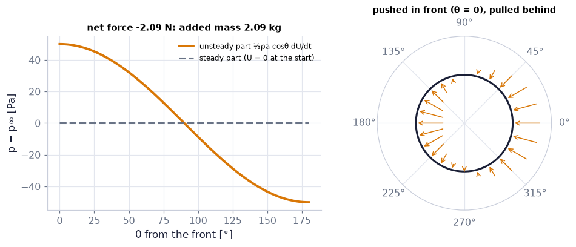

```python
th = np.linspace(0, np.pi, 181)                                      # angle from the front of the sphere [rad]
s = ch04.accelerating_sphere_pressure(th, a=0.1, dUdt=1.0)            # unsteady surface pressure, starting from rest [Pa]
fig = plt.figure(figsize=(9, 3.6))                                        # an empty figure
a = fig.add_subplot(1, 2, 1)                                        # a panel
a.plot(np.rad2deg(th), s["p"], color=COLORS["amber"], lw=2.5, label="unsteady part ½ρa cosθ dU/dt")  # draw the data
a.plot(np.rad2deg(th), 0*th, "--", color=COLORS["muted"], label="steady part (U = 0 at the start)")  # draw the data
a.set_xlabel("θ from the front [°]"); a.set_ylabel("p − p∞ [Pa]"); a.legend(fontsize=8)             # axis labels with units
a.set_title(f"net force {s['force']:.2f} N: added mass {s['added_mass']:.2f} kg", fontsize=10)      # the panel's message
b = fig.add_subplot(1, 2, 2, projection="polar")                    # pressure arrows round the sphere
tq = np.linspace(0, 2*np.pi, 24, endpoint=False)                                        # evenly spaced values
pq = ch04.accelerating_sphere_pressure(np.abs(np.angle(np.exp(1j*tq))), a=0.1, dUdt=1.0)["p"]   # same formula round the circle
b.plot(np.linspace(0, 2*np.pi, 200), np.ones(200), color=COLORS["ink"])                             # draw the data
for t_, p_ in zip(tq, pq):                                           # inward arrow where p > 0, outward where p < 0
    b.annotate("", (t_, 1.0), (t_, 1.0 + 0.012*p_), arrowprops=dict(arrowstyle="->", color=COLORS["amber"]))  # a labelled arrow
b.set_ylim(0, 1.8); b.set_yticks([]); b.set_title("pushed in front (θ = 0), pulled behind", fontsize=9)  # the panel's message
savefig(fig, "ch04", "sphere_added_mass"); plt.show()                                        # save the PNG to outputs/ch04, then draw
```

**What you see.** A cosine: pushed in front, pulled behind.

**How to read it.** Summed over the surface it resists the acceleration like extra mass: half the displaced water.

**What would change if…** …the sphere moving at steady speed: the amber curve vanishes and the steady Bernoulli pressure 1 − (9/4)sin²θ times ½ρU² remains, symmetric front to back — no net force (d'Alembert's paradox, Ch. 6).

#### 🎮 Interactive: Bernoulli is constant along what, exactly?

**Why interactive rather than a static figure:** whether a Bernoulli form holds depends on the hypotheses you grant and on where you put the two probes; toggling them yourself shows which constant survives, which a fixed table cannot show.

Six scenarios — pitot tube, tank orifice, Rankine vortex, cylinder, U-tube, hot-gas nozzle — each with its streamlines, two probes, and B plotted along and across streamlines as stacked bars (½u², p/ρ, gz, ∂φ/∂t). Toggle the hypotheses and the status picks the valid equation: $\tfrac12U^2+gz+p/\rho$ (4.19), the Bernoulli function (4.71)/(4.72), $\tfrac12u_i^2+\int_{p_o}^{p}\frac{dp'}{\rho(p')}+gz=\text{const everywhere}$, the unsteady form $\frac{\partial\phi}{\partial t}+\tfrac12\lvert\nabla\phi\rvert^2+\int dp/\rho+gz$ (4.75) or the energy form $h+\tfrac12\lvert\mathbf u\rvert^2+gz$ (4.78).

**What to try:**

- Rankine vortex: B is flat along each circle but not across the core — the status says '(4.71), $\tfrac12u_i^2+\int_{p_o}^{p}\frac{dp'}{\rho(p')}+gz=\text{const along streamlines and vortex lines}$ along streamlines only'.
- Cylinder: B is flat everywhere ((4.72)); drag the probes anywhere.
- U-tube: stop the column (U = 0) — the amber ∂φ/∂t bar carries the pressure difference ((4.75)).
- Hot nozzle: B of (4.71) with ρ = const fails; the energy form $h+\tfrac12\lvert\mathbf u\rvert^2+gz$ (4.78) stays flat.

```python
show_viz("ch04", "which_bernoulli")   # full-width explainer; ⤢ Full screen for more room
```

🎮 Interactive 7/9 Bernoulli is constant along what, exactly? Open alone ↗

[interactive chart not shown]

**What would change if…** …the density varied a little from place to place, as in a lake warmed at the top? Then gravity no longer cancels into the pressure, and a small density difference, multiplied by the large g, drives motion — the Boussinesq approximation (C13).

> 🔁 **Recap — Hydrostatic balance** (Ch. 1 §1.7). A fluid at rest in gravity has $0=-\nabla p_s+\rho_s\mathbf g$ — pressure increases downward at the rate ρ_s g (Ch. 1, $dp/dz=-\rho g$ *(1.8)*). ρ_s(z) and p_s(z) may vary with height (a stratified reference state).

```python
z = np.linspace(0, -100, 5)                                          # depths 0 … 100 m in seawater [m]
print(np.round(statics.integrate_hydrostatic(z, lambda z, p: 1025.0, 1.013e5, g=9.81)))   # p(z) with g = 9.81 as elsewhere: +1 atm about every 10 m [Pa]
```

```
[ 101300.  352681.  604062.  855444. 1106825.]
```

### 🧩 Boussinesq: density matters only where it meets gravity (4.86) `C13`

*The question:* A lake is 2 °C warmer at the top than at the bottom — its density changes by less than one part in a thousand. Yet that tiny difference stops the wind from mixing the lake. Why does such a small density change matter so much, and when may we ignore it?

*In one line:* $\frac{D\mathbf u}{Dt}=-\frac1{\rho_0}\nabla p'+\frac{\rho'}{\rho_0}\mathbf g+\nu\nabla^2\mathbf u$ *(4.86)*

#### The problem in plain words

In the ocean and the atmosphere, density varies by a percent or less, but those variations drive the overturning circulation, sea breezes, convection and internal waves. Solving the full compressible equations for them is wasteful (and fills the solution with sound waves). Boussinesq's idea keeps the density variation in exactly one place — where it is multiplied by g — and treats the fluid as incompressible everywhere else. It is the equation set of Ch. 7's internal waves, Ch. 11's convection and Ch. 13's ocean and atmosphere.

#### The idea

```
ρ = ρ₀ + ρ'   with  ρ'/ρ₀ ~ αδT ~ 10⁻³
inertia   ρ Du/Dt  ≈ ρ₀ Du/Dt           (error 10⁻³: drop ρ')
gravity   ρ g      = ρ_s g + ρ' g         (ρ_s g balanced by the hydrostatic p_s; ρ' g KEPT: g ≫ Du/Dt)
continuity  ∇·u ≈ 0;   heat  DT/Dt = κ∇²T  (pressure work turns C_v into C_p)
```

> 📎 **Primer — order-of-magnitude scaling.** `P130` · To compare terms of an equation without solving it, replace each quantity by its typical size: a velocity varying by U over a distance L has ∂u/∂x ~ U/L and ∂²u/∂x² ~ U/L²; a temperature varying by δT has ∂T/∂x ~ δT/L. Ratios of such estimates tell which terms can be dropped (≪ 1) — the method of C13 and C15.

```python
U, L, nu = 0.1, 1.0, 1e-6                         # a lake current [m/s], its scale [m], water's ν [m²/s]
advective = U**2/L; viscous = nu*U/L**2           # (u·∇)u ~ U²/L,  ν∇²u ~ νU/L²
print(advective, viscous, advective/viscous)      # 0.01, 1e-07, 1e5 = Re
```

```
0.010000000000000002 1e-07 100000.00000000003
```

> 📎 **Primer — reduced gravity and buoyancy.** `P131` · A parcel lighter than its surroundings by Δρ feels a net upward force per unit mass g′ = gΔρ/ρ₀ — gravity *reduced* by the density contrast. The buoyancy b = −gρ′/ρ₀ (upward positive) is the same idea as a field. For a density contrast of 10⁻³, g′ ≈ 0.01 m/s²: small, but it acts on the whole mass and for as long as the contrast lasts. N² = ∂b/∂z is the buoyancy frequency of Ch. 1.

```python
rho0, d_rho = 1000.0, -0.4                          # a parcel 0.4 kg/m³ lighter than 1000 kg/m³ water
print(ch04.buoyancy(d_rho, rho0), 9.81*0.4/1000)    # +0.003924 m/s² upward, both ways
```

```
0.003924 0.003924
```

📝 **Note.** **Subtract the hydrostatic state** `N106` — (R10) from $\rho\frac{D\mathbf u}{Dt}=-\nabla p+\rho\mathbf g+\mu\nabla^2\mathbf u$ *(4.39b)*; with p′ = p − p_s and ρ′ = ρ − ρ_s:

> ⚠️ **Primes again**: here p′ and ρ′ are departures from the hydrostatic state — not the rotating frame of C09, not the dummy variable of (4.67), $\frac1\rho\frac{\partial p}{\partial x_j}=\frac{\partial}{\partial x_j}\int_{p_o}^{p}\frac{dp'}{\rho(p')}$.

$$ \rho\frac{D\mathbf u}{Dt}=-\nabla p'+\rho'\mathbf g+\mu\nabla^2\mathbf u \qquad \text{(4.84)} $$

📝 **Note.** **Constant density** `N107` — ρ′ = 0 and gravity disappears from the equation of motion. Gravity returns as soon as there is a free surface, an interface or any density variation. Demo below: the Poiseuille velocity in a channel with gravity along −y solves (4.39b), $\rho\frac{D\mathbf u}{Dt}=-\nabla p+\rho\mathbf g+\mu\nabla^2\mathbf u$ with p including −ρgy, and (4.85) with p′ alone.

$$ \rho\frac{D\mathbf u}{Dt}=-\nabla p'+\mu\nabla^2\mathbf u \qquad \text{(4.85)} $$

```python
u_g, p_g = ch04.exact_field("poiseuille", G=100.0, h=1e-3, mu=1e-3, g=9.81)   # p = −Gx − ρgy: hydrostatic part included
X0 = np.array([0.0, 2.5e-4, 0.0])                                    # a point in the gap
full = ch04.ns_incompressible_terms(u_g, p_g, X0, 0.0, rho=1000.0, mu=1e-3, g=np.array([0, -9.81, 0]), per="volume")   # (4.39b) with g
p_prime = lambda x, t: p_g(x, t) + 1000.0*9.81*x[1]                  # p' = p − p_s: remove the hydrostatic part ρgy
pert = ch04.ns_incompressible_terms(u_g, p_prime, X0, 0.0, rho=1000.0, mu=1e-3, g=np.zeros(3), per="volume")   # (4.85): no g
print(full.pressure, full.gravity, full.residual)                    # pressure (100, 9810, 0) balances gravity (0, −9810, 0)
print(pert.pressure, pert.gravity, pert.residual)                    # (100, 0, 0), no gravity at all, residual ≈ 0
```

```
[ 100. 9810.   -0.] [    0. -9810.     0.] [0. 0. 0.]
[100.  -0.  -0.] [0. 0. 0.] [0. 0. 0.]
```

📝 **Note.** **When Boussinesq holds** `N108` — (stated; the scaling chain is the book's): low Mach number and no sound; a vertical scale L ≪ c²/g (the height over which hydrostatic compression changes the density — ≈ 11.8 km for air at 288 K); and small temperature differences, αδT ≪ 1, because then the ratio below is small and continuity reduces to ∇·u = 0. The code below computes the three small numbers for five situations (`ch04.boussinesq_validity`): only the deep atmosphere fails.

$$ \frac{(1/\rho)(D\rho/Dt)}{\nabla\cdot\mathbf u}\sim\frac{(U/\rho)(\delta\rho/L)}{U/L}=\frac{\delta\rho}{\rho}=\alpha\,\delta T\ll1 $$

> 🔁 **Tools from earlier chapters used here** (see `knowledge/primers.md`)
- **perfect gas p = ρRT, R = C_p − C_v, α = 1/T** — for a perfect gas $p=\rho RT$, $R=C_p-C_v$ and the expansion coefficient $\alpha=-\frac1\rho(\partial\rho/\partial T)_p=1/T$ (Ch. 1 P33).

#### 🧮 Derivation — The Boussinesq momentum equation: (4.39b) − hydrostatics → (4.84) → (4.86) `D27` (Eq. 4.86)

**What we want to show.** Show why small density differences can be ignored in the fluid's inertia but not where they are multiplied by gravity.

**Assumptions.** Density changes small, ρ′/ρ_s ~ αδT ≪ 1 (step 6); g ≫ the flow's own accelerations (step 7); base-state variation small (step 8); constant μ.

**The plan.**

1. Subtract the hydrostatic reference state.
2. Divide by ρ_s.
3. Compare sizes: drop ρ′ in the inertia, keep it with g.
4. Replace ρ_s by a constant.

**Tools we use** (each explained before this point): Hydrostatic reference state (R10) · order-of-magnitude scaling (primer in C13) · reduced gravity (primer in C13).

**We start from**

$$ \text{(4.39b):}\ \rho\frac{D\mathbf u}{Dt}=-\nabla p+\rho\mathbf g+\mu\nabla^2\mathbf u\ \text{.} $$

**Step 1 of 9 — Start from Navier–Stokes.**

$$ \rho\frac{D\mathbf u}{Dt}=-\nabla p+\rho\mathbf g+\mu\nabla^2\mathbf u $$

- *Why we can do this:* (4.39b), $\rho\frac{D\mathbf u}{Dt}=-\nabla p+\rho\mathbf g+\mu\nabla^2\mathbf u$, the incompressible equation (continuity is ∇·u = 0 to order αδT, N108).
- *In words:* Newton's law for the fluid.

**Step 2 of 9 — Write the resting state.**

$$ 0=-\nabla p_s+\rho_s\mathbf g $$

- *Why we can do this:* R10: a fluid at rest balances pressure against gravity; p_s(z) and ρ_s(z) may vary with height.
- *In words:* The hydrostatic balance.

**Step 3 of 9 — Subtract the resting state.**

$$ \rho\frac{D\mathbf u}{Dt}=-\nabla(p-p_s)+(\rho-\rho_s)\mathbf g+\mu\nabla^2\mathbf u $$

- *Why we can do this:* Subtracting zero; the large hydrostatic parts cancel.
- *In words:* Only departures from rest drive motion.

**Step 4 of 9 — Name the departures.**

$$ \rho\frac{D\mathbf u}{Dt}=-\nabla p'+\rho'\mathbf g+\mu\nabla^2\mathbf u,\qquad p'=p-p_s,\ \rho'=\rho-\rho_s $$

- *Why we can do this:* This is (4.84), $\rho\frac{D\mathbf u}{Dt}=-\nabla p'+\rho'\mathbf g+\mu\nabla^2\mathbf u$ — the line above; primes now mean perturbations (a new meaning of ′).
- *In words:* Perturbation pressure and density.

**Step 5 of 9 — Divide by ρ_s.**

$$ \frac{\rho}{\rho_s}\frac{D\mathbf u}{Dt}=-\frac1{\rho_s}\nabla p'+\frac{\rho'}{\rho_s}\mathbf g+\frac{\mu}{\rho_s}\nabla^2\mathbf u $$

- *Why we can do this:* To compare the sizes of the terms per unit mass (the book's move).
- *In words:* Every term an acceleration.

**Step 6 of 9 — Estimate the density ratio.**

$$ \frac{\rho}{\rho_s}=1+\frac{\rho'}{\rho_s},\qquad\frac{\rho'}{\rho_s}\sim\alpha\,\delta T\sim10^{-3} $$

- *Why we can do this:* Order-of- magnitude scaling (primer): δρ/ρ = αδT for thermal density changes (water, δT = 5 K: 10⁻³).
- *In words:* Density differs from its resting value by a tenth of a percent.

**Step 7 of 9 — Keep ρ′ only with g.**

$$ \Big(1+\frac{\rho'}{\rho_s}\Big)\frac{D\mathbf u}{Dt}\approx\frac{D\mathbf u}{Dt},\qquad\frac{\rho'}{\rho_s}\mathbf g\ \text{kept} $$

- *Why we can do this:* The book skips why: ρ′Du/Dt/ρ_s is 10⁻³ of Du/Dt — negligible; but ρ′g/ρ_s is compared with the other accelerations, and g ≫ |Du/Dt|, so it is as large as they are.
- *In words:* Tiny density differences matter only through gravity.

**Step 8 of 9 — Replace ρ_s by a constant ρ₀.**

$$ \frac1{\rho_s}\approx\frac1{\rho_0},\qquad\frac{\mu}{\rho_0}=\nu $$

- *Why we can do this:* The base state varies by a similarly small fraction over the depth (L ≪ c²/g); ρ₀ is a reference value, and μ/ρ₀ is the kinematic viscosity.
- *In words:* One constant density everywhere except in the buoyancy.

**Step 9 of 9 — Write the Boussinesq momentum equation.**

$$ \frac{D\mathbf u}{Dt}=-\frac1{\rho_0}\nabla p'+\frac{\rho'}{\rho_0}\mathbf g+\nu\nabla^2\mathbf u $$

- *Why we can do this:* Steps 7–8 in step 5. This is (4.86), $\frac{D\mathbf u}{Dt}=-\frac1{\rho_0}\nabla p'+\frac{\rho'}{\rho_0}\mathbf g+\nu\nabla^2\mathbf u$ — the line above.
- *In words:* Density appears only in the buoyancy term.

**Result**

$$ \frac{D\mathbf u}{Dt}=-\frac1{\rho_0}\nabla p'+\frac{\rho'}{\rho_0}\mathbf g+\nu\nabla^2\mathbf u $$

*In words:* the Boussinesq momentum equation.

**What it means.** The momentum equation of the ocean and atmosphere models of Ch. 13, of internal waves (Ch. 7) and convection (Ch. 11). It fails when density differences are large (αδT ~ 1) or the layer is as deep as c²/g.

**Check it.** Units m/s² ✓. ρ′ = 0: gravity disappears (4.85), $\rho\frac{D\mathbf u}{Dt}=-\nabla p'+\mu\nabla^2\mathbf u$ ✓. Lake: buoyancy g′ = 0.0196 m/s² for δT = 10 K (C13) ✓; dropped term 10⁻³ of the inertia ✓.

> ⚠️ **Common confusion (traps in `D27`):** Dropping ρ′ everywhere (no buoyancy, no convection). Keeping ρ′ in the inertia (inconsistent order). Confusing p′ (perturbation) with the rotating frame's primes.

📝 **Note.** **The Boussinesq momentum equation** `C13` — C13's momentum equation, restated. ρ₀ is a constant reference density. In buoyant convection the term ρ′g/ρ₀ is as large as ∂w/∂t or ν∇²w.

$$ \frac{D\mathbf u}{Dt}=-\frac1{\rho_0}\nabla p'+\frac{\rho'}{\rho_0}\mathbf g+\nu\nabla^2\mathbf u \qquad \text{(4.86)} $$

📝 **Note.** **The energy equation (4.60), $\rho\frac{De}{Dt}=-p\frac{\partial u_m}{\partial x_m}+2\mu\big(S_{ij}-\tfrac13S_{mm}\delta_{ij}\big)^2+\mu_vS_{mm}^2+\frac{\partial}{\partial x_i}\Big(k\frac{\partial T}{\partial x_i}\Big)$ in vector form** `N109` — the start of D28:

$$ \rho\frac{De}{Dt}=-p\nabla\cdot\mathbf u+\rho\varepsilon-\nabla\cdot\mathbf q \qquad \text{(4.87)} $$

#### 🧮 Derivation — The Boussinesq heat equation: (4.87) → (4.88) → (4.89) `D28` (Eq. 4.89)

**What we want to show.** Show why the Boussinesq heat equation has C_p (not C_v) although continuity is ∇·u ≈ 0, and reach DT/Dt = κ∇²T.

**Assumptions.** Density changes caused by temperature alone (step 3); perfect gas (steps 4–5; liquids: see the trap); low Eckert number (step 7); constant k (step 8).

**The plan.**

1. Express the pressure work through continuity and the thermal expansion.
2. Use perfect-gas relations to turn it into ρ(C_p − C_v)DT/Dt.
3. Move it left: C_v → C_p.
4. Drop viscous heating, use Fourier.

**Tools we use** (each explained before this point): Continuity (4.8), $\frac{1}{\rho}\frac{D\rho}{Dt}+\nabla\cdot\mathbf u=0$ (C02) · thermal expansion coefficient α (Ch. 1 §1.9) · perfect gas p = ρRT, R = C_p − C_v, α = 1/T (ch01 P33) · order-of-magnitude scaling (primer in C13) · Fourier's law (Ch. 1 §1.5).

**We start from**

$$ \text{(4.87):}\ \rho\frac{De}{Dt}=-p\nabla\cdot\mathbf u+\rho\varepsilon-\nabla\cdot\mathbf q $$

*In words:* (4.60), $\rho\frac{De}{Dt}=-p\frac{\partial u_m}{\partial x_m}+2\mu\big(S_{ij}-\tfrac13S_{mm}\delta_{ij}\big)^2+\mu_vS_{mm}^2+\frac{\partial}{\partial x_i}\Big(k\frac{\partial T}{\partial x_i}\Big)$, the internal-energy equation, in vector form.

**Step 1 of 8 — Start from the energy equation.**

$$ \rho\frac{De}{Dt}=-p\nabla\cdot\mathbf u+\rho\varepsilon-\nabla\cdot\mathbf q $$

- *Why we can do this:* (4.87), $\rho\frac{De}{Dt}=-p\nabla\cdot\mathbf u+\rho\varepsilon-\nabla\cdot\mathbf q$: (4.60), $\rho\frac{De}{Dt}=-p\frac{\partial u_m}{\partial x_m}+2\mu\big(S_{ij}-\tfrac13S_{mm}\delta_{ij}\big)^2+\mu_vS_{mm}^2+\frac{\partial}{\partial x_i}\Big(k\frac{\partial T}{\partial x_i}\Big)$ with ε inserted. We keep −p∇·u: although ∇·u ≈ 0 in continuity, p is large.
- *In words:* Internal energy: compression work, viscous heating, conduction.

**Step 2 of 8 — Replace ∇·u with continuity.**

$$ -p\nabla\cdot\mathbf u=\frac p\rho\frac{D\rho}{Dt} $$

- *Why we can do this:* Continuity (4.8), $\frac{1}{\rho}\frac{D\rho}{Dt}+\nabla\cdot\mathbf u=0$ gives ∇·u = −(1/ρ)Dρ/Dt; multiply both sides by −p.
- *In words:* The tiny expansion, written with the density rate.

**Step 3 of 8 — Let temperature set the density.**

$$ \frac{D\rho}{Dt}=\Big(\frac{\partial\rho}{\partial T}\Big)_p\frac{DT}{Dt}=-\rho\alpha\frac{DT}{Dt} $$

- *Why we can do this:* With pressure effects negligible (L ≪ c²/g), ρ changes with T; α = −(1/ρ)(∂ρ/∂T)_p (1.20), $\alpha=-\frac1\rho\Big(\frac{\partial\rho}{\partial T}\Big)_p$.
- *In words:* Warming a particle lowers its density.

**Step 4 of 8 — Use the perfect gas.**

$$ -p\nabla\cdot\mathbf u=-p\alpha\frac{DT}{Dt}=-\rho RT\cdot\frac1T\frac{DT}{Dt}=-\rho R\frac{DT}{Dt} $$

- *Why we can do this:* p = ρRT and α = 1/T for a perfect gas (ch01 P33).
- *In words:* The pressure work is ρR times the warming rate.

**Step 5 of 8 — Use R = C_p − C_v.**

$$ -p\nabla\cdot\mathbf u=-\rho(C_p-C_v)\frac{DT}{Dt} $$

- *Why we can do this:* Mayer's relation for a perfect gas (Ch. 1 §1.8).
- *In words:* It is the difference of the two specific heats, times the warming rate.

**Step 6 of 8 — Move the pressure work left, e = C_vT.**

$$ \rho C_v\frac{DT}{Dt}+\rho(C_p-C_v)\frac{DT}{Dt}=\rho C_p\frac{DT}{Dt}=\rho\varepsilon-\nabla\cdot\mathbf q $$

- *Why we can do this:* de = C_v dT for a perfect gas; adding ρ(C_p − C_v)DT/Dt to both sides turns C_v into C_p. This is (4.88), $\rho C_p\frac{DT}{Dt}=\rho\varepsilon-\nabla\cdot\mathbf q$ — the line above.
- *In words:* The small expansion's work is what makes the heat capacity C_p.

**Step 7 of 8 — Drop the viscous heating.**

$$ \frac{\rho\varepsilon}{\rho C_p(DT/Dt)}\sim\frac{\nu U}{C_p\,\delta T\,L}\ll1 $$

- *Why we can do this:* Order-of-magnitude scaling (N112): water, U = 0.1 m/s, L = 1 m, δT = 1 K gives ~2×10⁻¹¹ — the low-Eckert condition of C15.
- *In words:* Friction heating is far too small to matter here.

**Step 8 of 8 — Use Fourier's law, constant k.**

$$ \frac{DT}{Dt}=\kappa\nabla^2T,\qquad\kappa\equiv\frac{k}{\rho C_p} $$

- *Why we can do this:* q = −k∇T (1.2), $\mathbf q=-k\nabla T$ with uniform k gives −∇·q = k∇²T; divide by ρC_p. This is (4.89), $\frac{DT}{Dt}=\kappa\nabla^2T$ — the line above.
- *In words:* Temperature is carried by the flow and diffuses.

**Result**

$$ \rho C_p\frac{DT}{Dt}=\rho\varepsilon-\nabla\cdot\mathbf q\ \text{(4.88) and}\ \frac{DT}{Dt}=\kappa\nabla^2T\ \text{(4.89).} $$

**What it means.** The heat (and, with salinity, density) equation of ocean and atmosphere models. C_p appears because a warming parcel expands a little against a large pressure.

**Check it.** Units K/s ✓. U = 0: the heat equation of Ch. 1 ✓. The Gaussian blob with σ² = σ₀² + 2κt solves it exactly (C13 code, residual ≈ 0) ✓. sympy (the cell after note N110 below): e = C_vT, p = ρRT, α = 1/T ⇒ ρC_v DT/Dt + p∇·u = ρC_p DT/Dt ✓.

> ⚠️ **Common confusion (traps in `D28`):** Writing C_v because "∇·u = 0". For liquids the argument is different: p∇·u is small but C_p ≈ C_v anyway — the ocean uses (4.89), $\frac{DT}{Dt}=\kappa\nabla^2T$ with water's C_p. Dropping ρε in a fast lubricating flow (high Eckert number: the oil-bearing preset of the `viscous_dissipation_heating` explainer).

📝 **Note.** **Why C_p and not C_v** `N110` — (D28 steps 2–6): although ∇·u ≈ 0 in continuity, the pressure work p∇·u is *not* negligible in the energy equation, because p is large: for a perfect gas $-p\nabla\cdot\mathbf u\cong-p\alpha\frac{DT}{Dt}=-\rho(C_p-C_v)\frac{DT}{Dt}$. It moves to the left and turns ρC_v DT/Dt into ρC_p DT/Dt.

> ⚠️ For liquids the argument is different: p∇·u is small, but C_p ≈ C_v anyway, so the ocean uses the same equation with water's C_p.

```python
rho, T, R, Cp, DTDt = sp.symbols('rho T R C_p DT_Dt', positive=True)  # density, temperature, gas constant, C_p, the rate DT/Dt
Cv = Cp - R                                                          # perfect gas: R = C_p − C_v
p = rho*R*T                                                          # perfect-gas law p = ρRT
alpha = 1/T                                                          # its expansion coefficient α = −(1/ρ)(∂ρ/∂T)_p = 1/T
div_u = -(1/rho)*(-rho*alpha*DTDt)                                   # ∇·u = −(1/ρ)Dρ/Dt with Dρ/Dt = −ρα DT/Dt (D28 steps 2–3)
lhs = rho*Cv*DTDt + p*div_u                                          # ρ De/Dt + p∇·u with e = C_v T (step 6)
print(sp.simplify(lhs - rho*Cp*DTDt))                                # 0: the pressure work turns ρC_v into ρC_p
```

```
0
```

**What does the code above do?**

The D28 check in sympy: with e = C_vT, p = ρRT and α = 1/T, ρC_v DT/Dt + p∇·u equals ρC_p DT/Dt exactly.

📝 **Note.** **Heat equation with C_p** `N111`

$$ \rho C_p\frac{DT}{Dt}=\rho\varepsilon-\nabla\cdot\mathbf q \qquad \text{(4.88)} $$

📝 **Note.** **Viscous heating is negligible under Boussinesq conditions** `N112` — Water, U = 0.1 m/s, L = 1 m, δT = 1 K: 10⁻⁷/4186 ≈ 2×10⁻¹¹ (the book's "typical" value is 10⁻⁷ — tiny either way). This is the low-Eckert-number condition of C15.

$$ \frac{\rho\varepsilon}{\rho C_p(DT/Dt)}\sim\frac{2\mu S_{ij}S_{ij}}{\rho C_pu_i(\partial T/\partial x_i)}\sim\frac{\mu U^2/L^2}{\rho C_pU(\delta T/L)}=\frac{\nu U}{C_p\,\delta T\,L} $$

📝 **Note.** **The Boussinesq heat equation** `N113` — (D28's result), κ = k/ρC_p. Exact test solution (the animation below): a warm Gaussian blob carried by a uniform current U and spreading, $T'=T_a(\sigma_0/\sigma)^2\exp(-\lvert\mathbf x-\mathbf Ut\rvert^2/2\sigma^2)$ in 2-D with $\sigma^2=\sigma_0^2+2\kappa t$.

$$ \frac{DT}{Dt}=\kappa\nabla^2T \qquad \text{(4.89)} $$

📝 **Note.** **The Boussinesq set** `N114` — (boxed): continuity $\nabla\cdot\mathbf u=0$ *(4.10)*; momentum (4.86), $\frac{D\mathbf u}{Dt}=-\frac1{\rho_0}\nabla p'+\frac{\rho'}{\rho_0}\mathbf g+\nu\nabla^2\mathbf u$ with $\mathbf g=-g\mathbf e_z$; heat (4.89), $\frac{DT}{Dt}=\kappa\nabla^2T$; and a linear equation of state (below) with ρ′ = −ρ₀α(T − T₀), so the buoyancy is b = −gρ′/ρ₀ = gα(T − T₀) and the stratification $N^2=\partial b/\partial z=g\alpha\,dT/dz$ (Kundu's Γ ≡ dT/dz; in the meteorological convention Γ_met = −dT/dz, N² = −gαΓ_met). For seawater, salinity enters too (`ch01.seawater_density_linear`). The Coriolis term is omitted here — Ch. 13 adds it back.

$$ \rho=\rho_0\big[1-\alpha(T-T_0)\big] $$

#### ✏️ Tiny example: three Boussinesq numbers

One set of water numbers throughout: α = 2×10⁻⁴ K⁻¹, a warm layer δT = 10 K above cold water (this is the code's `"thermocline"` row below; the question's lake, δT = 2 K, has αδT = 4×10⁻⁴, and the code's gentler `"lake"` row uses α = 1.5×10⁻⁴, δT = 5 K).

> 🔁 **Tools from earlier chapters used here** (see `knowledge/primers.md`)
- **np.where** — `np.where(cond, a, b)` picks a where cond is true, b elsewhere (Ch. 1 P46).

```python
for name in ("lake", "thermocline", "lab_tank", "abl", "deep_atmosphere"):   # five real situations
    p = ch04.boussinesq_scenario(name)                                # fluid, α, δT, L, U, ν, c_p, c
    v = ch04.boussinesq_validity(p["alpha"], p["dT"], p["L"], p["U"], c=p["c"], nu=p["nu"], cp=p["cp"])   # the three small numbers
    print(f"{name:16s} αδT={v['alpha_dT']:.1e}  L/(c²/g)={v['L_over_Hc']:.2e}  heating={v['heating_ratio']:.1e}"  # show the numbers
          f"  g'={v['g_prime']:.3g} m/s²  → {v['verdict']}")
print(ch04.boussinesq_density(303.15, 1000.0, 2e-4, 293.15), ch04.buoyancy(-2.0, 1000.0))   # 998.0 kg/m³; +0.0196 m/s² upward
Tb = lambda x, t: ch04.gaussian_blob_advection_diffusion(x, t, U=np.array([0.01, 0.0]), kappa=1e-4, sigma0=0.05)   # a warm blob T'(x, t)
ub = lambda x, t: np.array([0.01, 0.0])                              # the uniform current carrying it [m/s]
print(ch04.temperature_equation_residual(Tb, ub, np.array([0.02, 0.01]), 10.0, kappa=1e-4, h=1e-4, ht=1e-3))   # ≈ 0: it solves (4.89)
```

```
lake             αδT=7.5e-04  L/(c²/g)=4.48e-05  heating=2.6e-13  g'=0.00736 m/s²  → Boussinesq valid
thermocline      αδT=2.0e-03  L/(c²/g)=8.72e-04  heating=1.3e-14  g'=0.0196 m/s²  → Boussinesq valid
lab_tank         αδT=4.2e-04  L/(c²/g)=1.34e-06  heating=4.0e-12  g'=0.00412 m/s²  → Boussinesq valid
abl              αδT=1.0e-02  L/(c²/g)=8.49e-02  heating=2.5e-11  g'=0.0981 m/s²  → Boussinesq valid
deep_atmosphere  αδT=1.6e-01  L/(c²/g)=9.58e-01  heating=7.5e-13  g'=1.57 m/s²  → not Boussinesq: αδT not small, deep layer: L ≈ c²/g
998.0 0.019620000000000002
-2.738951843106463e-08
```

**What does the code above do?**

1. The three small numbers for five real situations: αδT, the depth over the scale height c²/g, and the viscous-heating ratio; the deep atmosphere fails on the first two.
2. The linear equation of state and the buoyancy of a 2 kg/m³ lighter parcel.
3. The blob solves $\frac{DT}{Dt}=\kappa\nabla^2T$ *(4.89)* to stencil accuracy (residual ~3×10⁻⁸ against terms of 3×10⁻³ K/s; κ = 10⁻⁴ m²/s is an eddy diffusivity, to see it spread in seconds).

```python
x0, t0, h, ht = np.array([0.02, 0.01]), 10.0, 1e-4, 1e-3             # point [m], time [s], steps
dTdt = (Tb(x0, t0 + ht) - Tb(x0, t0 - ht)) / (2*ht)                  # ∂T/∂t
grad = np.array([(Tb(x0 + e, t0) - Tb(x0 - e, t0))/(2*h) for e in np.eye(2)*h])   # ∇T
lap = sum((Tb(x0 + e, t0) - 2*Tb(x0, t0) + Tb(x0 - e, t0))/h**2 for e in np.eye(2)*h)   # ∇²T
adv = ub(x0, t0) @ grad                                              # u·∇T
print(dTdt + adv, 1e-4*lap)                                          # DT/Dt and κ∇²T: equal
assert abs(dTdt + adv - 1e-4*lap) < 1e-4*abs(dTdt)                   # (4.89) holds to stencil accuracy
res = ch04.heat_equation_terms(Tb, ub, x0, t0, rho=1000.0, cp=4186.0, k=1e-4*1000*4186, eps=0.0)["residual"]   # library, (4.88) form
assert abs(res) < 1e-4*abs(dTdt)
```

```
-0.003331110307908114 -0.003331082918389683
```

**What does the code above do?** It evaluates DT/Dt = ∂T/∂t + u·∇T and κ∇²T for the warm blob with our own stencils, checks they are equal (the heat equation holds), and that the library's residual is as small.

```python
n = 121 if not FAST else 81                                          # grid points per side
xs_, ys_ = np.linspace(-0.2, 0.6, n), np.linspace(-0.25, 0.25, (5*n)//8)   # a 2-D tank [m]
Xg, Yg = np.meshgrid(xs_, ys_)                                        # 2-D grids of the coordinates
frames = 60 if not FAST else 30                                        # number of frames (halved when FAST)
tt = np.linspace(0, 30, frames)                                      # 30 s [s]
kap, s0, Uc = 1e-4, 0.05, 0.01                                       # κ [m²/s], initial width [m], current [m/s]
fig, ax = plt.subplots(figsize=(6.5, 3.4), dpi=80)                                        # the figure and its panels
im = ax.imshow(ch04.gaussian_blob_advection_diffusion(np.array([Xg, Yg]), 0.0, U=np.array([Uc, 0.0]), kappa=kap, sigma0=s0),  # draw once; update() moves it
               extent=(xs_[0], xs_[-1], ys_[0], ys_[-1]), origin="lower", cmap="Reds", vmin=0, vmax=1)   # T'/T_a
(ring,) = ax.plot([], [], "--", color=COLORS["ink"], lw=1)           # the circle of radius σ(t)
ttl = ax.set_title(""); ax.set_xlabel("x [m]"); ax.set_ylabel("z [m]")                              # axis labels with units
ph = np.linspace(0, 2*np.pi, 100)                                        # evenly spaced values


def update(i):                                                       # draw frame i
    t = tt[i]                                        # the time of this frame [s]
    im.set_data(ch04.gaussian_blob_advection_diffusion(np.array([Xg, Yg]), t, U=np.array([Uc, 0.0]), kappa=kap, sigma0=s0))  # move this artist to the new frame
    sig = np.sqrt(s0**2 + 2*kap*t)                                   # σ² = σ0² + 2κt
    ring.set_data(Uc*t + sig*np.cos(ph), sig*np.sin(ph))                                        # move this artist to the new frame
    ttl.set_text(f"t = {t:4.1f} s   peak T'/T_a = (σ0/σ)² = {(s0/sig)**2:.2f}")                     # move this artist to the new frame
    return im, ring                                        # the artists that changed in this frame


show_animation(animate(update, frames=frames, fig=fig, interval=60))                                # build the movie from update() and play it
```

[video not shown]

**What you see.** The blob drifts right and flattens; its dashed σ-circle grows; its total heat (area under the bump) stays constant.

**How to read it.** Advection moves it ($\mathbf u\cdot\nabla T$), diffusion spreads it ($\kappa\nabla^2T$); the peak falls as $1/(1+2\kappa t/\sigma_0^2)$ — both halves of $\frac{DT}{Dt}=\kappa\nabla^2T$ *(4.89)* at work.

**What would change if…** …κ halved: the circle grows half as fast; the drift is unchanged.

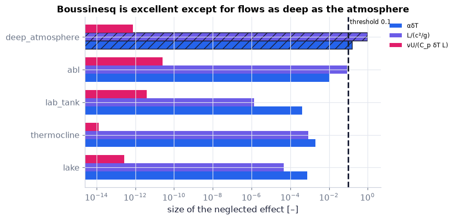

```python
names = ["lake", "thermocline", "lab_tank", "abl", "deep_atmosphere"]  # the five scenarios
vals = []                                        # an empty list to fill
for name in names:                                                    # the three small numbers of each
    p = ch04.boussinesq_scenario(name)                                        # call the tested chapter function
    v = ch04.boussinesq_validity(p["alpha"], p["dT"], p["L"], p["U"], c=p["c"], nu=p["nu"], cp=p["cp"])  # call the tested chapter function
    vals.append([v["alpha_dT"], v["L_over_Hc"], v["heating_ratio"]])  # keep the three small numbers
vals = np.array(vals)  # 5 scenarios × 3 numbers
fig, ax = plt.subplots(figsize=(8, 3.8))                                        # the figure and its panels
labels = ["αδT", "L/(c²/g)", "νU/(C_p δT L)"]                                        # one colour / label per series
cols = [COLORS["blue"], COLORS["accent"], COLORS["rose"]]                                        # one colour / label per series
for k in range(3):                                                    # three bars per scenario, log scale
    bars = ax.barh(np.arange(5) + (k - 1)*0.25, vals[:, k], 0.25, color=cols[k], label=labels[k], log=True)  # one row of bars per number (log axis)
    for j, b_ in enumerate(bars):  # mark the bars beyond the threshold
        if vals[j, k] > 0.1:  # neglected effect not small
            b_.set_hatch("//"); b_.set_edgecolor(COLORS["ink"])       # crossing the threshold: hatched, colour kept
ax.axvline(0.1, ls="--", color=COLORS["ink"]); ax.text(0.12, 4.4, "threshold 0.1", fontsize=8)      # a label on the plot
ax.set_yticks(np.arange(5), names); ax.set_xlabel("size of the neglected effect [–]"); ax.legend(fontsize=8, loc="upper left", bbox_to_anchor=(1.01, 1.0))  # labels; legend outside the bars
ax.set_title("Boussinesq is excellent except for flows as deep as the atmosphere")                  # the panel's message
savefig(fig, "ch04", "boussinesq_validity"); plt.show()                                        # save the PNG to outputs/ch04, then draw
```

**What you see.** Most bars far to the left of the dashed line; the deep atmosphere's two bars crossing it, hatched.

**How to read it.** Boussinesq is excellent for lakes, oceans and boundary layers; it fails for flows as deep as the atmosphere's scale height and with large temperature contrasts (then use the anelastic or full compressible equations).

**What would change if…** …a 50 K temperature difference in air: αδT ≈ 0.17 — marginal.

#### 🎮 Interactive: Density hardly changes — so why does it drive the flow?

**Why interactive rather than a static figure:** the approximation is a judgement about three small numbers; moving the fluid, the temperature contrast and the depth shows when each crosses its threshold while the blob keeps (or loses) its buoyancy.

Choose a fluid, a temperature contrast and a depth: three small numbers are compared with their thresholds while a warm blob rises and spreads under exactly the terms Boussinesq keeps, $\frac{D\mathbf u}{Dt}=-\frac1{\rho_0}\nabla p'+\frac{\rho'}{\rho_0}\mathbf g+\nu\nabla^2\mathbf u$ (4.86) and $\frac{DT}{Dt}=\kappa\nabla^2T$ (4.89). The rise uses a one-line parcel model (our extension, labelled in the explainer): $dw/dt=g'-w/\tau_d$. Switch the buoyancy term off and the blob stops rising, though in the lake setting ρ changed by only 0.075 % (α = 1.5×10⁻⁴ K⁻¹, δT = 5 K).

**What to try:**

- Lake preset: read αδT and g′ in Explain.
- Toggle 'keep buoyancy' off: the blob only diffuses.
- Deep-atmosphere preset: the status turns amber — L is comparable to c²/g.
- Derivation tab D27, the 'why keep ρ′g' step: the grey dropped bar is a thousand times smaller than the blue buoyancy bar.

```python
show_viz("ch04", "boussinesq_buoyancy")   # full-width explainer; ⤢ Full screen for more room
```

🎮 Interactive 8/9 Density hardly changes — so why does it drive the flow? Open alone ↗

[interactive chart not shown]

**What would change if…** …we asked what happens at the edges — the walls, the free surface, the interface between two fluids? The field equations are complete; to solve them we need conditions on the boundaries (C14).

## 4.10 Boundary Conditions

**What is this section about?** The field equations need conditions at the edges of the flow. Conservation laws applied to a thin "pillbox" straddling an interface give continuity of mass flux, traction and heat flux; experience adds no-slip and no temperature jump; a moving surface made of fluid obeys the kinematic condition Dη/Dt = 0; and surface tension adds a pressure jump across a curved interface.

> 🔁 **Recap — Surface tension** (Ch. 1 §1.6). Molecules at a liquid surface are pulled inward more than outward; the surface behaves like a stretched membrane with tension σ [N/m], the energy per unit area of surface. Water at 20 °C has σ ≈ 0.0728 N/m (Ch. 1 §1.6, `ch01.surface_tension_water`). Here we *derive* the pressure jump it causes.

### 🧩 The surface is made of fluid: the kinematic condition (4.91) and other edge rules `C14`

*The question:* A wave runs across the sea. The water on the surface stays on the surface — it neither sinks into the sea nor flies off. What does that sentence say as an equation?

*In one line:* $\frac{\partial\eta}{\partial t}+(\mathbf u\cdot\nabla)\eta\equiv\frac{D\eta}{Dt}=0\ \text{on}\ \eta=0$ *(4.91)*

#### The problem in plain words

Every solution of Navier–Stokes is fixed by what happens at its edges: the wall of a pipe, the sea surface, the boundary between warm and cold layers of the ocean, the skin of a raindrop. Some conditions follow from the conservation laws (what crosses an interface must be continuous), some from experiment (fluid sticks to walls), and one from geometry (a free surface moves with the fluid on it). Ch. 7 builds water waves on the last one; Ch. 13's layered ocean models on the same condition at each layer interface.

#### The idea

```
pillbox across an interface, height l → 0:  volume and side terms vanish  →  flux in = flux out:
      ρu·n continuous, traction n_iτ_ij continuous, k ∂T/∂n continuous
experiment at a solid wall:  no slip (u·t = 0 relative to the wall), no temperature jump (T₁ = T₂)
a surface η(x, t) = 0 made of fluid:  Dη/Dt = ∂η/∂t + u·∇η = 0   (4.91)  — normal velocities match
curved interface with tension σ:  Δp = σ(1/R₁ + 1/R₂)
```

*The numbered equations in the sketch:* $\frac{\partial\eta}{\partial t}+(\mathbf u\cdot\nabla)\eta\equiv\frac{D\eta}{Dt}=0\ \text{on}\ \eta=0$ *(4.91)*

> 🔁 **Tools from earlier chapters used here** (see `knowledge/primers.md`)
- **boundary conditions** — the values (or fluxes) a field must take on the edges of its domain; with them a differential equation has one solution (Ch. 1 P20).

📝 **Note.** **What must be specified** `N115` — the velocity on every bounding surface; for an external flow, the velocity and thermodynamic state on a distant closed surface. The solvers of Ch. 8–10 show it in action.

📝 **Note.** **Interface conditions from a pillbox** `N116` — (stated; the book's Fig. 4.18 argument): apply the budgets (4.5), $\frac{d}{dt}\int_{V^*(t)}\rho\,dV+\int_{A^*(t)}\rho\,(\mathbf u-\mathbf b)\cdot\mathbf n\,dA=0$, (4.17), $\frac{d}{dt}\int_{V^*}\rho\mathbf u\,dV+\int_{A^*}\rho\mathbf u(\mathbf u-\mathbf b)\cdot\mathbf n\,dA=\int_{V^*}\rho\mathbf g\,dV+\int_{A^*}\mathbf f\,dA$ and (4.48), $\frac{d}{dt}\int_{V^*}\rho\big(e+\tfrac12\lvert\mathbf u\rvert^2\big)dV+\int_{A^*}\big(\rho e+\tfrac\rho2\lvert\mathbf u\rvert^2\big)(\mathbf u-\mathbf b)\cdot\mathbf n\,dA=\int_{V^*}\rho\mathbf g\cdot\mathbf u\,dV+\int_{A^*}\mathbf f\cdot\mathbf u\,dA-\int_{A^*}\mathbf q\cdot\mathbf n\,dA$ to a flat cylinder straddling the interface and let its height l → 0 — the volume integrals and the side-wall fluxes (∝ l) vanish, leaving the two end faces (interface at rest; traction continuous if surface tension is neglected — with it, the Laplace jump below is added). **Two worked cases** (code): (a) a composite wall, k₁ = 1, k₂ = 0.1 W/(m K), each 0.1 m thick, 30 °C and 20 °C outside: the heat flux 10/(0.1/1 + 0.1/0.1) = 9.09 W/m² is the same in both layers, the interface is at 29.09 °C and the temperature slopes differ by the factor k₁/k₂ = 10 — the profile has a kink; (b) two-fluid Couette, water (μ₁ = 10⁻³ Pa s, 1 mm) under oil (μ₂ = 0.1 Pa s, 1 mm), top plate at 1 m/s: the shear stress τ = U/(h₁/μ₁ + h₂/μ₂) = 0.990 Pa is continuous, the velocity slopes differ by μ₂/μ₁ = 100, the interface moves at 0.990 m/s.

$$ \rho_1\mathbf u_1\cdot\mathbf n=\rho_2\mathbf u_2\cdot\mathbf n,\qquad n_i\tau^{(1)}_{ij}=n_i\tau^{(2)}_{ij},\qquad k_1\frac{\partial T_1}{\partial n}=k_2\frac{\partial T_2}{\partial n} $$

```python
print(ch04.two_layer_conduction(np.array([0.05, 0.15]), 1.0, 0.1, 0.1, 0.1, 303.15, 293.15))   # q = 9.09 W/m² in both layers, interface 302.24 K
print(ch04.two_fluid_couette(np.array([5e-4, 1.5e-3]), 1e-3, 0.1, 1e-3, 1e-3, 1.0))           # τ = 0.990 Pa in both, interface at 0.990 m/s
print(ch04.pillbox_limit(9.09, 9.09, side_rate=2.0, volume_rate=5.0, l=np.array([1e-1, 1e-2, 1e-3]))["residual"])   # ∝ l → 0
```

```
{'T': array([302.6955, 297.6955]), 'q': 9.09090909090909, 'T_interface': 302.24090909090904}
{'u': array([0.495, 0.995]), 'tau': 0.9900990099009901, 'u_interface': 0.9900990099009901}
[0.7   0.07  0.007]
```

**What does the code above do?**

1. The composite wall: one heat flux through both layers, a kinked temperature profile.
2. Two-fluid Couette: one shear stress in both fluids, a kinked velocity profile.
3. The pillbox balance for three heights: the side and volume terms shrink with l, leaving flux in = flux out.

$$ \mathbf u_1\cdot\mathbf t=0\ \ (\text{relative to the wall}),\qquad T_1=T_2 $$

> 🔁 **Tools from earlier chapters used here** (see `knowledge/primers.md`)
- **unit normal ∇η/‖∇η‖** — the gradient of a level-set function is perpendicular to its level surfaces; dividing by its length gives the unit normal (Ch. 2 P75).

> 📎 **Primer — moving level set and its normal speed.** `P132` · A surface can be described as the set of points where a function is zero, η(x, t) = 0 (a level set, Ch. 2 P75). Its unit normal is $\mathbf n=\nabla\eta/\lvert\nabla\eta\rvert$ (pointing toward increasing η). If it moves, a point riding on it keeps η = 0, and the chain rule gives its speed along n: $-(\partial\eta/\partial t)/\lvert\nabla\eta\rvert$. Only this normal speed is defined — sliding along the surface does not change the surface.

```python
V = 1.5                                                        # a wall moving at 1.5 m/s along +x
eta = lambda x, t: x[0] - V*t                                  # the plane x = Vt as a level set
print(ch04.surface_normal_speed(eta, np.array([2.0, 0.3, 0.0]), 1.0))   # 1.5: it moves at V along n = +x
```

```
1.4999999999994449
```

📝 **Note.** **An observer riding on the moving surface** `N118` — at velocity $\mathbf u_s$ sees η stay zero:

$$ d\eta/dt=\partial\eta/\partial t+(\mathbf u_s\cdot\nabla)\eta=0\quad\text{on}\quad\eta=0 \qquad \text{(4.90)} $$

#### 🧮 Derivation — The kinematic boundary condition: (4.90) → (4.91) → (4.92) → (4.93) `D29` (Eq. 4.91)

**What we want to show.** Turn "no fluid crosses this moving surface" into an equation, and find the mass flux when fluid does cross.

**Assumptions.** η smooth with ∇η ≠ 0 on the surface (step 4); no fluid crosses (steps 5–7).

**The plan.**

1. Follow a point riding on the surface.
2. Get its normal speed.
3. Demand the fluid's normal speed be the same.
4. Allow a relative velocity for leaky surfaces.

**Tools we use** (each explained before this point): Moving level set and its normal speed (primer in C14) · chain rule along a path (ch03 P91) · unit normal ∇η/‖∇η‖ (ch02 P75).

**We start from**

$$ \text{A surface described as a level set}\ \eta(\mathbf x,t)=0 $$

*In words:* the free surface, an interface or a wall is where a function η vanishes.

**Step 1 of 8 — Describe the surface as a level set.**

$$ \eta(\mathbf x,t)=0 $$

- *Why we can do this:* Any moving, deforming surface can be written as the zero set of a function (primer); e.g. a wave η = z − a cos(kx − ωt).
- *In words:* The surface is where η is zero.

**Step 2 of 8 — Follow a point riding on it.**

$$ \eta\big(\mathbf x_s(t),t\big)=0\ \text{for all }t,\qquad\frac{d\mathbf x_s}{dt}=\mathbf u_s $$

- *Why we can do this:* A point that stays on the surface keeps η = 0 as time runs; u_s is its velocity.
- *In words:* A marker glued to the surface.

**Step 3 of 8 — Differentiate along its path.**

$$ \frac{d\eta}{dt}=\frac{\partial\eta}{\partial t}+(\mathbf u_s\cdot\nabla)\eta=0 $$

- *Why we can do this:* Chain rule along a path (ch03 P91); the derivative of a constant (0) is zero. This is (4.90), $\frac{\partial\eta}{\partial t}+(\mathbf u_s\cdot\nabla)\eta=0\ \text{on}\ \eta=0$ — the line above.
- *In words:* The marker sees η stay zero.

**Step 4 of 8 — Get the surface's normal speed.**

$$ \mathbf u_s\cdot\mathbf n=-\frac{\partial\eta/\partial t}{\lvert\nabla\eta\rvert},\qquad\mathbf n=\frac{\nabla\eta}{\lvert\nabla\eta\rvert} $$

- *Why we can do this:* Divide (4.90), $\frac{\partial\eta}{\partial t}+(\mathbf u_s\cdot\nabla)\eta=0\ \text{on}\ \eta=0$ by |∇η| ≠ 0. Only the normal part of u_s is fixed — sliding along the surface does not move it.
- *In words:* How fast the surface moves along its own normal.

**Step 5 of 8 — Demand no flow across.**

$$ \mathbf u\cdot\mathbf n=\mathbf u_s\cdot\mathbf n $$

- *Why we can do this:* Fluid particles on the surface stay on it: their velocity relative to the surface has no normal component.
- *In words:* The fluid moves normal to the surface exactly as fast as the surface.

**Step 6 of 8 — Multiply by the gradient's size.**

$$ \mathbf u\cdot\nabla\eta=\mathbf u_s\cdot\nabla\eta=-\frac{\partial\eta}{\partial t} $$

- *Why we can do this:* Multiply step 5 by the gradient's size, n times its length being ∇η; then use (4.90), $\frac{\partial\eta}{\partial t}+(\mathbf u_s\cdot\nabla)\eta=0\ \text{on}\ \eta=0$.
- *In words:* Written with η's gradient.

**Step 7 of 8 — Rearrange.**

$$ \frac{\partial\eta}{\partial t}+(\mathbf u\cdot\nabla)\eta\equiv\frac{D\eta}{Dt}=0\quad\text{on}\quad\eta=0 $$

- *Why we can do this:* Move the term left; it is the material derivative of η (3.5), $\frac{DF}{Dt}=\frac{\partial F}{\partial t}+\mathbf u\cdot\nabla F$. This is (4.91), $\frac{\partial\eta}{\partial t}+(\mathbf u\cdot\nabla)\eta\equiv\frac{D\eta}{Dt}=0\ \text{on}\ \eta=0$ — the line above.
- *In words:* η stays zero for every fluid particle on the surface.

**Step 8 of 8 — Allow a flux across.**

$$ (u_{rel})_n=\mathbf u\cdot\mathbf n-\mathbf u_s\cdot\mathbf n=\frac{1}{\lvert\nabla\eta\rvert}\frac{D\eta}{Dt} $$

- *Why we can do this:* For evaporation or a shock the relative normal velocity is not zero; steps 4–6 give it. This is (4.92), $(u_{rel})_n=\mathbf u\cdot\mathbf n-\mathbf u_s\cdot\mathbf n=\frac{1}{\lvert\nabla\eta\rvert}\frac{D\eta}{Dt}$ — the line above; times ρ it is the mass flux per area (4.93), $\frac{\rho}{\lvert\nabla\eta\rvert}\frac{D\eta}{Dt}\ \text{on}\ \eta=0$.
- *In words:* Dη/Dt measures how fast fluid crosses the surface.

**Result**

$$ \begin{array}{l}\partial\eta/\partial t+(\mathbf u\cdot\nabla)\eta\equiv D\eta/Dt=0\ \text{on η = 0 (4.91); with crossing,}\ (u_{rel})_n=(1/\lvert\nabla\eta\rvert)D\eta/Dt\ \text{(4.92)} \\ \text{and mass flux}\ (\rho/\lvert\nabla\eta\rvert)D\eta/Dt\ \text{(4.93).}\end{array} $$

**What it means.** Every free-surface problem (Ch. 7), every layer interface (Ch. 13) and every moving shock (Ch. 15) uses it. It fixes only the normal velocity; tangential conditions come from stresses or no-slip.

**Check it.** Units: η/s ✓. Moving wall: Dη/Dt = −V + u·e_x = 0 when u_x = V ✓. Linear wave: the linearised condition ∂η/∂t = w at z = 0 is exact for the linear solution; the full (4.91), $\frac{\partial\eta}{\partial t}+(\mathbf u\cdot\nabla)\eta\equiv\frac{D\eta}{Dt}=0\ \text{on}\ \eta=0$ at the true surface leaves a residual ~ (ka)² in units of the phase speed ✓.

> ⚠️ **Common confusion (traps in `D29`):** Thinking u_s is fully defined (only its normal part is). The orientation of n (toward increasing η). Taking the linearised condition as exact at finite amplitude.

📝 **Note.** **The kinematic boundary condition — no fluid crosses the surface** `C14` — C14's result, restated. A free surface, an interface between immiscible fluids and a solid wall all obey it.

$$ \partial\eta/\partial t+(\mathbf u\cdot\nabla)\eta\equiv D\eta/Dt=0\quad\text{on}\quad\eta=0 \qquad \text{(4.91)} $$

📝 **Note.** **If mass does cross** `N119` — (evaporation, a shock), the normal velocity of the fluid relative to the surface is

$$ (u_{rel})_n=\mathbf u\cdot\mathbf n-\mathbf u_s\cdot\mathbf n=\big(\mathbf u\cdot\nabla\eta+\partial\eta/\partial t\big)/\lvert\nabla\eta\rvert=(1/\lvert\nabla\eta\rvert)D\eta/Dt \qquad \text{(4.92)} $$

📝 **Note.** **and the mass flux per unit area through it** `N120` — Zero flux is again Dη/Dt = 0. Moving shocks: Ch. 15. (Code: `ch04.interface_mass_flux`, below.)

$$ (\rho/\lvert\nabla\eta\rvert)D\eta/Dt\quad\text{on}\quad\eta=0 \qquad \text{(4.93)} $$

> 🔁 **Tools from earlier chapters used here** (see `knowledge/primers.md`)
- **Gibbs free energy (as the model for f)** — g = h − Ts traded an unmeasurable variable for a measurable one; f = e − Ts does the same at fixed T and v (Ch. 1 P50).

📝 **Note.** **Surface tension as free energy** `N121` — At constant temperature the useful quantity is the Helmholtz free energy per unit mass (a Legendre device, like Ch. 1's Gibbs g = h − Ts):

$$ f=e-Ts \qquad \text{(4.94)} $$

📝 **Note.** **Its differential** `N122` — At constant T and reversibly ($T\,ds=de+p\,dv$ *(1.18)*): df = −p dv — the work done on the system. (The sympy line below: for a perfect gas at fixed T, e is constant and s = C_v ln T + R ln v + const, so df/dv = −RT/v = −p.)

$$ df=de-T\,ds-s\,dT \qquad \text{(4.95)} $$

```python
v, T, R, Cv = sp.symbols('v T R C_v', positive=True)                  # specific volume, temperature, gas constants
e = Cv*T                                                             # internal energy of a perfect gas: fixed at fixed T
s = Cv*sp.log(T) + R*sp.log(v)                                       # its entropy (up to a constant)
f = e - T*s                                                          # Helmholtz free energy (4.94)
print(sp.simplify(sp.diff(f, v)))                                    # −R*T/v = −p: df = −p dv at constant T
```

```
-R*T/v
```

📝 **Note.** **Free energy of two fluids and their interface** `N123` — of area A: σ is free energy per unit area; with σ > 0 (immiscible fluids) the system lowers F by shrinking A — the interface contracts as far as the constraints allow. Number (code): the surface area of a spheroid of fixed volume (`ch04.spheroid_area`) is smallest at aspect ratio 1 — a sphere.

$$ F=\rho_1V_1f_1+\rho_2V_2f_2+A\sigma \qquad \text{(4.96)} $$

```python
for asp in (0.5, 0.8, 1.0, 1.25, 2.0):                               # oblate … sphere … prolate, volume 1 m³
    print(asp, round(ch04.spheroid_area(1.0, asp), 4))               # smallest area (4.836 m²) at aspect 1
```

```
0.5 5.2975
0.8 4.8803
1.0 4.836
1.25 4.8773
2.0 5.207
```

📝 **Note.** **Marangoni flows** `N124` — Where σ varies along an interface (with temperature or a surfactant) the surface pulls toward high σ and drags fluid with it — *Marangoni* flows (tears of wine). Not treated in the book; see Ch. 16 and interfacial-flow texts.

📝 **Note.** **The Laplace jump derived** `N125` — (stated with numeric checks; the book writes the construction): cut a small cap $z=x^2/2R_1+y^2/2R_2$ (R₁, R₂ its two principal radii of curvature, Ch. 1 §1.6) at height ζ; its rim is an ellipse with semi-axes $\sqrt{2R_1\zeta}$, $\sqrt{2R_2\zeta}$. The pressure difference Δp pushes on it with the force below.

$$ (F_p)_z=-\pi\Delta p\sqrt{2R_1\zeta}\sqrt{2R_2\zeta} \qquad \text{(4.97)} $$

📝 **Note.** **Surface tension on the rim** `N126` — The surface tension pulls along the rim ($\sigma\oint_C\mathbf t\times\mathbf n\,ds$) with a net upward force, for a small cap, as below.

> ⚠️ **Book slip:** the curve C is printed as ζ = x²/2R₁ − y²/2R₂; it must be **+** (the cap equation); the book's later lines use +.

$$ (F_{st})_z=\pi\sigma\sqrt{2R_1\zeta}\sqrt{2R_2\zeta}\Big(\frac1{R_1}+\frac1{R_2}\Big) \qquad \text{(4.98)} $$

📝 **Note.** **Both forces are ∝ ζ; they balance when** `N127` — Laplace's law (1.5), which Ch. 1 stated, now derived. Higher pressure on the concave side. Number: a water drop of radius 1 mm (R₁ = R₂ = 1 mm, σ = 0.0728 N/m): Δp = 146 Pa. Capillary waves: Ch. 7.

$$ \Delta p=\sigma\Big(\frac1{R_1}+\frac1{R_2}\Big) \qquad \text{(1.5)} $$

📝 **Note.** **Capillary length** `N128` — where gravity and surface tension are equally strong. Water at 20 °C: √(0.0728/(998 × 9.81)) = 2.73 mm. Smaller than ℓ_c, surface tension wins (a drop is round); larger, gravity wins (a puddle is flat). Its square ratio is the Bond number (C15).

$$ \ell_c=\big(\sigma/\rho g\big)^{1/2} $$

📝 **Note.** **Ex. 4.7 — the meniscus at a vertical wall** `N129` — (stated; the closed form is checked against an ODE solution instead of re-derived): a liquid meets a wall at contact angle θ; the surface height ζ(x) obeys the first relation below, and the second is the height at the wall. Water on clean glass (θ = 0): h = √2 ℓ_c = 3.86 mm.

> ⚠️ **Book slips in Ex. 4.7:** the separated equation drops a minus sign (the slope is negative), and "evaluated when η = h/δ" should read γ = h/δ — here γ = ζ/δ, yet another γ; the final closed form is right (verified by differentiation in the tests).

$$ \Big(\frac{\rho g}{2\sigma}\Big)\zeta^2+\big(1+\zeta'^2\big)^{-1/2}=1,\qquad h^2=\frac{2\sigma}{\rho g}(1-\sin\theta) $$

#### ✏️ Tiny example: three edges

1. **A moving wall** η = x − Vt, V = 1 m/s, with fluid at u = (1, 0.3, 0) m/s on it: ∂η/∂t = −1, ∇η = (1, 0, 0), so Dη/Dt = −1 + 1 × 1 = 0 ✓ — the fluid's normal speed (1 m/s) equals the wall's; the tangential 0.3 m/s is not constrained by $D\eta/Dt=0$ *(4.91)* (no-slip is a separate condition).
2. **A small water wave** η = a cos(kx − ωt) with ka = 0.1: the linearised condition ∂η/∂t = w at z = 0 holds exactly for the linear solution; the full condition (4.91), $\frac{\partial\eta}{\partial t}+(\mathbf u\cdot\nabla)\eta\equiv\frac{D\eta}{Dt}=0\ \text{on}\ \eta=0$ at the true surface leaves a residual of order (ka)² ≈ 0.01 of the phase speed — a quarter of that at ka = 0.05.
3. **A drop**: R = 1 mm, σ = 0.0728 N/m → Δp = 2σ/R = 146 Pa; ℓ_c = 2.73 mm.

```python
u_w = lambda x, t: np.array([1.0, 0.3, 0.0])                         # fluid velocity at the wall [m/s]
print(ch04.kinematic_bc_residual("moving_wall", u_w, np.array([0.5, 0.0, 0.0]), 0.5, V=1.0),        # show the numbers
      ch04.surface_normal_speed("moving_wall", np.array([0.5, 0, 0]), 0.5, V=1.0))   # Dη/Dt = 0; the wall moves at 1 m/s
u_evap = lambda x, t: np.array([1.2, 0.3, 0.0])                      # fluid crossing the wall at 0.2 m/s relative to it
print(ch04.relative_normal_velocity("moving_wall", u_evap, np.array([0.5, 0, 0]), 0.5, V=1.0),      # show the numbers
      ch04.interface_mass_flux("moving_wall", u_evap, 1000.0, np.array([0.5, 0, 0]), 0.5, V=1.0))   # (4.92): 0.2 m/s, (4.93): 200 kg/(m² s)
for ka in (0.2, 0.1, 0.05):                                          # three wave steepnesses
    k = 1.0; a = ka/k; c = np.sqrt(9.81/k)                           # wavenumber [1/m], amplitude [m], phase speed [m/s]
    res = max(abs(ch04.wave_kinematic_residual(x, 0.0, a, k)) for x in np.linspace(0, 2*np.pi, 64))   # full (4.91) at the true surface
    print(ka, round(res/c, 5), ch04.wave_kinematic_residual(0.3, 0.0, a, k, full=False))   # ∝ (ka)²; the linearised one is 0
print(ch04.laplace_jump_from_balance(0.0728, 1e-3, 1e-3), ch01.laplace_pressure_jump(0.0728, 1e-3, 1e-3))   # 145.6 Pa both ways
print(ch04.cap_pressure_force(2*0.0728/1e-3, 1e-3, 1e-3, 1e-6), ch04.cap_surface_tension_force(0.0728, 1e-3, 1e-3, 1e-6))   # ≈ ∓9.2e-7 N with the exact Δp = 2σ/R
print(ch04.capillary_length(0.0728, 998.0), ch04.meniscus_height(0.0, 0.0728, 998.0))   # 2.727 mm and 3.856 mm
```

```
0.0 1.0
0.2 200.0
0.2 0.04445 0.0
0.1 0.01054 0.0
0.05 0.00257 0.0
145.60000000000002 145.6
-9.148317807253481e-07 9.139183189091218e-07
0.002726879300973213 0.003856389690390783
```

**What does the code above do?**

1. The wall condition: Dη/Dt = 0 and the wall's normal speed; then a fluid that crosses the wall — (4.92), $(u_{rel})_n=\mathbf u\cdot\mathbf n-\mathbf u_s\cdot\mathbf n=\frac{1}{\lvert\nabla\eta\rvert}\frac{D\eta}{Dt}$ gives its relative normal speed and (4.93), $\frac{\rho}{\lvert\nabla\eta\rvert}\frac{D\eta}{Dt}\ \text{on}\ \eta=0$ its mass flux.
2. The full condition's residual for the linear wave shrinks like (ka)², while the linearised one is exact — the error made by linearising (Ch. 7).
3. Laplace from the cap balance equals Ch. 1's formula $\Delta p=\sigma(1/R_1+1/R_2)$ *(1.5)*.
4. The two cap forces nearly cancel (with the exact Δp = 2σ/R their small difference is the finite-ζ, higher-order part).
5. Capillary length and the meniscus height at θ = 0.

```python
a, k = 0.1, 1.0; w = np.sqrt(9.81*k)                                 # amplitude [m], wavenumber [1/m], frequency [rad/s]
eta = lambda x, t: x[1] - a*np.cos(k*x[0] - w*t)                     # the surface as the level set z − ζ(x, t) = 0
uw = lambda x, t: np.array([ch04.linear_wave_surface(x[0], x[1], t, a, k)["u"],  # the linear wave's velocity (u, w)
                            ch04.linear_wave_surface(x[0], x[1], t, a, k)["w"]])   # the linear wave's velocity (u, w)
p = np.array([0.3, a*np.cos(0.3)])                                   # a point ON the surface at t = 0
d = 1e-6                                                             # finite-difference step
deta_dt = (eta(p, d) - eta(p, -d)) / (2*d)                          # ∂η/∂t
grad = np.array([(eta(p + e, 0) - eta(p - e, 0))/(2*d) for e in np.eye(2)*d])   # ∇η
mine = deta_dt + uw(p, 0.0) @ grad                                   # Dη/Dt = ∂η/∂t + u·∇η by hand
print(mine, ch04.kinematic_bc_residual(eta, uw, p, 0.0))             # the same small O((ka)²) residual
assert np.isclose(mine, ch04.kinematic_bc_residual(eta, uw, p, 0.0), rtol=1e-5)
```

```
0.01900771049100465 0.019007711989414797
```

```python
a, k = 0.15, 1.0; w = np.sqrt(9.81*k); lam = 2*np.pi/k              # ka = 0.15 (exaggerated), deep water
uw2 = lambda x, t: np.array([ch04.linear_wave_surface(x[0], x[1], t, a, k)["u"],
                             ch04.linear_wave_surface(x[0], x[1], t, a, k)["w"]])   # velocity field of the wave [m/s]
frames = 60 if not FAST else 30                                        # number of frames (halved when FAST)
tt = np.linspace(0, 2*np.pi/w, frames)                               # one period [s]
x0s = np.linspace(0, 2*lam, 13)[:-1]                                 # particles along two wavelengths
top = [ch03.pathline(uw2, [x0, a*np.cos(k*x0)], 0.0, tt) for x0 in x0s]   # start ON the surface; follow them (solve_ivp)
deep = [ch03.pathline(uw2, [x0, -0.3*lam], 0.0, tt) for x0 in x0s]  # a row 0.3 λ below
xg = np.linspace(0, 2*lam, 300)                                        # evenly spaced values
fig, ax = plt.subplots(figsize=(7, 3.2), dpi=80)                                        # the figure and its panels
(surf,) = ax.plot(xg, a*np.cos(k*xg), color=COLORS["blue"], lw=2)                                   # draw once; update() moves it
dt_ = ax.scatter([p[0, 0] for p in top], [p[1, 0] for p in top], color=COLORS["orange"], s=18, zorder=3)  # draw once; update() moves it
dd = ax.scatter([p[0, 0] for p in deep], [p[1, 0] for p in deep], color=COLORS["muted"], s=12)      # draw once; update() moves it
arrows = []                                        # an empty list to fill
ax.set_xlim(0, 2*lam); ax.set_ylim(-0.3*lam - 0.3, 0.6); ax.set_aspect("equal"); ax.set_xlabel("x [m]"); ax.set_ylabel("z [m]")  # axis labels with units
ax.set_title("ka = 0.15: surface particles stay on the surface", fontsize=10)                       # the panel's message


def update(i):                                                       # draw frame i
    t = tt[i]                                        # the time of this frame [s]
    surf.set_ydata(a*np.cos(k*xg - w*t))                             # the moving surface
    dt_.set_offsets([[p[0, i], p[1, i]] for p in top]); dd.set_offsets([[p[0, i], p[1, i]] for p in deep])  # move this artist to the new frame
    for ar in arrows:  # remove last frame's arrows
        ar.remove()                                        # redraw the arrows each frame
    arrows.clear()                                        # redraw the arrows each frame
    P = np.array([top[3][0, i], top[3][1, i]])                       # one marked surface particle
    eta_f = lambda x, t_: x[1] - a*np.cos(k*x[0] - w*t_)             # level set of the surface
    g_ = np.array([-a*k*np.sin(k*P[0] - w*t), 1.0]); n = g_/np.linalg.norm(g_)   # unit normal ∇η/|∇η|
    un = uw2(P, t) @ n                                                # fluid normal speed u·n (teal)
    us = ch04.surface_normal_speed(eta_f, P, t)                       # surface normal speed (rose)
    arrows.append(ax.arrow(P[0], P[1], 1.5*un*n[0], 1.5*un*n[1], width=0.02, color=COLORS["teal"]))  # redraw the arrows each frame
    arrows.append(ax.arrow(P[0] + 0.15, P[1], 1.5*us*n[0], 1.5*us*n[1], width=0.02, color=COLORS["rose"]))  # redraw the arrows each frame
    return surf, dt_, dd                                        # the artists that changed in this frame


show_animation(animate(update, frames=frames, fig=fig, interval=60))                                # build the movie from update() and play it
```

[video not shown]

**What you see.** Surface particles (orange) bob and circle but stay on the moving surface; deeper particles (grey) make smaller circles; at the marked particle the teal and rose arrows have the same length.

**How to read it.** That coincidence *is* (4.91), $D\eta/Dt=0$: the surface moves normal to itself exactly as fast as the fluid on it (up to the small O((ka)²) error of the linear solution).

**What would change if…** …an evaporating surface: the rose arrow would lag the teal one by the evaporation speed and (4.92), $(u_{rel})_n=\mathbf u\cdot\mathbf n-\mathbf u_s\cdot\mathbf n=\frac{1}{\lvert\nabla\eta\rvert}\frac{D\eta}{Dt}$ would be nonzero.

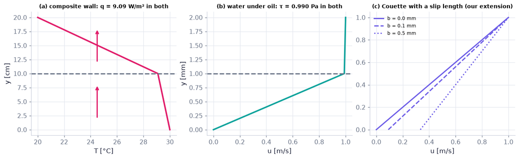

```python
fig, (a, b, c) = plt.subplots(1, 3, figsize=(12, 3.6))                                        # the figure and its panels
yy = np.linspace(0, 0.2, 201)                                        # through the composite wall [m]
cw = ch04.two_layer_conduction(yy, 1.0, 0.1, 0.1, 0.1, 303.15, 293.15)   # temperature through two layers
a.plot(cw["T"] - 273.15, yy*100, color=COLORS["rose"], lw=2.5); a.axhline(10, ls="--", color=COLORS["muted"])  # a reference line
for yv in (5, 15):                                                    # equal heat-flux arrows on both sides
    a.annotate("", (24.5, yv + 3), (24.5, yv - 3), arrowprops=dict(arrowstyle="->", color=COLORS["rose"], lw=2))  # heat-flux arrow: upward, from the 30 °C wall (y = 0) to the 20 °C wall
a.set_xlabel("T [°C]"); a.set_ylabel("y [cm]"); a.set_title(f"(a) composite wall: q = {cw['q']:.2f} W/m² in both", fontsize=9)  # axis labels with units
y2 = np.linspace(0, 2e-3, 201)                                       # through water (below) and oil (above) [m]
tf = ch04.two_fluid_couette(y2, 1e-3, 0.1, 1e-3, 1e-3, 1.0)                                        # call the tested chapter function
b.plot(tf["u"], y2*1e3, color=COLORS["teal"], lw=2.5); b.axhline(1.0, ls="--", color=COLORS["muted"])  # a reference line
b.set_xlabel("u [m/s]"); b.set_ylabel("y [mm]"); b.set_title(f"(b) water under oil: τ = {tf['tau']:.3f} Pa in both", fontsize=9)  # axis labels with units
y3 = np.linspace(0, 1e-3, 101)                                       # Couette with a slip length [m]
for bl, ls in ((0.0, "-"), (1e-4, "--"), (5e-4, ":")):  # three slip lengths [m]
    c.plot(ch04.navier_slip_couette(y3, U=1.0, h=1e-3, slip_length=bl), y3*1e3, ls, color=COLORS["accent"], label=f"b = {bl*1e3:.1f} mm")  # draw the data
c.set_xlabel("u [m/s]"); c.set_title("(c) Couette with a slip length (our extension)", fontsize=9); c.legend(fontsize=8)  # axis labels with units
savefig(fig, "ch04", "interfaces"); plt.show()                                        # save the PNG to outputs/ch04, then draw
```

**What you see.** Kinked profiles in (a) and (b), with equal flux arrows on both sides; in (c) the no-slip line (solid) and two slipping profiles that no longer start at u = 0.

**How to read it.** In (a) heat flows up, from hot (30 °C at y = 0) to cold, at the same 9.09 W/m² in both layers. What is continuous is the *flux* (heat, momentum); the gradients jump in inverse proportion to k or μ. Slip is invisible unless b is a sizeable fraction of the gap.

**What would change if…** …k₂ = k₁: no kink, one straight line.

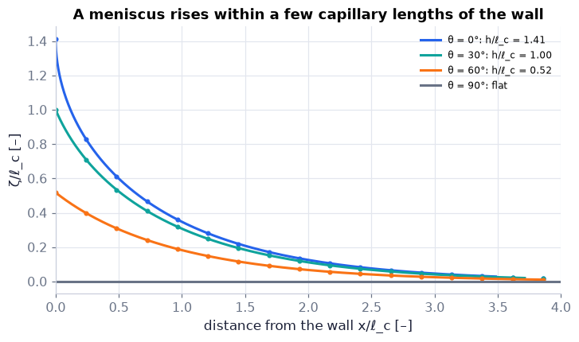

```python
lc = ch04.capillary_length(0.0728, 998.0)                            # capillary length of water [m]
fig, ax = plt.subplots(figsize=(6.5, 3.8))                                        # the figure and its panels
for deg, col in ((0, COLORS["blue"]), (30, COLORS["teal"]), (60, COLORS["orange"]), (90, COLORS["muted"])):  # four contact angles
    th = np.deg2rad(deg)                                             # contact angle [rad]
    h = ch04.meniscus_height(th, 0.0728, 998.0)                      # height at the wall [m]
    if h > 1e-9:  # a meniscus that rises
        zeta = np.linspace(h, 0.02*h, 200)                           # heights from the wall down to nearly flat
        ax.plot(ch04.meniscus_profile_x(zeta, th)/lc, zeta/lc, color=col, lw=2, label=f"θ = {deg}°: h/ℓ_c = {h/lc:.2f}")   # closed form
        if deg in (0, 60) or not FAST:  # ODE markers (fewer when FAST)
            x_o, z_o = ch04.meniscus_profile_ode(th, x_max=4*lc)     # the ODE solution, for comparison
            ax.plot(x_o[::12]/lc, z_o[::12]/lc, "o", ms=3, color=col)                               # draw the data
    else:  # θ = 90°: no rise
        ax.plot([0, 4], [0, 0], color=col, lw=2, label="θ = 90°: flat")                             # draw the data
ax.set_xlim(0, 4); ax.set_xlabel("distance from the wall x/ℓ_c [–]"); ax.set_ylabel("ζ/ℓ_c [–]"); ax.legend(fontsize=8)  # axis labels with units
ax.set_title("A meniscus rises within a few capillary lengths of the wall")                         # the panel's message
savefig(fig, "ch04", "meniscus"); plt.show()                                        # save the PNG to outputs/ch04, then draw
```

**What you see.** Curves rising to the wall, lower for larger contact angle, flat at 90°; the ODE markers sit on the closed-form curves.

**How to read it.** Surface tension lifts the liquid within a few capillary lengths of the wall; gravity flattens it farther away.

**What would change if…** …mercury on glass (θ ≈ 140°): 1 − sin θ < 1 still, but the meniscus is depressed — the formula's h² gives |h|, the sign comes from cos θ < 0.

> ⚠️ **Common confusion:** "$D\eta/Dt=0$ *(4.91)* is the no-slip condition." It only matches the **normal** velocities; the tangential velocity at a free surface is set by the stress condition (no shear from the air), at a solid wall by no-slip.

**What would change if…** …we measured every length in units of the body's size, every speed in units of the free stream, every time in units of the forcing period? The equations would lose their dimensions and only a few numbers would remain — and two flows with the same numbers would be the same flow (C15).

## 4.11 Dimensionless Forms of the Equations and Dynamic Similarity

**What is this section about?** Scale every variable by the problem's own sizes and Navier–Stokes keeps only three numbers — St, Fr, Re. Two flows with equal numbers and the same shape are the same flow: model testing works, data collapse, and every later chapter names its regimes by these numbers.

> 🔁 **Recap — Dimensional analysis of sphere drag** (Ch. 1 §1.11). The drag $F_D$ on a sphere of diameter d in a fluid (ρ, μ) moving at U depends on 5 variables with 3 dimensions, so on 5 − 3 = 2 groups (Ch. 1's Π theorem): $\frac{F_D}{\rho U^2d^2}=\Psi\Big(\frac{\rho Ud}{\mu}\Big)$ or equally $\frac{F_D\rho}{\mu^2}=\Phi\Big(\frac{\mu}{\rho Ud}\Big)$ *(Eq. 4.99)* — two choices of repeating variables; the second group is the first times Re².

```python
from fluidpy.core.dimensional import pi_groups, SPHERE_DRAG          # Ch. 1's Π-theorem machinery; F, D, U, ρ, μ
print(pi_groups(SPHERE_DRAG, solution="F", repeating=["rho", "U", "D"]))   # F/(ρU²D²) and μ/(ρUD) = 1/Re
print(pi_groups(SPHERE_DRAG, solution="F", repeating=["rho", "mu", "D"]))  # Fρ/μ² and ρUD/μ = Re
```

```
[{'F': Fraction(1, 1), 'rho': Fraction(-1, 1), 'U': Fraction(-2, 1), 'D': Fraction(-2, 1)}, {'mu': Fraction(1, 1), 'rho': Fraction(-1, 1), 'U': Fraction(-1, 1), 'D': Fraction(-1, 1)}]
[{'F': Fraction(1, 1), 'rho': Fraction(1, 1), 'mu': Fraction(-2, 1), 'D': Fraction(0, 1)}, {'U': Fraction(1, 1), 'rho': Fraction(1, 1), 'mu': Fraction(-1, 1), 'D': Fraction(1, 1)}]
```

**What does the code above do?**

Each group is printed as its exponents: {F: 1, ρ: −1, U: −2, D: −2} is F/(ρU²D²). Two choices of repeating variables give two equivalent pairs of groups.

### 🧩 When is a model the real thing? Dimensionless Navier–Stokes (4.101) `C15`

*The question:* A ship designer tows a 4-m model in a tank to predict the drag of a 100-m ship. What must be the same in the tank for the answer to be right — and can everything be matched at once?

*In one line:* $\Big[\frac{\Omega l}{U}\Big]\frac{\partial\mathbf u^*}{\partial t^*}+(\mathbf u^*\cdot\nabla^*)\mathbf u^*=-\nabla^*p^*+\Big[\frac{gl}{U^2}\Big]\mathbf g^*+\Big[\frac{\mu}{\rho Ul}\Big]\nabla^{*2}\mathbf u^*$ *(4.101)*

#### The problem in plain words

Wind tunnels, towing tanks, rotating tanks and computer runs all study small or slow copies of real flows. The copy is only useful if the physics is the same. Equations tell us exactly which combinations of sizes must agree. The same combinations — Reynolds, Froude, Richardson, Rossby, Mach — classify the flows of every later chapter: creeping or boundary-layer flow (Ch. 8–9), waves (Ch. 7), stratified instability (Ch. 11), geostrophic flow (Ch. 13).

#### The idea

```
x = l x*,  t = t*/Ω,  u = U u*,  p − p∞ = ρU² p*,  g = g g*                                (4.100)
(4.39b) ÷ (ρU²/l)  →  [Ωl/U] ∂u*/∂t* + (u*·∇*)u* = −∇*p* + [gl/U²] g* + [μ/ρUl] ∇*²u*     (4.101)
                          St (blue)                           1/Fr² (grey)   1/Re (rose)
same St, Fr, Re + same shape + same boundary conditions  →  same dimensionless solution
```

*The numbered equations in the sketch:* $x_i^*=\frac{x_i}{l},\ t^*=\Omega t,\ u_j^*=\frac{u_j}{U},\ p^*=\frac{p-p_\infty}{\rho U^2},\ g_j^*=\frac{g_j}{g}$ *(4.100)* · $\rho\frac{D\mathbf u}{Dt}=-\nabla p+\rho\mathbf g+\mu\nabla^2\mathbf u$ *(4.39b)* · $\Big[\frac{\Omega l}{U}\Big]\frac{\partial\mathbf u^*}{\partial t^*}+(\mathbf u^*\cdot\nabla^*)\mathbf u^*=-\nabla^*p^*+\Big[\frac{gl}{U^2}\Big]\mathbf g^*+\Big[\frac{\mu}{\rho Ul}\Big]\nabla^{*2}\mathbf u^*$ *(4.101)*

📝 **Note.** **Two routes to the groups** `N130` — Dimensional analysis (R12) finds *that* groups exist; scaling the equations tells *which* groups and what each measures (a ratio of two terms). Dynamic similarity = geometric similarity + equal groups. The figure at the end of the block shows two dimensional Stokes-layer solutions collapsing onto one dimensionless curve.

📝 **Note.** **The parameters of a general unsteady flow** `N132` — a length l, a speed U, a frequency Ω (pulsating flow in a tube, a swimmer's stroke, a turbine's rotation), and the fluid's ρ and μ.

> 📎 **Primer — scaled variables and the chain rule.** `P133` · If t* = Ωt then ∂/∂t = Ω ∂/∂t* (each second of t is Ω units of t*), and if x* = x/l then ∂/∂x = (1/l)∂/∂x*, ∂²/∂x² = (1/l²)∂²/∂x*². Scaling a derivative brings out its scale factor — the move that turns each term of an equation into (a size) × (a dimensionless term of order one).

```python
t, Om = sp.symbols('t Omega', positive=True); f = sp.Function('f')     # time, frequency, an unknown function
expr = sp.diff(f(Om*t), t)                                             # d/dt of f(Ωt)
print(sp.simplify(expr))                                               # Omega*Subs(Derivative(f(_xi_1), _xi_1), _xi_1, Omega*t): the factor Ω
```

```
Omega*Subs(Derivative(f(_xi_1), _xi_1), _xi_1, Omega*t)
```

📝 **Note.** **Scaled variables** `N133` — (Ω an imposed frequency).

> ⚠️ The time and pressure scales change inside this section: t* = Ωt here but Ut/l for steady boundary conditions and in (4.109), $t^*=Ut/l,\ p^*=(p-p_\infty)/\rho_oU^2,\ \rho^*=\rho/\rho_o$; p scaled by ρU² here, but μU/l (slow viscous flow) or ρgl (hydrostatics) are also used. `ch04.Scales` records which convention each use takes.

$$ x_i^*=x_i/l,\quad t^*=\Omega t,\quad u_j^*=u_j/U,\quad p^*=(p-p_\infty)/\rho U^2,\quad g_j^*=g_j/g \qquad \text{(4.100)} $$

#### 🧮 Derivation — Dimensionless Navier–Stokes: (4.100) → (4.101) `D30` (Eq. 4.101)

**What we want to show.** Scale every variable by the problem's own sizes and find which combinations of them the flow can depend on.

**Assumptions.** Incompressible, constant ρ and μ (the starting equation); one length l, speed U, frequency Ω describe the problem.

**The plan.**

1. Introduce scaled variables.
2. Scale the derivatives with the chain rule.
3. Substitute and divide by the size of the advective term.
4. Name the groups; note the boundary conditions scale too.

**Tools we use** (each explained before this point): Scaled variables and the chain rule (primer in C15) · order-of-magnitude scaling (primer in C13) · sympy subs/collect (primer in C05).

**We start from**

$$ \text{(4.39b) written out:}\ \rho\Big(\frac{\partial\mathbf u}{\partial t}+(\mathbf u\cdot\nabla)\mathbf u\Big)=-\nabla p+\rho\mathbf g+\mu\nabla^2\mathbf u\ \text{.} $$

**Step 1 of 8 — Start from Navier–Stokes.**

$$ \rho\frac{\partial\mathbf u}{\partial t}+\rho(\mathbf u\cdot\nabla)\mathbf u=-\nabla p+\rho\mathbf g+\mu\nabla^2\mathbf u $$

- *Why we can do this:* (4.39b), $\rho\frac{D\mathbf u}{Dt}=-\nabla p+\rho\mathbf g+\mu\nabla^2\mathbf u$ with D/Dt written out (the book's §4.11 re-display).
- *In words:* Five terms with dimensions.

**Step 2 of 8 — Scale the variables.**

$$ \mathbf x=l\mathbf x^*,\quad t=\frac{t^*}{\Omega},\quad\mathbf u=U\mathbf u^*,\quad p=p_\infty+\rho U^2p^*,\quad\mathbf g=g\,\mathbf g^* $$

- *Why we can do this:* (4.100), $x_i^*=\frac{x_i}{l},\ t^*=\Omega t,\ u_j^*=\frac{u_j}{U},\ p^*=\frac{p-p_\infty}{\rho U^2},\ g_j^*=\frac{g_j}{g}$: starred variables are pure numbers of order one when l, U, Ω, ρU² are the right sizes.
- *In words:* Measure everything in the problem's own units.

**Step 3 of 8 — Scale the derivatives.**

$$ \frac{\partial}{\partial t}=\Omega\frac{\partial}{\partial t^*},\qquad\nabla=\frac1l\nabla^*,\qquad\nabla^2=\frac1{l^2}\nabla^{*2} $$

- *Why we can do this:* Chain rule (primer): t* = Ωt gives ∂/∂t = Ω∂/∂t*; x* = x/l gives ∂/∂x = (1/l)∂/∂x*.
- *In words:* Each derivative brings out its scale.

**Step 4 of 8 — Substitute term by term.**

$$ \rho U\Omega\frac{\partial\mathbf u^*}{\partial t^*}+\frac{\rho U^2}{l}(\mathbf u^*\cdot\nabla^*)\mathbf u^*=-\frac{\rho U^2}{l}\nabla^*p^*+\rho g\,\mathbf g^*+\frac{\mu U}{l^2}\nabla^{*2}\mathbf u^* $$

- *Why we can do this:* Steps 2–3 in step 1; p∞ is a constant, so its gradient vanishes — only pressure differences matter.
- *In words:* Each term = (a size) × (a term of order one).

**Step 5 of 8 — Divide by ρU²/l.**

$$ \Big[\frac{\Omega l}{U}\Big]\frac{\partial\mathbf u^*}{\partial t^*}+(\mathbf u^*\cdot\nabla^*)\mathbf u^*=-\nabla^*p^*+\Big[\frac{gl}{U^2}\Big]\mathbf g^*+\Big[\frac{\mu}{\rho Ul}\Big]\nabla^{*2}\mathbf u^* $$

- *Why we can do this:* The advective term's size ρU²/l is the natural yardstick (and the pressure scale ρU² was chosen to match it). This is (4.101), $\Big[\frac{\Omega l}{U}\Big]\frac{\partial\mathbf u^*}{\partial t^*}+(\mathbf u^*\cdot\nabla^*)\mathbf u^*=-\nabla^*p^*+\Big[\frac{gl}{U^2}\Big]\mathbf g^*+\Big[\frac{\mu}{\rho Ul}\Big]\nabla^{*2}\mathbf u^*$ — the line above.
- *In words:* Three brackets remain.

**Step 6 of 8 — Name the groups.**

$$ \mathrm{St}=\frac{\Omega l}{U},\qquad\frac1{\mathrm{Fr}^2}=\frac{gl}{U^2},\qquad\frac1{\mathrm{Re}}=\frac{\mu}{\rho Ul} $$

- *Why we can do this:* (4.102)–(4.104), $\mathrm{Fr}=\frac{U}{\sqrt{gl}}$: each bracket is a ratio of two terms' sizes — unsteady/advective, gravity/inertia, viscous/inertia.
- *In words:* Strouhal, Froude and Reynolds numbers.

**Step 7 of 8 — Scale the boundary conditions.**

$$ \mathbf u^*\to\mathbf e_x\ \text{far away},\qquad\mathbf u^*=0\ \text{on the body}\ (r^*=1) $$

- *Why we can do this:* For a body of size l in a stream U, the conditions in starred variables contain no l, U or Ω — only the shape.
- *In words:* The edges look the same for every size.

**Step 8 of 8 — Conclude dynamic similarity.**

$$ \text{equal St, Fr, Re}+\text{same shape}\ \Rightarrow\ \text{same }\mathbf u^*(\mathbf x^*,t^*),\ p^* $$

- *Why we can do this:* The same dimensionless equation with the same dimensionless conditions has the same solution.
- *In words:* Two flows with equal groups are the same flow at different scales.

**Result**

$$ \big[\frac{\Omega l}{U}\big]\frac{\partial\mathbf u^*}{\partial t^*}+(\mathbf u^*\cdot\nabla^*)\mathbf u^*=-\nabla^*p^*+\big[\frac{gl}{U^2}\big]\mathbf g^*+\big[\frac{\mu}{\rho Ul}\big]\nabla^{*2}\mathbf u^* $$

*In words:* the equation knows only St, Fr and Re.

**What it means.** Model testing works when the groups that matter match; Re, Fr, St (and later Ri, Ro, M) name the regimes of every later chapter. When two groups cannot both match (a ship model: Fr and Re), each effect is scaled by its own law.

**Check it.** Every bracket dimensionless (Ω l/U: s⁻¹·m/(m/s) ✓; gl/U² ✓; μ/(ρUl): Pa s/(kg/m³·m/s·m) ✓). Stokes-layer collapse (C15 figure) ✓. sympy check (the cell below): `ch04.nondimensional_ns_coefficients()` equals the brackets. Other pressure scales (μU/l, ρgl) give products of the same groups (Exercise 4.59) ✓.

```python
Om, l, U, g, mu, rho = sp.symbols('Omega l U g mu rho', positive=True)   # the scales of (4.100)
sizes = {"unsteady": rho*U*Om, "advective": rho*U**2/l, "pressure": rho*U**2/l,   # step 4: the factor each term carries
         "gravity": rho*g, "viscous": mu*U/l**2}
mine = {k: sp.simplify(v/(rho*U**2/l)) for k, v in sizes.items()}    # step 5: divide by ρU²/l
lib = ch04.nondimensional_ns_coefficients()                          # the library's brackets
print(mine)                                                          # Ωl/U, 1, 1, gl/U², μ/(ρUl)
print(ch04.nondimensional_ns_sym())                                  # the whole of (4.101)
assert all(sp.simplify(mine[k] - lib[k]) == 0 for k in mine)         # identical
```

```
{'unsteady': Omega*l/U, 'advective': 1, 'pressure': 1, 'gravity': g*l/U**2, 'viscous': mu/(U*l*rho)}
```

```
Eq((u^*\cdot\nabla^*)u^* + Omega*\partial_{t^*}u^**l/U, -\nabla^*p^* + \nabla^{*2}u^**mu/(U*l*rho) + g*g^**l/U**2)
```

> ⚠️ **Common confusion (traps in `D30`):** Forgetting that the time and pressure scales can change (Ωt vs Ut/l; ρU² vs μU/l). Believing geometric similarity is enough. Book slip: the text calls the brackets "in (4.100), $x_i^*=\frac{x_i}{l},\ t^*=\Omega t,\ u_j^*=\frac{u_j}{U},\ p^*=\frac{p-p_\infty}{\rho U^2},\ g_j^*=\frac{g_j}{g}$"; they are in (4.101), $\Big[\frac{\Omega l}{U}\Big]\frac{\partial\mathbf u^*}{\partial t^*}+(\mathbf u^*\cdot\nabla^*)\mathbf u^*=-\nabla^*p^*+\Big[\frac{gl}{U^2}\Big]\mathbf g^*+\Big[\frac{\mu}{\rho Ul}\Big]\nabla^{*2}\mathbf u^*$.

📝 **Note.** **Strouhal number** `N134` — unsteady over advective acceleration. Vortex shedding behind a cylinder happens at St ≈ 0.2 (Ch. 9).

$$ \mathrm{St}\equiv\frac{\text{unsteady acceleration}}{\text{advective acceleration}}\propto\frac{\partial u/\partial t}{u(\partial u/\partial x)}\propto\frac{\Omega U}{U^2/l}=\frac{\Omega l}{U} \qquad \text{(4.102)} $$

📝 **Note.** **Reynolds number** `N135` — inertia over viscous force. Our numbers (code below): a bacterium (1 µm, 30 µm/s, water) Re ≈ 3×10⁻⁵ · a 1-cm marble at 1 m/s in water 10⁴ · a car (4 m, 30 m/s, air) 8×10⁶ · an ocean liner (300 m, 10 m/s, water) 3×10⁹ · the Gulf Stream (100 km, 1 m/s) 10¹¹.

$$ \mathrm{Re}\equiv\frac{\text{inertia force}}{\text{viscous force}}\propto\frac{\rho u(\partial u/\partial x)}{\mu(\partial^2u/\partial x^2)}\propto\frac{\rho U^2/l}{\mu U/l^2}=\frac{\rho Ul}{\mu} \qquad \text{(4.103)} $$

📝 **Note.** **Froude number** `N136` — the square root of inertia over gravity. Gravity matters dynamically only with a free surface or density differences — a submarine deep down does not feel Fr; a ship does (waves, Ch. 7).

$$ \mathrm{Fr}\equiv\Big[\frac{\text{inertia force}}{\text{gravity force}}\Big]^{1/2}\propto\Big[\frac{\rho U^2/l}{\rho g}\Big]^{1/2}=\frac{U}{\sqrt{gl}} \qquad \text{(4.104)} $$

📝 **Note.** **Stratified flows** `N137` — use the reduced gravity g′ = g(ρ₂ − ρ₁)/ρ₁ or the buoyancy frequency N. Numbers: an ocean thermocline Δρ/ρ = 10⁻³ (g′ = 9.81×10⁻³ m/s²), l = 100 m, U = 0.1 m/s → Ri = 98 — stratification dominates. The atmosphere with dT/dz = −6.5 K/km (Kundu's Γ; meteorology's lapse rate Γ_met = −dT/dz = +6.5 K/km) at 288 K: $N^2=\frac gT\big(\frac{dT}{dz}+\frac g{C_p}\big)=\frac{9.81}{288}(-6.5+9.76)\times10^{-3}=1.11\times10^{-4}$ s⁻² (stable since dT/dz = −6.5 > Γ_a = −9.8 K/km ⇔ Γ_met = 6.5 < 9.8 K/km); with a wind shear dU/dz = 0.01 s⁻¹, Ri_g = 1.1 — above the ¼ of Ch. 11's stability criterion.

| convention | lapse rate | adiabatic | stable when |
| --- | --- | --- | --- |
| Kundu Γ ≡ dT/dz | −6.5 K/km | Γ_a = −9.8 K/km | Γ > Γ_a |
| meteorology Γ_met ≡ −dT/dz | +6.5 K/km | +9.8 K/km | Γ_met < 9.8 K/km |

$$ \mathrm{Fr}'=\frac{U}{\sqrt{g'l}}\ \text{or}\ \frac{U}{Nl},\qquad\mathrm{Ri}=\frac1{\mathrm{Fr}'^2},\qquad\mathrm{Ri}_g=\frac{N^2}{(dU/dz)^2} \qquad \text{(4.105)} $$

```python
from fluidpy.core import stratification                              # Ch. 1's buoyancy-frequency helpers
N2 = stratification.brunt_vaisala_sq_from_lapse(288.0, -6.5e-3)     # N² for dT/dz = −6.5 K/km (Kundu's Γ) [1/s²]
print(f"N² = {N2:.3e} 1/s²  (dT/dz = −6.5 K/km ⇔ Γ_met = +6.5 K/km)")                               # show the numbers
print(ch04.richardson_number(9.81e-3, 100.0, 0.1), round(ch04.gradient_richardson_number(N2, 0.01), 3))   # Ri = 98.1, Ri_g ≈ 1.11
```

```
N² = 1.110e-04 1/s²  (dT/dz = −6.5 K/km ⇔ Γ_met = +6.5 K/km)
98.09999999999997 1.11
```

📝 **Note.** **Every output agrees** `N138` — Under dynamic similarity **every** dimensionless output agrees too — local ones (a pressure coefficient at a point) and overall ones (a drag coefficient).

📝 **Note.** **Pressure coefficient** `N139` — Demo (code below): the ideal cylinder's surface C_p = 1 − 4 sin²θ is identical for five (U, a) pairs (`ch04.pressure_coefficient` on `ch03.cylinder_flow` with the Bernoulli pressure).

$$ C_p\equiv\frac{p-p_\infty}{\tfrac12\rho U^2}=\Psi\Big(\mathrm{St},\mathrm{Fr},\mathrm{Re};\frac{\mathbf x}{l},\Omega t\Big) \qquad \text{(4.106)} $$

```python
th = np.linspace(0, np.pi, 7)                                        # angles round the cylinder [rad]
for U, a in ((1.0, 1.0), (10.0, 0.1), (0.5, 3.0), (2.0, 0.2), (7.0, 5.0)):   # five different cylinders and streams
    us, vs = ch03.cylinder_flow(-a*(1 + 1e-9)*np.cos(th), a*(1 + 1e-9)*np.sin(th), U, a)   # surface velocity (just outside r = a) [m/s]
    p = 0.5*1.2*(U**2 - (us**2 + vs**2))                             # Bernoulli pressure relative to p∞ (air) [Pa]
    print((U, a), np.round(ch04.pressure_coefficient(p, 0.0, 1.2, U), 4))   # identical rows: C_p = 1 − 4 sin²θ
```

```
(1.0, 1.0) [ 1.  0. -2. -3. -2.  0.  1.]
(10.0, 0.1) [ 1.  0. -2. -3. -2.  0.  1.]
(0.5, 3.0) [ 1.  0. -2. -3. -2.  0.  1.]
(2.0, 0.2) [ 1.  0. -2. -3. -2.  0.  1.]
(7.0, 5.0) [ 1.  0. -2. -3. -2.  0.  1.]
```

📝 **Note.** **Steady boundary conditions** `N140` — With steady boundary conditions the only time scale is l/U: t* = Ut/l and St drops out — but a flow can still become unsteady by itself (vortex shedding), at a frequency that scales with U/l (Ch. 9).

📝 **Note.** **A purely oscillating body** `N141` — with amplitude l at frequency Ω has U = lΩ, so St = 1, Re = Ωl²/ν and Fr = Ω(l/g)^{1/2} (`ch04.Scales.from_oscillation`, code below) — the Stokes-layer and Womersley parameters of Ch. 8 and Ch. 16.

```python
S = ch04.Scales.from_oscillation(0.1, 2.0, 1000.0, 1e-3)             # l = 0.1 m, Ω = 2 rad/s, water
print(S.St, round(S.Re), round(S.Fr, 4))                             # St = 1, Re = Ωl²/ν = 2×10⁴, Fr = Ω√(l/g) = 0.2019
```

```
1.0 20000 0.2019
```

📝 **Note.** **Drag coefficient** `N142`

$$ C_D\equiv\frac{F_D}{\tfrac12\rho U^2A} \qquad \text{(4.107)} $$

📝 **Note.** **Lift coefficient** `N143` — A is a reference area: the frontal area πd²/4 for a sphere or a car, the planform (span × chord) for a plate or a wing (`ch04.reference_area`: a 1-cm sphere 7.85×10⁻⁵ m², a 2 m × 0.5 m plate 1 m²). Wings: Ch. 14.

$$ C_L\equiv\frac{F_L}{\tfrac12\rho U^2A} \qquad \text{(4.108)} $$

📝 **Note.** **Sphere drag** `N131` — (our version of the sphere-drag curve: the slider figure and the data-collapse figure at the end of this block): $C_D=D/(\tfrac12\rho U^2\cdot\pi d^2/4)$ against Re = ρUd/μ — 24/Re (Stokes, Ch. 8) at small Re, a plateau near 0.4–0.5 for 10³ ≲ Re ≲ 2×10⁵, then the *drag crisis* (Ch. 9). We use the published correlation of Morrison (2013) (a cited V5 benchmark). Number: d = 1 cm, U = 1 m/s in water → Re = 10⁴, C_D = 0.39.

📝 **Note.** **Ship drag** `N144` — For a ship, C_D = C_D(Fr, Re); far from any free surface and at low Mach number, C_D = C_D(Re) alone — the bridge to Ex. 4.8 below.

📝 **Note.** **Compressible flow scalings** `N145` — (t* = Ut/l now):

$$ t^*=Ut/l,\ p^*=(p-p_\infty)/\rho_oU^2,\ \rho^*=\rho/\rho_o \qquad \text{(4.109)} $$

📝 **Note.** **Departure from ∇·u = 0** `N146` — Using (4.9), $\frac{D\rho}{Dt}\equiv\frac{\partial\rho}{\partial t}+\mathbf u\cdot\nabla\rho=0$'s §4.11 re-display, $\nabla\cdot\mathbf u=-\frac1\rho\frac{D\rho}{Dt}=-\frac{1}{\rho c^2}\frac{Dp}{Dt}$ (isentropic density changes dp = c²dρ — a general identity, not the incompressibility condition), the scalings give the line below: the departure from ∇·u = 0 is of order M² — 0.09 at M = 0.3 (`ch04.compressibility_parameter`).

$$ \nabla^*\cdot\mathbf u^*=-\Big[\frac{U^2}{c^2}\Big]\frac1{\rho^*}\frac{Dp^*}{Dt^*} \qquad \text{(4.110)} $$

📝 **Note.** **Mach number** `N147` — (the square root of inertia over compressibility forces). Incompressible treatment is good below M ≈ 0.3 (C02's N12): ≈ 100 m/s in air. Ch. 14, 15.

$$ M\equiv U/c \qquad \text{(4.111)} $$

📝 **Note.** **Energy equation in enthalpy form** `N148` — (stated; the book calls it "a mild revision" of (4.60), $\rho\frac{De}{Dt}=-p\frac{\partial u_m}{\partial x_m}+2\mu\big(S_{ij}-\tfrac13S_{mm}\delta_{ij}\big)^2+\mu_vS_{mm}^2+\frac{\partial}{\partial x_i}\Big(k\frac{\partial T}{\partial x_i}\Big)$ and does not write the steps; a sympy one-liner proves the two agree, `ch04.energy_forms_sym()` → 0, below):

$$ \rho\frac{Dh}{Dt}=\frac{Dp}{Dt}+\rho\varepsilon+\frac{\partial}{\partial x_i}\Big(k\frac{\partial T}{\partial x_i}\Big) \qquad \text{(4.112)} $$

```python
print(ch04.energy_forms_sym())                                       # 0: (4.60) and (4.112) are the same equation
```

```
0
```

📝 **Note.** **Thermal scalings** `N149`

$$ \varepsilon^*=\frac{\rho_ol^2}{\mu_oU^2}\varepsilon,\quad\mu^*=\mu/\mu_o,\quad k^*=k/k_o,\quad T^*=\frac{T-T_o}{T_w-T_o} \qquad \text{(4.113)} $$

📝 **Note.** **Dimensionless energy equation** `N150` — (dh ≅ C_p dT). The brackets are Ec, Ec/Re and 1/(Pr Re) (`ch04.nondimensional_energy_coefficients()`).

> ⚠️ The book introduces it with "those defined in (4.106), $C_p\equiv\frac{p-p_\infty}{\tfrac12\rho U^2}$, (4.107), $C_D\equiv\frac{F_D}{\tfrac12\rho U^2A}$"; it means the scalings (4.109), $t^*=Ut/l,\ p^*=(p-p_\infty)/\rho_oU^2,\ \rho^*=\rho/\rho_o$, and the equation (4.112), $\rho\frac{Dh}{Dt}=\frac{Dp}{Dt}+\rho\varepsilon+\frac{\partial}{\partial x_i}\Big(k\frac{\partial T}{\partial x_i}\Big)$.

$$ \rho^*\frac{DT^*}{Dt^*}=\Big[\frac{U^2}{C_p(T_w-T_o)}\Big]\frac{Dp^*}{Dt^*}+\Big[\frac{\mu_oU}{\rho_oC_p(T_w-T_o)l}\Big]\varepsilon^*+\Big[\frac{k_o}{\rho_oC_pUl}\Big]\frac{\partial}{\partial x_i^*}\Big(k^*\frac{\partial T^*}{\partial x_i^*}\Big) \qquad \text{(4.114)} $$

📝 **Note.** **Eckert number** `N151` — Small Ec ⇒ pressure work and viscous heating drop out and (4.112), $\rho\frac{Dh}{Dt}=\frac{Dp}{Dt}+\rho\varepsilon+\frac{\partial}{\partial x_i}\Big(k\frac{\partial T}{\partial x_i}\Big)$ becomes the Boussinesq heat equation $\frac{DT}{Dt}=\kappa\nabla^2T$ *(4.89)* — the hidden assumption of C13.

$$ \mathrm{Ec}\equiv\frac{U^2}{C_p(T_w-T_o)} \qquad \text{(4.115)} $$

📝 **Note.** **Prandtl number** `N152` — momentum diffusivity over heat diffusivity. Our values from `ch01.FLUIDS` (`ch04.prandtl_of`, code below): air ≈ 0.709, water at 20 °C ≈ 6.95; kinetic theory for a monatomic gas 2/3; Eucken's estimate 4γ/(9γ − 5) = 0.74 for γ = 1.4. Published property tables (the book's included) give values 1.5–2.2 % different at 20 °C — Pr is a ratio of three measured properties, and tables disagree at that level. Thermal boundary layers: Ch. 9; convection: Ch. 11.

$$ \mathrm{Pr}\equiv\frac{\nu}{\kappa}=\frac{\mu_oC_p}{k_o} \qquad \text{(4.116)} $$

📝 **Note.** **Weber number** `N153` — (a ratio of *forces*, not per volume). Break-up of drops and jets (Ch. 7, 16).

$$ \mathrm{We}\equiv\frac{\rho U^2l}{\sigma} \qquad \text{(4.117)} $$

📝 **Note.** **Bond number** `N154` — (the capillary length of C14).

$$ \mathrm{Bo}\equiv\frac{\rho l^2g}{\sigma}=(l/\ell_c)^2 \qquad \text{(4.118)} $$

📝 **Note.** **Capillary number** `N155` — Coating flows and flow in porous media (Ch. 16).

$$ \mathrm{Ca}\equiv\frac{\mu U}{\sigma}=\mathrm{We}/\mathrm{Re} \qquad \text{(4.119)} $$

📝 **Note.** **Ex. 4.8 — the ship model** `N156` — (stated with our own numbers; the book's are in the private test data). A 1:25 model of a 100-m ship designed for 10 m/s. **Froude matching** $U_m=U_p\sqrt{l_m/l_p}=10/5=2$ m/s makes the wave pattern similar — but then Re_m/Re_p = (l_m/l_p)^{3/2} = 1/125: the model's boundary layers are far too viscous. Froude's way out: split the drag into friction (depends on Re, from a flat-plate friction line) and wave drag (depends on Fr, scaled by $(\rho_p/\rho_m)(l_p/l_m)^2(U_p/U_m)^2=(l_p/l_m)^3$ = 25³ for equal densities, i.e. λ⁻³ with λ = l_m/l_p = 1/25). Numbers in the worked example; `ch04.ship_drag_extrapolation`.

> ⚠️ The book's total 9.14×10⁵ N is 9.15×10⁵ N without the intermediate rounding — a detail, not an error in the method.

#### ✏️ Tiny example: similarity by hand

1. **Sphere**: d = 1 cm, U = 1 m/s, water ν = 10⁻⁶ m²/s: Re = Ud/ν = 10⁴; C_D ≈ 0.39 (plateau) → drag ½ρU²C_D πd²/4 = 0.5 × 1000 × 1 × 0.39 × 7.85×10⁻⁵ = 0.015 N.
2. **The same Re in air** (ν = 1.5×10⁻⁵): a 1-cm sphere needs U = 15 m/s — then its drag coefficient is the same 0.39.
3. **Ship**: λ = 1/25, U_p = 10 m/s → U_m = 2 m/s (Fr = 0.32 both); Re_p = 10 × 100/10⁻⁶ = 10⁹, Re_m = 2 × 4/10⁻⁶ = 8×10⁶ — off by 125.
4. **Drag extrapolation** (model wetted area 4 m², prototype 2500 m²; the ITTC 1957 friction line C_f = 0.075/(log₁₀Re − 2)², a standard flat-plate correlation): C_f,m = 0.00312, C_f,p = 0.00153. Model measures 40 N total; friction ½ρU²SC_f = ½ × 1000 × 4 × 4 × 0.00312 = 25.0 N; wave 15.0 N. Wave drag scales by (1025/1000) × 25² × 5² = 16 016 → 240.9 kN. Prototype friction ½ × 1025 × 100 × 2500 × 0.00153 = 196.0 kN. Total ≈ 437 kN. Scaling the whole 40 N by 16 016 would give 641 kN — 47 % too much, because friction does not scale with Fr.

```python
for name, (U, l, nu) in {"bacterium": (3e-5, 1e-6, 1e-6), "marble": (1.0, 0.01, 1e-6), "car": (30.0, 4.0, 1.5e-5),  # five flows from microbes to ocean currents
                         "liner": (10.0, 300.0, 1e-6), "Gulf Stream": (1.0, 1e5, 1e-6)}.items():   # speed [m/s], size [m], ν [m²/s]
    print(f"{name:12s} Re = {ch04.reynolds_number(U, l, nu):.1e}")  # 16 orders of magnitude
print(ch04.sphere_drag_coefficient(1e4), ch04.sphere_drag_coefficient(0.1, model="stokes"))   # 0.3926 (Morrison), 240 (24/Re)
print(ch04.froude_scaled_speed(10.0, 100.0, 4.0), ch04.froude_number(10.0, 100.0), ch04.froude_number(2.0, 4.0))   # 2 m/s; Fr 0.3193 twice
mp = ch04.model_prototype(100.0, 10.0, 1/25)                          # the 1:25 model, Froude-matched
print(mp["U_m"], round(mp["Re_ratio"], 1), mp["matched"])             # 2.0 m/s, Re off by 125, only Fr matched
print(ch04.ship_drag_extrapolation(100.0, 10.0, 2500.0, 1/25, 40.0, 0.00312, 0.00153))   # Froude's extrapolation [N]
print(ch04.prandtl_of("air"), ch04.prandtl_of("water"), ch04.eucken_prandtl(1.4))   # 0.709, 6.95, 0.737
print(ch04.nondimensional_ns_coefficients())                          # the brackets of (4.101)
```

```
bacterium    Re = 3.0e-05
marble       Re = 1.0e+04
car          Re = 8.0e+06
liner        Re = 3.0e+09
Gulf Stream  Re = 1.0e+11
0.39260172957727624 240.0
2.0 0.3192754284070505 0.3192754284070505
2.0 125.0 ['Fr']
{'U_m': 2.0, 'D_m_friction': 24.96, 'D_m_wave': 15.04, 'D_p_wave': 240875.0, 'D_p_friction': 196031.25, 'D_p_total': 436906.25, 'Re_ratio': 125.0, 'Re_m': 8000000.0, 'Re_p': 1000000000.0, 'D_p_uncorrected': 640625.0}
0.7090133918600541 6.9471734946467505 0.7368421052631579
```

```
{'unsteady': Omega*l/U, 'advective': 1, 'pressure': 1, 'gravity': g*l/U**2, 'viscous': mu/(U*l*rho)}
```

**What does the code above do?**

1. Reynolds numbers across 16 orders of magnitude.
2. The sphere's drag coefficient in two regimes.
3. Froude scaling keeps Fr equal.
4. The model–prototype summary: Fr matched, Re not (Re_p/Re_m = $(l_p/l_m)^{3/2}$ = 125).
5. Froude's extrapolation: friction and wave drag scaled separately (437 kN instead of the naive 641 kN).
6. The Prandtl numbers and Eucken's estimate.
7. The brackets of (4.101), $\big[\frac{\Omega l}{U}\big]$, $\big[\frac{gl}{U^2}\big]$, $\big[\frac{\mu}{\rho Ul}\big]$.

```python
U_p, l_p, nu = 10.0, 100.0, 1e-6                                     # the ship [m/s], [m], water ν [m²/s]
U_m, l_m = 2.0, 4.0                                                  # the model
Re_hand = (U_p*l_p/nu, U_m*l_m/nu); Fr_hand = (U_p/np.sqrt(9.81*l_p), U_m/np.sqrt(9.81*l_m))   # by hand
assert np.isclose(Fr_hand[0], Fr_hand[1]) and np.isclose(Re_hand[0]/Re_hand[1], 125.0)   # Fr matched, Re off by 125
x_, t_, l, U, Om, rho, mu = sp.symbols('x t l U Omega rho mu', positive=True)   # dimensional symbols
us = sp.Function('u_s')                                              # the dimensionless velocity u*(x*, t*)
u = U*us(x_/l, Om*t_)                                                # (4.100): u = U u*(x/l, Ωt)
dus_dts = sp.diff(us(x_/l, Om*t_), t_) / Om                         # ∂u*/∂t* (the chain rule brought out a factor Ω)
d2us_dxs2 = sp.diff(us(x_/l, Om*t_), x_, 2) * l**2                   # ∂²u*/∂x*² (the chain rule brought out 1/l²)
unsteady = sp.simplify(rho*sp.diff(u, t_) / (rho*U**2/l) / dus_dts)   # ρ ∂u/∂t divided by ρU²/l, per unit ∂u*/∂t*
viscous = sp.simplify(mu*sp.diff(u, x_, 2) / (rho*U**2/l) / d2us_dxs2)   # μ ∂²u/∂x² divided by ρU²/l, per unit ∂²u*/∂x*²
print(unsteady, viscous)                                             # Omega*l/U and mu/(U*l*rho)
lib = ch04.nondimensional_ns_coefficients()                                        # call the tested chapter function
assert sp.simplify(unsteady - lib["unsteady"]) == 0 and sp.simplify(viscous - lib["viscous"]) == 0
```

```
Omega*l/U mu/(U*l*rho)
```

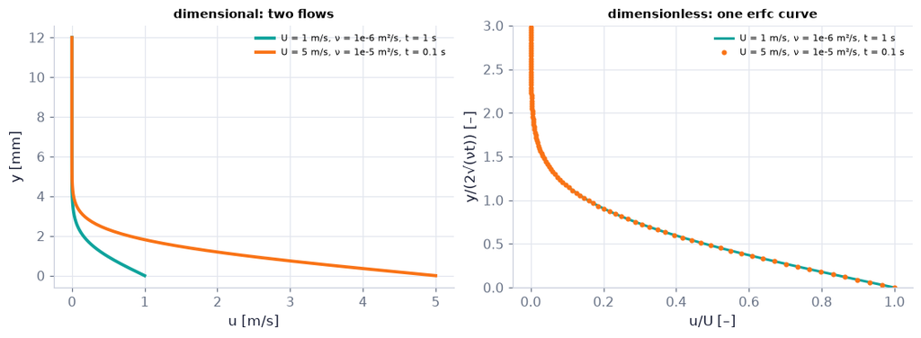

```python
yy = np.linspace(0, 12e-3, 200)                                      # height above the plate [m]
cases = [(1.0, 1e-6, 1.0, COLORS["teal"], "U = 1 m/s, ν = 1e-6 m²/s, t = 1 s"),                     # the cases to compare
         (5.0, 1e-5, 0.1, COLORS["orange"], "U = 5 m/s, ν = 1e-5 m²/s, t = 0.1 s")]
fig, (a, b) = plt.subplots(1, 2, figsize=(10, 3.6))                                        # the figure and its panels
for U, nu, t, col, lab in cases:                                     # two dimensional Stokes layers
    u = ch04.stokes_first_problem(yy, t, U=U, nu=nu)                                        # call the tested chapter function
    a.plot(u, yy*1e3, color=col, lw=2.5, label=lab)                  # different curves
    b.plot(u/U, yy/(2*np.sqrt(nu*t)), "o" if U > 1 else "-", color=col, ms=3, label=lab)   # the same curve
a.set_xlabel("u [m/s]"); a.set_ylabel("y [mm]"); a.legend(fontsize=7); a.set_title("dimensional: two flows", fontsize=10)  # axis labels with units
b.set_xlabel("u/U [–]"); b.set_ylabel("y/(2√(νt)) [–]"); b.set_ylim(0, 3); b.legend(fontsize=7)     # axis labels with units
b.set_title("dimensionless: one erfc curve", fontsize=10)                                        # the panel's message
savefig(fig, "ch04", "stokes_collapse"); plt.show()                                        # save the PNG to outputs/ch04, then draw
```

**What you see.** Two different curves on the left, one curve on the right (dots on the line).

**How to read it.** After scaling, the equation has no parameters left, so every Stokes layer is the same curve u/U = erfc(y/2√(νt)).

**What would change if…** …a plate oscillating instead of started: a new group (Ωl²/ν) appears and the collapse needs it to match too.

```python
Re_axis = np.logspace(-1, 6, 200)                                    # Reynolds numbers
CD_curve = ch04.sphere_drag_coefficient(Re_axis)                     # Morrison (2013) correlation
def point(logRe):                                                    # the slider picks log10(Re)
    Re = 10**logRe  # the slider's Reynolds number
    return {"C_D(Re), Morrison 2013": (np.log10(Re_axis), np.log10(CD_curve)),                      # the curves for this slider value
            "Stokes 24/Re": (np.log10(Re_axis[Re_axis < 10]), np.log10(24/Re_axis[Re_axis < 10])),  # another named curve (x, y)
            "this Re": ([logRe], [np.log10(ch04.sphere_drag_coefficient(Re))])}                     # another named curve (x, y)
fig = slider_figure(point, "log10 Re", np.linspace(-1, 6, 36 if not FAST else 18), xlabel="log10 Re [–]", ylabel="log10 C_D [–]",  # precompute every slider position (works on the web page)
                    title="One curve for every sphere: C_D depends on Re alone", modes={"this Re": "markers"})  # labels, title and a fixed range
recolor(fig, {"C_D(Re), Morrison 2013": COLORS["ink"], "Stokes 24/Re": COLORS["muted"], "this Re": COLORS["rose"]},  # house colours for each trace, then draw
        {"Stokes 24/Re": "dash"}).show()                                        # dashed reference line
```

[interactive chart not shown]

**What you see.** A black curve falling steeply (on the grey Stokes line) at small Re, flattening near C_D ≈ 0.4, then dropping sharply near Re ≈ 3×10⁵; the rose point rides on it.

**How to read it.** At the slider's Re the point shows C_D; any sphere, any fluid, any speed with that Re sits on it.

**What would change if…** …a rough sphere: the drag crisis moves to lower Re (a new group, roughness/d, enters).

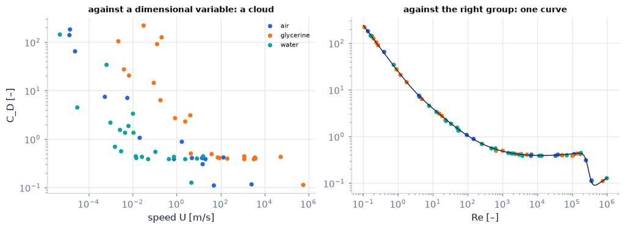

```python
d = ch04.synthetic_sphere_drag_data(60, seed=0, noise=0.03)          # 60 "experiments": fluid, d, U, ρ, μ, F, Re, C_D (3 % noise)
fig, (a, b) = plt.subplots(1, 2, figsize=(10, 3.6))                                        # the figure and its panels
cols = {f: c for f, c in zip(sorted(set(d["fluid"])), (COLORS["blue"], COLORS["orange"], COLORS["teal"], COLORS["accent"]))}  # one colour / label per series
for f in cols:                                                       # one colour per fluid
    m = np.array(d["fluid"]) == f  # the experiments done in this fluid
    a.loglog(np.asarray(d["U"])[m], np.asarray(d["CD"])[m], "o", color=cols[f], ms=4, label=f)      # draw the data
    b.loglog(np.asarray(d["Re"])[m], np.asarray(d["CD"])[m], "o", color=cols[f], ms=4)              # draw the data
Rg = np.logspace(-1, 6, 300); b.loglog(Rg, ch04.sphere_drag_coefficient(Rg), color=COLORS["ink"], lw=1)  # the Morrison curve for reference
a.set_xlabel("speed U [m/s]"); a.set_ylabel("C_D [–]"); a.legend(fontsize=7); a.set_title("against a dimensional variable: a cloud", fontsize=10)  # axis labels with units
b.set_xlabel("Re [–]"); b.set_title("against the right group: one curve", fontsize=10)              # axis labels with units
savefig(fig, "ch04", "drag_collapse"); plt.show()                                        # save the PNG to outputs/ch04, then draw
```

**What you see.** Chaos on the left, order on the right.

**How to read it.** Plotting against the right group removes the dimensional scatter — that is dynamic similarity measured.

**What would change if…** …plotting against d alone: still a cloud; only the combination ρUd/μ collapses the data.

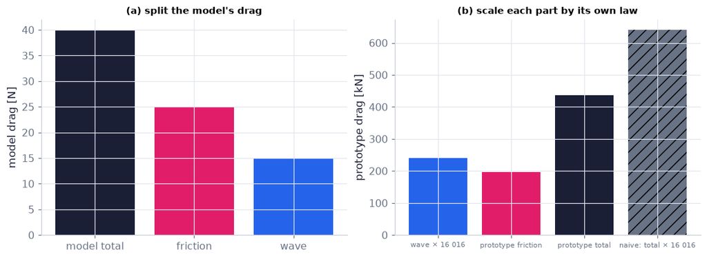

```python
sd = ch04.ship_drag_extrapolation(100.0, 10.0, 2500.0, 1/25, 40.0, 0.00312, 0.00153)   # Froude's method, our numbers [N]
fig, (a, b) = plt.subplots(1, 2, figsize=(10, 3.6))                                        # the figure and its panels
a.bar(["model total", "friction", "wave"], [40.0, sd["D_m_friction"], sd["D_m_wave"]],              # draw the data
      color=[COLORS["ink"], COLORS["rose"], COLORS["blue"]])         # the model's drag split
a.set_ylabel("model drag [N]"); a.set_title("(a) split the model's drag", fontsize=10)              # axis labels with units
b.bar(["wave × 16 016", "prototype friction", "prototype total", "naive: total × 16 016"],          # draw the data
      np.array([sd["D_p_wave"], sd["D_p_friction"], sd["D_p_total"], sd["D_p_uncorrected"]])/1e3,  # prototype drag parts [kN]
      color=[COLORS["blue"], COLORS["rose"], COLORS["ink"], COLORS["muted"]], hatch=["", "", "", "//"])  # the naive bar hatched
b.set_ylabel("prototype drag [kN]"); b.tick_params(axis="x", labelsize=7); b.set_title("(b) scale each part by its own law", fontsize=10)  # axis labels with units
savefig(fig, "ch04", "ship_drag"); plt.show()                                        # save the PNG to outputs/ch04, then draw
```

**What you see.** The corrected prototype total (437 kN) much shorter than the naive grey bar (641 kN).

**How to read it.** Friction scales with Re, waves with Fr; the model cannot match both, so each part is scaled by its own law.

**What would change if…** …a model in a fluid of much lower ν (none practical exists): both Fr and Re could match — the reason towing tanks live with the correction.

#### 🎮 Interactive: When does a model behave like the real thing?

**Why interactive rather than a static figure:** similarity is about matching groups between two flows; changing scale, speed and fluid lets you watch which badges turn green and which cannot, and the data collapse only when the axis is the right group.

A prototype and a model side by side, the groups of $\big[\frac{\Omega l}{U}\big]\frac{\partial\mathbf u^*}{\partial t^*}+(\mathbf u^*\cdot\nabla^*)\mathbf u^*=-\nabla^*p^*+\big[\frac{gl}{U^2}\big]\mathbf g^*+\big[\frac{\mu}{\rho Ul}\big]\nabla^{*2}\mathbf u^*$ (4.101) as paired bars with "matched" badges, and the consequences: sphere data collapsing on C_D(Re), a ship's drag split and scaled. Modes: sphere, ship, stratified flow (Fr′, Ri), rotating tank (Rossby number U/(2Ωl), the advective term U²/l over the Coriolis term 2ΩU of (4.45), $\rho\frac{D'\mathbf u'}{Dt}=-\nabla'p+\rho\Big[\mathbf g-\frac{d\mathbf U}{dt}-2\boldsymbol\Omega\times\mathbf u'-\frac{d\boldsymbol\Omega}{dt}\times\mathbf x'-\boldsymbol\Omega\times(\boldsymbol\Omega\times\mathbf x')\Big]+\mu\nabla'^2\mathbf u'$ — a forward pointer to Ch. 13).

**What to try:**

- Ship preset 1:25: match Fr and read the Re mismatch ×125 in Explain.
- Sphere mode: toggle the axes from dimensional to Re — the points collapse.
- Try to match Re too by changing the model fluid: which fluid would you need?
- Rotating-tank mode: match the Rossby number U/(2Ωl) of an atmospheric system in a 1-m tank.

```python
show_viz("ch04", "dynamic_similarity_models")   # full-width explainer; ⤢ Full screen for more room
```

🎮 Interactive 9/9 When does a model behave like the real thing? Open alone ↗

[interactive chart not shown]

**What would change if…** …the flow had rotation and stratification together, as the ocean and atmosphere do? Two more groups join — the Rossby number U/(2Ωl), from the Coriolis term −2Ω × u′ of (4.45), $\rho\frac{D'\mathbf u'}{Dt}=-\nabla'p+\rho[\mathbf g-2\boldsymbol\Omega\times\mathbf u'-\dots]+\mu\nabla'^2\mathbf u'$, and the Richardson number above — and the regime map of Ch. 13 is drawn in their plane.

*↪ S01 · Exercises: the book's Exercises 4.1–4.63 are for practice. The derivations the text defers to Exercises 4.7, 4.8, 4.30, 4.38, 4.42, 4.43, 4.45, 4.46, 4.47 and 4.50 are written out above in our own words (D04, D08, D13, D15, D18, D20, D21, D23, D24).*

*↪ S02 · Literature: the chapter's references — Aris (isotropic tensors, used in C07), Batchelor and Lamb (classical treatments), Spiegel & Veronis (the Boussinesq approximation, C13) — are listed at the end of the book's chapter.*

## ✅ What should have clicked

- **C01** A box of any shape and motion keeps a mass budget: $\frac{d}{dt}\int_{V^*}\rho\,dV+\int_{A^*}\rho(\mathbf u-\mathbf b)\cdot\mathbf n\,dA=0$ *(4.5)* — flux counts relative to the walls.
- **C02** At a point, $\frac{\partial\rho}{\partial t}+\nabla\cdot(\rho\mathbf u)=0$ *(4.7)*; incompressible means each particle keeps its density, so $\nabla\cdot\mathbf u=0$ *(4.10)*.
- **C03** In 2-D one scalar ψ carries the flow: $u=\partial\psi/\partial y$, $v=-\partial\psi/\partial x$; contours are streamlines and Δψ is the flux between them.
- **C04** Forces follow from fluxes: $\frac{d}{dt}\int_{V^*}\rho\mathbf u\,dV+\int_{A^*}\rho\mathbf u(\mathbf u-\mathbf b)\cdot\mathbf n\,dA=\int_{V^*}\rho\mathbf g\,dV+\int_{A^*}\mathbf f\,dA$ *(4.17)* weighs the drag on a bar from its wake.
- **C05** Along one streamline of a steady, frictionless, constant-density flow $\tfrac12U^2+gz+p/\rho$ is constant (4.19), $\tfrac12U^2+gz+p/\rho=\text{const along a streamline}$.
- **C06** Newton for every continuum: $\rho\frac{Du_j}{Dt}=\rho g_j+\frac{\partial\tau_{ij}}{\partial x_i}$ *(4.24)*, stress divergence over the first index.
- **C07** A Newtonian fluid feels only its strain rate: $\tau_{ij}=-p\delta_{ij}+2\mu S_{ij}+\lambda S_{mm}\delta_{ij}$ *(4.31)*, two constants.
- **C08** $\rho\frac{D\mathbf u}{Dt}=-\nabla p+\rho\mathbf g+\mu\nabla^2\mathbf u$ *(4.39b)* is a budget of five accelerations; each flow wakes only some of them.
- **C09** A rotating observer adds $-2\boldsymbol\Omega\times\mathbf u'$ (Coriolis) and $-\boldsymbol\Omega\times(\boldsymbol\Omega\times\mathbf x')$ (centrifugal) to the forces of (4.45), $\rho\frac{D'\mathbf u'}{Dt}=-\nabla'p+\rho\Big[\mathbf g-\frac{d\mathbf U}{dt}-2\boldsymbol\Omega\times\mathbf u'-\frac{d\boldsymbol\Omega}{dt}\times\mathbf x'-\boldsymbol\Omega\times(\boldsymbol\Omega\times\mathbf x')\Big]+\mu\nabla'^2\mathbf u'$; the ball flies straight, the floor turns.
- **C10** Viscosity turns kinetic energy into heat at the rate $\varepsilon=2\nu(S_{ij}-\tfrac13S_{mm}\delta_{ij})^2+\frac{\mu_v}\rho S_{mm}^2\ge0$ *(4.58)*, a sum of squares — never the reverse.
- **C11** Steady inviscid barotropic flow keeps $B=\tfrac12u^2+\int dp/\rho+gz$ constant along streamlines and vortex lines (4.71), $\tfrac12u_i^2+\int_{p_o}^{p}\frac{dp'}{\rho(p')}+gz=\text{const along streamlines and vortex lines}$, everywhere if irrotational (4.72), $\tfrac12u_i^2+\int_{p_o}^{p}\frac{dp'}{\rho(p')}+gz=\text{const everywhere}$.
- **C12** Irrotational unsteady flow obeys $\frac{\partial\phi}{\partial t}+\tfrac12\lvert\nabla\phi\rvert^2+\int\frac{dp}{\rho}+gz=$ const *(4.75)*: accelerating fluid needs pressure even at rest.
- **C13** Boussinesq keeps density only where it meets gravity: $\frac{D\mathbf u}{Dt}=-\frac1{\rho_0}\nabla p'+\frac{\rho'}{\rho_0}\mathbf g+\nu\nabla^2\mathbf u$ *(4.86)* and $\frac{DT}{Dt}=\kappa\nabla^2T$ *(4.89)*.
- **C14** A surface made of fluid moves with it: $D\eta/Dt=0$ on η = 0 (4.91), $\frac{\partial\eta}{\partial t}+(\mathbf u\cdot\nabla)\eta\equiv\frac{D\eta}{Dt}=0\ \text{on}\ \eta=0$; fluxes are continuous across interfaces; walls impose no-slip.
- **C15** Scaled, Navier–Stokes keeps St, Fr, Re (4.101), $\Big[\frac{\Omega l}{U}\Big]\frac{\partial\mathbf u^*}{\partial t^*}+(\mathbf u^*\cdot\nabla^*)\mathbf u^*=-\nabla^*p^*+\Big[\frac{gl}{U^2}\Big]\mathbf g^*+\Big[\frac{\mu}{\rho Ul}\Big]\nabla^{*2}\mathbf u^*$; equal groups make a model the real thing.

**What later chapters build on**

- Ch. 5: the vorticity equation from the Lamb identity $u_i\partial u_j/\partial x_i=-(\mathbf u\times\boldsymbol\omega)_j+\partial(\tfrac12u_i^2)/\partial x_j$ *(4.68)* and (4.39b).
- Ch. 6: potential flow with B constant everywhere *(4.72)* and unsteady Bernoulli (4.75), $\frac{\partial\phi}{\partial t}+\tfrac12\lvert\nabla\phi\rvert^2+\int_{p_o}^{p}\frac{dp'}{\rho(p')}+gz=\text{const}$.
- Ch. 7: free-surface conditions — $\frac{\partial\phi}{\partial t}+\tfrac12\lvert\nabla\phi\rvert^2+gz+p/\rho=$ const *(4.75)* and $D\eta/Dt=0$ *(4.91)*.
- Ch. 8: exact solutions checked term by term with `core.navier_stokes`.
- Ch. 9: the momentum integral from the box budget *(4.17)*.
- Ch. 10: conservative forms — the flux form (4.22), $\frac{\partial}{\partial t}(\rho u_j)+\frac{\partial}{\partial x_i}(\rho u_iu_j)=\rho g_j+\frac{\partial\tau_{ij}}{\partial x_i}$ and the total-energy equation (4.53), $\frac{\partial}{\partial t}\big(\rho\big[e+\tfrac12u_j^2\big]\big)+\frac{\partial}{\partial x_i}\big(\rho\big[e+\tfrac12u_j^2\big]u_i\big)=\rho g_iu_i+\frac{\partial}{\partial x_i}(\tau_{ij}u_j)-\frac{\partial q_i}{\partial x_i}$.
- Ch. 11: Boussinesq instabilities and the Richardson number.
- Ch. 12: ε and the kinetic-energy budget (the force-work/deformation-work split of (4.54), $\frac{\partial(\tau_{ij}u_j)}{\partial x_i}=\Big(-p\frac{\partial u_j}{\partial x_j}+\sigma_{ij}\frac{\partial u_j}{\partial x_i}\Big)+\Big(-u_j\frac{\partial p}{\partial x_j}+u_j\frac{\partial\sigma_{ij}}{\partial x_i}\Big)$).
- Ch. 13: Navier–Stokes in a rotating frame *(4.45)* with Boussinesq, Ro and Ri.
- Ch. 15: the energy equation and the Mach number.

**Not taught here (and where to find it)**

- Non-Newtonian fluids (Ch. 16).
- The proof of the isotropic-tensor form (cited, Aris).
- Kelvin's circulation theorem (Ch. 5).
- Marangoni flows (interfacial-flow texts).
- Anelastic equations for deep atmospheres (Ch. 13 texts).

← All chapters

← PreviousNext →

Code and explanations: shammun/fluidpy (MIT). The book is not reproduced here; equations are cited by number.